# 智能制造系统设计 · 第 5 讲：成本管理与人力资源

刘训臣

山东科技大学 机械电子工程学院

# 第〇部分 · 课程介绍与本讲定位

- 成本管理与人力资源：本讲 90 分钟、四个内容块
- 一条主线：**成本怎么算 → 投资怎么评 → 设计怎么省 → 人怎么配**
- 成本回答“这套方案划不划算”，人力回答“谁来干、怎么激励”；落点：成本与安全的取舍、分配公平
- 工具：制造费用分配、量本利分析、作业成本法（ABC）、投资回收期、净现值（NPV）、内部收益率（IRR）、质量成本与全生命周期成本（LCC）
- **承上**：第 4 讲把安全与环境讲成两条不能省的约束；本部分要回答第 5 讲讲什么、怎么安排、怎么考。

## 第 5 讲：教学内容与主线（内容块 1–2）

> 上一页给出本讲主线；这一页展开前两块：成本由什么构成、怎么分析。

**内容块 1 · 成本管理概述**

- 成本管理是智能制造系统的**目标函数**，成本按直接与间接、固定与变动两对口径分类
- 产品成本拆成料工费，制造费用按受益原则分配
- 公司类型决定责任边界（有限责任／无限责任），财务三张报表给出关键指标
- 毛利率与材料毛利率做比较，成本管理流程与全员成本意识管落地

**内容块 2 · 成本指标与分析工具**

- 标准成本法用标准与实际比出差额，**ABC 成本法**（作业成本法）按作业归集成本
- **量本利分析**算边际贡献、盈亏平衡点、目标利润与安全边际
- 库存周转率与资金周转率衡量资金占用效率，制造费用先算预算再落到责任中心
- **成本驱动设计**用目标成本法从市场倒推，用价值工程守住功能与成本的比值

## 第 5 讲：教学内容与主线（内容块 3–4）

**内容块 3 · 技术经济评价**

- 资金有时间价值，**现金流量表**记现金流入 CI、流出 CO 与净现金流量
- **静态与动态投资回收期**都看回本快慢
- **净现值（NPV）**、净现值率、**内部收益率（IRR）**的关系与选用
- **质量成本**分预防、鉴定、内部损失、外部损失，**全生命周期成本（LCC）**管到底

**内容块 4 · 成本驱动的设计与人力资源**

- 成本在质量与安全之间找平衡，六条设计原则加目标成本分解
- 智能制造人才结构在变，岗位能力模型用**冰山模型**
- 人机协作带来替代、互补、创造三种影响
- 绩效考核（KPI／OKR／BSC／MBO）与激励理论，最后落到伦理

## 教学进度 · 10 次课全览

> 上一页讲完本讲的四块内容；这一页把本讲放进十次课的全景。

| 次 | 模块 | 主题 |
| --- | --- | --- |
| 1 | 导论与 3.1 | 课程导论、工程与社会与质量工程（一）：国家战略、工程的社会属性、质量管理基础 |
| 2 | 3.1 | 质量工程（二）与质量工具：五大工具 APQP／FMEA／MSA／SPC／PPAP、CPK、QC 七大手法 |
| 3 | 3.2 | 工业工程与精益生产（＋实验 2 课时：线性规划与工业工程例子） |
| 4 | 3.3、3.4 | 安全工程与环保工程：海因里希法则、事故树 FTA、风险评估、三废治理、双碳 |
| **5** | **3.5、3.6** | **成本管理与人力资源：成本构成、投资回收期、NPV／IRR、质量成本、人才与激励** |
| 6 | 4.1～4.3 | 企业信息系统（一）：ERP、MES、PLM 与系统集成全景 |
| 7 | 4、6 | 企业信息系统（二）与 8D：CRM／WMS／APS，8D 八步与软件开发流程 |
| 8 | 工程伦理（一） | 工程事故与伦理准则：凯悦酒店、NSPE 准则、伦理决策框架 |
| 9 | 工程伦理（二） | 风险、安全与责任，工程师与组织：责任判定、组织文化与信任 |
| 10 | 伦理（三）与综合 | 技术的社会意义、国际化、AI 伦理；智能设计应用、前沿、课程设计与总复习 |

**结论：本讲是第 5 次课，前面四讲给设计目标，后面五讲转向系统与责任。**

## 本讲在课程中的位置

**前三讲**分别给了三个视角：

- 第 2 讲：质量——把不良品消灭在过程中（质量成本由此而来）
- 第 3 讲：效率——工业工程（IE）与精益消除八大浪费（成本第一来源）
- 第 4 讲：底线——安全与环境不能省的投入（成本与安全的取舍）

**本讲**把它们统一到一张账上：

- 成本不是“财务部门的事”，而是**设计、工艺、采购、生产、服务全过程的结果**
- 技术方案的经济性 = 现金流量 + 时间价值 + 风险
- 人的安排（岗位、能力、激励）决定成本能否真正落地

> 一句话：**质量与效率创造价值，成本管理把价值留下来。**

## 成本与人在智能制造中的位置

> **成本是目标函数，人是执行主体：一个回答“划不划算”，一个回答“谁来干、愿不愿干”。**

| 维度 | 成本 | 人 |
| --- | --- | --- |
| 系统中的地位 | 目标函数，一切技术方案的可比尺度 | 执行主体，设计与运营都要靠人落地 |
| 智能化的改变 | 工时、能耗、质量数据在线，核算从事后转向事中 | 操作岗位减少，监控、维护、数据岗位增加 |
| 本讲工具 | 制造费用分配、量本利、回收期、NPV、LCC | 工作分析、冰山模型、KPI／OKR、激励理论 |
| 判断尺度 | 钱：可折现、可比较、可排序 | 能力与动机：可观察、难折算、难排序 |

- 两者在**设计阶段**交汇：设计锁定七成以上成本，也定下岗位与技能要求
- 一个提醒：数据让成本更透明，人的价值反而更难折算——第四部分的伦理落点由此而来
- 人的一面也有账：岗位结构变化带来转岗与再培训成本，这笔钱最常被漏算

**结论：成本可折算排序，人要靠观察与激励，两者在设计阶段交汇。**

## 本讲伦理与社会落点

> 上一页说人的价值难折算；这一页先挂出四个伦理落点。
- **落点一：成本与安全的取舍**——安全投入“算不过账”时，企业该如何决策？
- **落点二：人的价值能否折算为成本**——生命、健康、工伤赔偿，能不能、该不该标价？
- **落点三：分配公平**——自动化带来的收益，归资本、归企业，还是归被替代的工人？
- **落点四：绩效指标的伦理**——KPI 逼出来的数据造假与“算法压榨”

| 技术场景 | 伦理问题 | 讨论页 |
| --- | --- | --- |
| 机器人安全围栏投入 80 万元 | 安全投入的回收期与生命价值 | 第四部分 |
| 自动化产线减员 | 被替代工人的转岗与补偿 | 第四部分 |

**结论：四个落点分别指向安全投入、人的价值、分配公平与绩效伦理。**

## 本讲 90 分钟怎么安排

> 上一页挂出伦理落点；这一页给出 90 分钟的时间分配。

> **90 分钟 ＝ 6 分钟开场回顾 ＋ 22＋22＋18＋14 分钟讲授 ＋ 4 分钟讨论 ＋ 4 分钟收尾。**

| 序 | 时间块 | 讲什么 | 分钟 |
| --- | --- | --- | --- |
| 0 | 开场与第 4 讲回顾 | 六问、目标、真题、路线图 | 6 |
| 1 | 成本管理概述 | 公司类型与股权、三张表、料工费、制造费用分配 | 22 |
| 2 | 成本分析与量本利 | 标准成本与差异、ABC、成本性态、盈亏平衡、杠杆 | 22 |
| 3 | 技术经济评价 | 现金流量、回收期、NPV、IRR、质量成本、LCC | 18 |
| 4 | 人力资源 | 人才结构、工作分析、冰山模型、绩效与激励 | 14 |
| 5～6 | 讨论与小结 | 真题讲评、作业与下讲预告 | 4＋4 |

- 时间紧先压标准成本差异与折旧口径；**制造费用分配、盈亏平衡、静态回收期、股权九节点**不能压

**结论：四个讲授块共 76 分钟，成本与量本利的 44 分钟是手算重心。**

## 本讲学习目标与能力清单

> 上一页排好 90 分钟的时间；这一页把四条能力写成可验收的动作。

> **四条能力＝四个动作：算得出成本、算得准平衡点、评得清投资、说得明岗位。**

| 能力 | 具体要求 | 落点 | 验收标准（可检查） |
| --- | --- | --- | --- |
| 会算成本 | 成本分类、料工费、制造费用分配、三张表 | 第一部分 | 制造费用 120 万元、12000 工时 → 100 元／h，A 摊 80 万、B 摊 40 万 |
| 会做量本利 | 边际贡献、盈亏平衡、目标利润、经营杠杆 | 第二部分 | $F=200$ 万、$p=100$、$v=60$ → $Q_0=5$ 万件，$\mathrm{DOL}=3$ |
| 会评投资 | 现金流量、静／动态回收期、NPV、IRR | 第三部分 | 六卷真题表 → $P_t=5.33$ 年；1200／320 → 3.75 年 |
| 会做岗位分析 | 工作分析、冰山模型、绩效与激励 | 第四部分 | 写一份岗位说明书与能力项分级，说清 KPI 与 OKR 之别 |

- 三条靠算、一条靠写：会算成本、会做量本利、会评投资，岗位分析靠写清楚
- 验收标准一律写成能当场做出来的动作，不写“理解”“掌握”

**结论：四条能力＝四个动作，验收标准写成当场能做的动作。**

## 考试视角：本讲真题分布

> 上一页给出能力清单；这一页看考试怎么考、复习先抓什么。

> **六卷（2020—2022 级 A／B）都有：第六题静态投资回收期 10 分，选择题 3 分考公司责任形式。**

| 考点 | 题型 | 出现卷次 | 备考口径 |
| --- | --- | --- | --- |
| 静态投资回收期 | 第六题计算，10 分 | 六卷全有 | 累计转正处插值：$P_t=5.33$ 年 |
| 公司责任形式 | 选择题，3 分（第 6／7 题） | 六卷全有 | 无限责任＝个人独资企业 |
| 股权比例九节点 | 未单独命题 | 六卷均无 | 1、3、5、10、20、30、34、51、67 会背会判 |
| 成本分类与费用分配 | 未出题 | 六卷均无 | 会算分配率，懂“谁受益、谁承担” |
| 量本利与 NPV | 未出题 | 六卷均无 | 会算平衡点，会按 NPV 判可行 |

- 判分点：净现金流算对、转正年份找对、上年累计 ÷ 当年净流量
- 另一版累计表第 6～8 年每年流入 1200 万元，同法得 5.4 年，两版对照练
- 六卷未考的不等于不考：量本利、NPV、质量成本都在【重点与考点】内，简答、论述都可能用

**结论：回收期 10 分是必拿题，其余考点按简答与论述准备。**

## 本讲路线图与课前准备

> 上一页看完真题分布；这一页给出六个部分的路线图与课前准备。

> **主线：算成本 → 看盈亏 → 评投资 → 配人，从钱走到人。**

| 部分 | 入口问题 | 讲什么 | 出口 |
| --- | --- | --- | --- |
| 一 成本（22） | 成本由什么构成 | 公司类型、三张表、料工费 | 成本算得出 |
| 二 分析（22） | 成本为什么变 | 标准成本、ABC、盈亏平衡 | 平衡点算得准 |
| 三 评价（18） | 投资值不值 | 现金流量、回收期、NPV、IRR | 方案选得对 |
| 四 人力（14） | 谁来干、怎么激励 | 人才结构、工作分析、绩效激励 | 岗位说得清 |
| 五 例题（4） | 会不会用 | 真题回收期、股权节点、质量成本 | 题做得完 |
| 六 小结（4） | 记住什么 | 公式一页纸、作业、第 6 讲预告 | 复习有抓手 |

- 开场 6 分钟：时间表、六问、四条能力、真题分布、本路线图
- 课前准备：计算器与 A4 纸，预习现金流量、折现与回收期
- 本讲无实验课时；练习放在第五部分的例题与课后作业中

## 第 4 讲回顾与检查：六个问题

> 上一页给出本讲的路线图；这一页用六问检查第 4 讲的地基。

> **1 分钟开场、5 分钟六问：答不出的那一条，就是今天要补的地基。**

| 问题 | 一句话答案 | 今天怎么用 |
| --- | --- | --- |
| ① 事故致因 | 因果连锁、能量意外释放、轨迹交叉；3E 以工程手段优先 | 安全投入是“断链”，也要算回收期 |
| ② 最小割集 | 顶上事件的**最低限度**组合，布尔化简可求 | 预算有限先切低阶割集，边际效益最高 |
| ③ 事故树 | 与门乘、或门加，$A+AB=A$ 化简；六卷第四题 | 成本也按树分解：料、工、费逐层摊 |
| ④ 双重预防 | 风险分级管控 $R=LS$ ＋ 隐患排查治理 | 投资风险也分级，按敏感性排序 |
| ⑤ 三废 | 废气选工艺、废水三级、固废三化 | 治理成本进产品成本，外部成本内部化 |
| ⑥ 碳核算 | 排放量＝活动数据×排放因子；范围一、二、三 | 碳成本＝碳价×排放量，进 LCC |

- 六问分三类：①②③ 是理论与方法，④ 是制度机制，⑤⑥ 是环境账；今天把“代价”换成“钱”
- 抽查：随机点两人各答一问；答不出不扣分，课后补，课前再问

## 产教融合 · 本讲企业真题：智能检测线 80 万元投资：NPV 134.7 万元

> **企业场景：**企业拟上智能检测线，投资 80 万元、年净节约 32 万元、折旧 10 年、折现率 8%；现人工目检漏检率约 4%。

| 企业真实问题 | 本讲工具 | 学生产出 |
| --- | --- | --- |
| 人工目检漏检与节拍不达标，但投资回收与质量损失未算清 | 静态/动态回收期、NPV、IRR、敏感性分析 | 人工目检与机器视觉检测比选报告（作业 4） |

# 第一部分 · 成本管理概述

- 成本管理是智能制造系统的目标函数
- 成本构成分直接与间接、固定与变动、生产成本与期间费用三组口径；产品成本落到料工费，制造费用有六种分配方法
- 公司类型与责任形式决定融资成本与风险溢价；财务三张表给出资产、利润与现金流的坐标系
- 本部分落点是：把“成本”拆成可以管得住的块
- **承上**：第〇部分交代了本讲的四个内容块与课程位置；本部分转入第一块，先把成本从财务语言翻译成可归集、可考核的块。

## 成本管理：智能制造的目标函数

> 第〇部分把本讲定位在“成本—投资—设计—人”的主线上；这一页先回答成本管理究竟是什么。
- **是什么**：把成本算清、算准、算到人的一套闭环行为——核算、决策、控制、评价，缺一件就只是记账
- **为什么**：质量、效率、安全的改进最终都要换算成成本优势，否则企业没有持续投入的动力
- **怎么判断**：三问过关才算管住——能否归集到产品或工序、能否解释差异、能否落到岗位与人

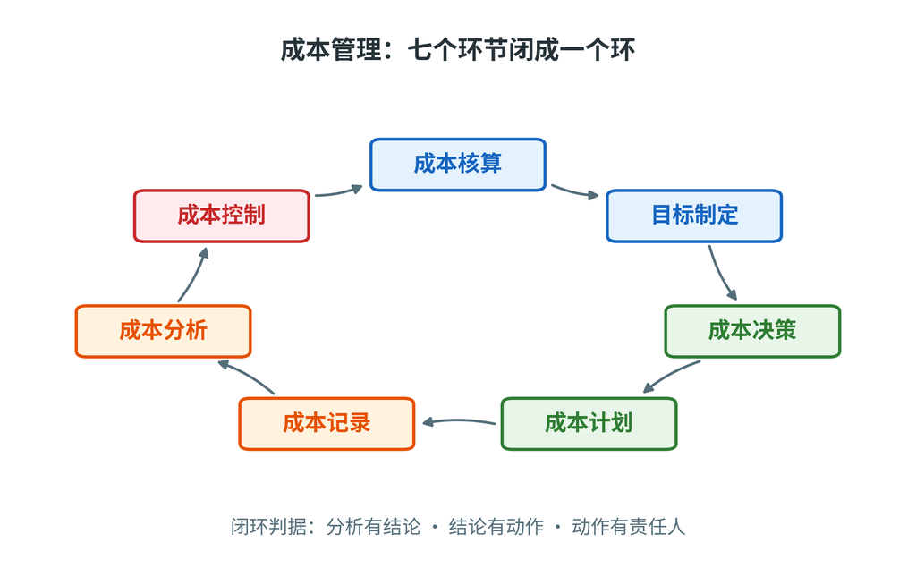

- 七环节闭环：核算→目标→决策→计划→记录→分析→控制；关键是**指标分解**（到部门与岗位）与**考核挂钩**
- 智能制造的贡献在“事中”：工时、能耗、质量、库存实时进账，核算从月底推到当班

**结论：成本不是财务部门算出来的结果，而是工程师在设计阶段就要背上的约束。**

## 财务管理的三个问题：筹资、投资、分配

> 上一页讲成本管理是目标函数；这一页先立财务坐标系，把企业财务活动归为三个决策。
- 企业财务活动围绕三个决策：钱从哪来、投到哪去、收益怎么分
- 筹资决策：股权还是债权；资本结构与资本成本决定折现率
- 投资决策：项目、营运资金、并购；判据是净现值（NPV，net present value，单位元或万元）与内部收益率（IRR，internal rate of return，单位 %）
- 分配决策：股利与留存收益；留存多则再投资能力强，股东当期回报少
- 三个问题共用一把尺子：资金的机会成本
- 财务管理目标：企业价值最大化，而不是当期利润最大化
- 与成本管理的接口：资金成本进折现率，成本预测进现金流

| 问题 | 核心决策 | 对成本管理的影响 |
| --- | --- | --- |
| 钱从哪来 | 股权融资与债权融资的比例 | 利息与股东要求回报进入资本成本 |
| 投到哪去 | 项目取舍与投资时机 | 折旧、维护、能耗锁定多年成本 |
| 怎么分 | 股利政策与留存比例 | 留存不足则技改靠借款 |

**结论：财务三问给成本管理提供三个时间尺度——投资锁定长期成本，筹资决定资金成本，分配决定再投资能力。**

## 会计六要素与两个恒等式

> 上一页立了财务三问；这一页给出记账的骨架，即六要素与两个恒等式。
- 六要素分两组：存量三要素与流量三要素
- 存量：资产、负债、所有者权益，回答“有多少家底、欠多少债”
- 流量：收入、费用、利润，回答“一段时间赚了多少”
- 会计恒等式：$A=L+E$，$A$ 为资产（万元）、$L$ 为负债（万元）、$E$ 为所有者权益（万元）
- 第二恒等式：$R-C=P$，$R$ 为收入（万元）、$C$ 为费用（万元）、$P$ 为利润（万元）
- 扩展式：$A=L+E+(R-C)$，只在期末结账前成立
- 算例：资产 1000 万元、负债 600 万元 → 权益 400 万元
- 本期收入 500 万元、费用 420 万元 → 利润 80 万元 → 期末权益 480 万元
- 判读：每笔业务至少影响两个要素，恒等式始终平衡

**结论：恒等式是最硬的约束，利润最终进入所有者权益。**

## 财务三张表与关键指标

> 上一页讲六要素的恒等式；这一页把它落到三张报表与关键指标。

**三张表各回答一个问题**

| 报表 | 回答的问题 | 关键项 |
| --- | --- | --- |
| 资产负债表 | 某一时点“有多少家底、欠多少债” | 资产、负债、所有者权益 |
| 利润表 | 一段时间“赚了多少” | 收入、成本、费用、利润 |
| 现金流量表 | 一段时间“钱从哪来、到哪去” | 经营、投资、筹资现金流 |

**关键指标**

- 资产负债率 $=\dfrac{\text{负债总额}}{\text{资产总额}}\times100\%$（%）；经营者一般认为 **0.5～0.8** 合适，债权人希望越低越好
- 流动比率 $=\dfrac{\text{流动资产}}{\text{流动负债}}$（倍），约 **2** 较合理
- 速动比率 $=\dfrac{\text{流动资产}-\text{存货}}{\text{流动负债}}$（倍），约 **1** 较合理
- 三表勾稽：净利润转入未分配利润；期末现金＝资产负债表货币资金；勾稽对不上是最快的查账入口

**结论：三张表合起来才是一张完整体检单，投资决策看现金流，不看账面利润。**

## 毛利率与材料毛利率

> 上一页给出三张表；这一页算两个毛利率，看钱在哪个环节被赚走。

公式

$$毛利率=\frac{含税售价-含税进价}{含税售价}\times100\%$$

$$材料毛利率=\frac{不含税出厂价-不含税材料成本}{不含税出厂价}\times100\%$$

**算例（含税口径）**：某商品不含税进价 5.4 元，含税售价 6.9 元，增值税率 13%（一般货物现行税率）。

- 含税进价 $=5.4\times(1+13\%)=6.102$ 元
- 毛利率 $=(6.9-6.102)/6.9\times100\%=11.57\%$

**材料毛利率的意义**

- 摈弃制造因素，只比较**设计、采购与销售**三个环节
- 提高途径：优化设计（减少材料用量）、降低采购价、减少材料浪费
- 用途：判断一个产品“值不值得做”，是成本驱动设计的入口指标

**结论：看设计看材料毛利率，看经营看净利率——两个毛利率各有分工。**

## 公司类型与责任：有限责任与无限责任

> 上一页算完毛利率；这一页讲企业的法定形态与责任边界，责任形式决定风险谁来兜。
- 我国企业的法定基本形态分三类：独资企业、合伙企业、公司

| 类型 | 责任形式 | 关键点 |
| --- | --- | --- |
| 有限责任公司 | 股东以**认缴出资额**为限承担有限责任 | 最常见；一人有限公司财产混同则承担无限连带责任 |
| 股份有限公司 | 股东以**认购股份**为限承担有限责任 | 可上市融资 |
| 个人独资企业 | 投资人以个人财产承担**无限责任** | 融资难、风险大 |
| 普通合伙企业 | 合伙人对企业债务承担**无限连带责任** | 信任成本低、风险高 |
| 有限合伙企业 | 普通合伙人无限、有限合伙人以出资为限 | 创投常用 |
| 个体工商户 | 无限连带责任 | 规模小、灵活 |

- 选择逻辑：有限责任降低股东风险，但提高交易对方的信任成本；无限责任反之

**结论：责任形式是一笔要算进成本的风险价格，选公司类型就是选谁来承担失败。**

## 股权比例：九个关键权利节点

> 上一页讲责任形式；这一页把“有限责任”落到控制权，看九个关键比例。
- 1%：股份有限公司股东可提起股东代表诉讼（代位诉讼）
- 3%：可向股东大会提出临时提案
- 5%：持股变动达 5% 须公告，即“举牌线”
- 10%：可请求召开临时股东会
- 20%：重大同业竞争与权益变动披露节点，可提名董事
- 30%：继续增持须发出收购要约
- 34%：能否决需 2/3 表决的特别决议——“一票否决”，国企分界点
- 51%：相对控制；67%：绝对控制（修改章程、增资减资、合并分立）
- 判据：34% 一票否决、51% 相对控制、67% 绝对控制——谈判先看落在哪一档

**结论：股权比例不是数字游戏，而是控制权与风险分配的价格。**

## 成本与费用：对象化与期间化

> 上一页讲控制权；这一页回到成本本身，先分清支出、费用、成本三层。
- 支出：一切资金流出，先分资本化与费用化
- 费用：日常活动中的经济利益流出，分为生产费用与期间费用
- 成本：生产费用按产品对象归集的结果，可存货化
- 流转：生产费用 → 产品成本 → 营业成本（销售时）
- 期间费用：销售、管理、财务费用，当期直接进利润表
- 判据：能否计入存货、是否与产品形成直接相关

| 维度 | 成本 | 费用 | 典型例子 |
| --- | --- | --- | --- |
| 归集对象 | 特定产品 | 会计期间 | 直接材料与销售佣金 |
| 确认时点 | 随销售结转 | 当期损益 | 库存商品与广告费 |
| 报表位置 | 营业成本 | 期间费用 | 毛利之前与之后 |

**结论：对象化进来的是成本，期间化出去的是费用——这条线决定了毛利怎么算。**

## 成本的三种分类与管理用途

> 上一页分清成本与费用；这一页给出三个观察角度，同一笔支出可以有三个身份。

| 分类标志 | 类别 | 管理用途 |
| --- | --- | --- |
| 经济用途 | 生产成本（料、工、费） | 编产品成本表、算毛利 |
| 经济用途 | 期间费用（销售、管理、财务） | 预算控制、费用考核 |
| 性态 | 固定成本 | 提高产能利用率来摊薄 |
| 性态 | 变动成本 | 降单耗、降采购单价 |
| 归属 | 直接成本 | 直接计入产品 |
| 归属 | 间接成本 | 选择动因分配 |

- 混合成本单列：半变动成本、阶梯成本，需分解后才能用于量本利
- 三种分类不互斥：一件产品的钢材既是直接成本、变动成本，也是生产成本
- 同一项支出可有三种身份：车间设备折旧是间接成本、固定成本、生产成本
- 分类服从目的：要定价按完全成本，要决策按变动成本

**结论：三个分类不是三套账，而是同一笔支出在三个问题下的三种说法。**

## 产品成本的三项构成与成本流转

> 上一页讲三种分类；这一页把视角收窄到产品成本，讲清料工费与成本怎么流转。
- 产品成本由三项构成：直接材料、直接人工、制造费用，简称“料工费”
- 直接材料：构成产品实体、能直接计入某产品
- 直接人工：直接从事产品生产人员的薪酬
- 制造费用：车间间接费用，按动因分配计入
- 不进产品成本的：期间费用、非正常损耗、罚款与捐赠
- 流转算例：期初在产品 40 + 本期生产费用 500 − 期末在产品 60 = 完工产品成本 480 万元
- 完工产品成本 480 + 期初库存 30 − 期末库存 50 = 营业成本 460 万元
- 判据：成本流转表是编报表、算毛利、做定价的共同基础

**结论：料工费决定成本归到哪，流转决定成本在哪一期进利润表——两者合成成本流转表。**

## 制造费用：构成与分配

> 上一页讲完产品成本的三项构成；这一页专讲其中最难分的制造费用。
- 制造费用：企业为生产产品和提供劳务而发生的**间接成本**
- 四类构成：

| 构成 | 内容 |
| --- | --- |
| 间接材料费 | 润滑油、修理备件等非产品本身耗用的材料 |
| 间接人工费 | 修理工人工资、管理人员工资等 |
| 折旧费 | 固定资产自然磨损与时间损耗的分摊 |
| 其他支出 | 水电、差旅、运输、办公、设计制图、劳动安全保护 |

- 六种分配方法：生产工人工时比例法、生产工人工资比例法、机器工时比例法、耗用原材料数量或成本比例法、直接成本比例法、产成品产量比例法
- 选择原则：**谁受益、谁承担；受益多少、承担多少**（成本动因）
- 分配率＝制造费用总额÷分配标准总量（元／小时或元／件）；某产品应分摊额＝该产品分配标准×分配率

**算例**：制造费用 120 万元，A 产品 8000 工时、B 产品 4000 工时 → 分配率 $1200000/12000=100$ 元／h → A 分摊 80 万元、B 分摊 40 万元。

**结论：分配标准离真实成本动因越近，制造费用分得越准，成本信息才可用于决策。**

## 代码复算（一）：成本流转与制造费用分配

> 前面两张手算过成本流转与分配率；这一页把同一笔账交给代码，看能不能一分不差地对上。

```python
# 成本流转：期初在产品 + 本期生产 - 期末在产品 = 完工产品成本
wip0, produced, wip1 = 40, 500, 60
finished = wip0 + produced - wip1
cogs = finished + 30 - 50          # 加期初库存 30、减期末库存 50
print("完工产品成本", finished, "营业成本", cogs)

# 制造费用分配：120 万元按 12000 工时
oh, h_a, h_b = 1_200_000, 8000, 4000
rate = oh / (h_a + h_b)
print("分配率", rate, "元/h  A 摊", h_a*rate/1e4, "万元  B 摊", h_b*rate/1e4, "万元")
```

```
完工产品成本 480 营业成本 460
分配率 100.0 元/h  A 摊 80.0 万元  B 摊 40.0 万元
```

- 前两行复现手工账：$40+500-60=480$、$480+30-50=460$ 万元
- 后两行复现分配率：$1200000\div12000=100$ 元/h，A $8000\times100=80$ 万元、B $4000\times100=40$ 万元
- 代码的好处是改一个数就重算全链：把期末在产品从 60 改成 80，完工与营业成本会同步变

**结论：手工账与代码必须对上——对不上，先怀疑口径（单位、期初期末、万元与元），再怀疑算术。**

## 成本性态：固定成本与变动成本

- **是什么**：成本总额随业务量变化的规律——固定、变动、混合成本三类
- **为什么**：降本手段由性态决定——固定靠产能利用率摊薄，变动靠单耗与单价
- **怎么判断**：看单位额——单位固定成本随产量下降，单位变动成本基本不变

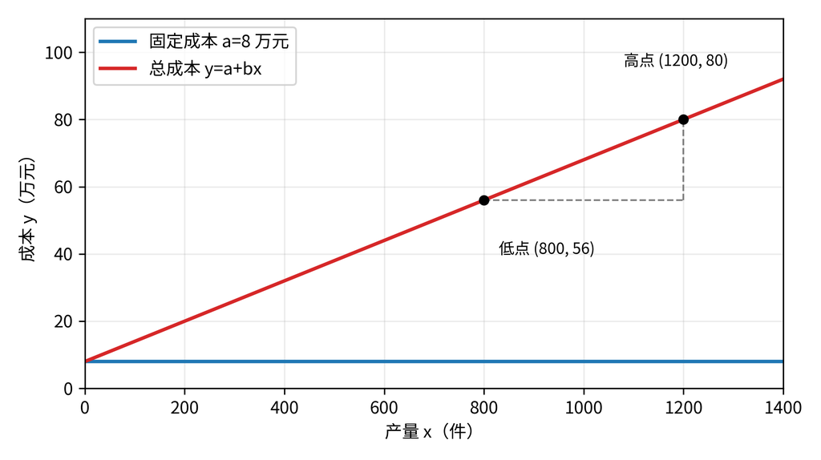

- 算例：固定 8 万元、单位变动 600 元/件，1000 件 → 单位固定 $80000\div1000=80$、单位成本 680 元
- 边界：相关范围外固定成本阶梯跳变，性态模型要重估

## 成本核算的三种基本方法

> 上一页讲成本性态；这一页讲成本按什么对象归集，即三种基本核算方法。

| 方法 | 成本对象 | 适用生产类型 | 关键点 |
| --- | --- | --- | --- |
| 品种法 | 产品品种 | 大量大批单步骤 | 按月归集，月末一般无在产品 |
| 分批法 | 订单或批次 | 单件小批、多品种 | 按批次归集，完工才结转 |
| 分步法 | 生产步骤 | 多步骤大量大批 | 完工与在产品间分配，逐步或平行结转 |

- 方法由生产类型与管理要求决定，不由会计偏好决定
- 同一企业不同车间可以并用：铸造用分步、装配用分批
- 智能制造实时采集工时与物料，核算粒度从“月”细化到“批”甚至“件”
- 判据：成本对象与生产组织方式匹配，核算才有管理价值

**结论：成本对象与生产组织方式匹配，三种核算方法才有管理价值。**

## 作业成本法：作业消耗资源

> 上一页讲三种基本核算方法；这一页讲间接费用占比高时的升级版，即作业成本法（activity-based costing，ABC）。
- **是什么**：作业成本法把间接费用先归集到作业，再按作业动因分到产品——中间多一层“作业”，是 ABC 的全部差别
- **为什么**：按单一工时分摊，把“批量小、调整多”的产品算便宜了；品种越多，失真越大
- **怎么判断**：动因可观测、可计量、与消耗相关，三条缺一条，ABC 就只剩表格

| 作业层级 | 典型作业 | 分配依据 |
| --- | --- | --- |
| 单位级 | 加工、装配 | 机器工时 |
| 批次级 | 设备调整、检验 | 调整次数、检验次数 |
| 产品级 | 工艺设计、物料清单（BOM）维护 | 产品数 |
| 设施级 | 厂房、照明 | 面积或直接分摊 |

- 适用判据：间接费用占比高、品种多、批量差异大——三条同时成立才值得上 ABC；它的价值不在算得更准，而在暴露不增值作业
- 四步：识别作业 → 归集资源 → 选动因 → 算分配率并分配

**结论：ABC 的价值不在算得更准，而在把不增值作业暴露出来。**

## 成本控制的原则与方法体系

> 上一页讲 ABC；这一页讲控制本身——五条原则、一套方法与一个闭环。

| 原则 | 含义 | 落地做法 |
| --- | --- | --- |
| 全面控制 | 全过程、全员、全方位 | 指标分解到班组 |
| 责权利结合 | 谁控制、谁负责、谁受益 | 与考核和奖惩挂钩 |
| 例外管理 | 只抓异常差异 | 设阈值，超限才分析 |
| 经济效益 | 控制成本低于控制收益 | 不搞形式化报表 |
| 分级归口 | 按组织层级归口管理 | 厂部、车间、班组三级 |

- 方法体系：预算控制、标准成本、责任会计、价值工程、作业成本法（ABC）与作业管理（activity-based management，ABM）
- 闭环：定标准 → 记实际 → 算差异 → 找原因 → 纠偏（PDCA 循环，即计划、执行、检查、处理）

**结论：控制体系只有两条落点——有人负责、抓得住异常。**

## 责任会计与三类责任中心

> 上一页讲控制原则；这一页讲谁对成本负责，即责任会计与三类责任中心。

| 责任中心 | 考核指标 | 典型部门 |
| --- | --- | --- |
| 成本中心 | 可控成本与费用预算 | 车间、职能部门 |
| 利润中心 | 边际贡献或营业利润 | 事业部、分厂 |
| 投资中心 | 投资报酬率、剩余收益 | 子公司、项目公司 |

- 责任会计：把企业划分为责任中心，只考核可控范围
- 可控成本三条件：可预见、可计量、可调节
- 内部转移价格：市场价格、成本加成、协商价格
- 责任报告：实际与预算对比，只报可控差异

**结论：责任会计的核心是可控——考核什么，人就管什么。**

## 全面成本管理：三全与四支撑

> 上一页讲责任中心；这一页把责任从几个中心扩到全员、全过程、全方位。
- 全面成本管理（total cost management，TCM）：全员参与、全过程覆盖、全方位核算
- 全员：指标到岗、改善提案、成本意识培训
- 全过程：设计、采购、制造、销售、服务、报废
- 全方位：显性成本与隐性成本（质量、时间、库存、环境）
- 四个支撑：组织（成本委员会）、指标（责任预算）、工具（ABC 与目标成本）、文化（持续改善）
- 与全面质量管理（total quality management，TQM）、全员生产维护（total productive maintenance，TPM）同构：全面、全员、全过程、持续改进
- 落地三招：指标到岗（单耗、能耗、工时分解到班组）、日清日结（每天公布产量与废品）、改善提案（一线最懂浪费在哪）
- 判据：TCM 看总成本，不看单项费用最低

**结论：没有指标与提案制度托底，全员成本管理就只是口号。**

## 成本管理的发展：核算、控制、企划

> 上一页讲全面成本管理；这一页看它的来路，三个阶段一路把成本发生的时间点往前移。

| 阶段 | 大致年代 | 核心任务 | 代表方法 |
| --- | --- | --- | --- |
| 成本核算 | 20 世纪上半叶 | 算准产品成本 | 品种法、分批法、标准成本 |
| 成本控制 | 20 世纪 50—80 年代 | 事中控制与责任 | 责任会计、预算、ABC |
| 成本企划 | 20 世纪 60 年代以来 | 设计阶段锁定成本 | 目标成本、价值工程、LCC（全生命周期成本） |

- 演进逻辑：从“算过去”到“控现在”，再到“设计未来”
- 20 世纪 90 年代以来：战略成本管理、作业管理（ABM）、全生命周期成本
- 成本企划四阶段：商品企划 → 开发设计 → 生产准备 → 量产
- 智能制造：实时核算与预测性控制，把三个阶段压进同一个数据平台

**结论：成本管理越往前移越值钱——设计阶段锁定的成本，事后很难改回来。**

## 三种基本竞争战略的成本逻辑

> 上一页讲发展阶段；这一页讲战略，因为战略决定成本目标定在哪里。

| 战略 | 成本管理重点 | 主要风险 |
| --- | --- | --- |
| 成本领先 | 规模、学习曲线、极致效率 | 只砍成本，牺牲质量与创新 |
| 差异化 | 为功能与品牌付费，成本让位于价值 | 溢价不被市场接受 |
| 聚焦 | 细分市场的成本或差异化 | 细分市场太小、被跨界打击 |

- 战略成本动因：规模、范围、学习、技术、选址
- 工具：价值链分析、战略定位分析、成本动因分析
- 成本领先不等于低价，差异化也不等于不计成本
- 智能制造用柔性能力支持“低成本 + 多品种”的混合战略

**结论：先选战略再选降本工具，两者错位，越努力越亏。**

## 智能制造如何改变成本结构

| 技术 | 成本结构变化 | 收益 | 新风险 |
| --- | --- | --- | --- |
| 自动化 | 固定成本↑、变动成本↓ | 节拍稳、人工少 | 产能利用率不足则亏损放大 |
| 数字化 | 软件与数据摊销为固定成本 | 质量、库存、信息成本降 | 系统投资与数据治理成本 |
| 柔性制造 | 换型成本↓、小批量可行 | 库存与缺货损失↓ | 设备与编程投入上升 |

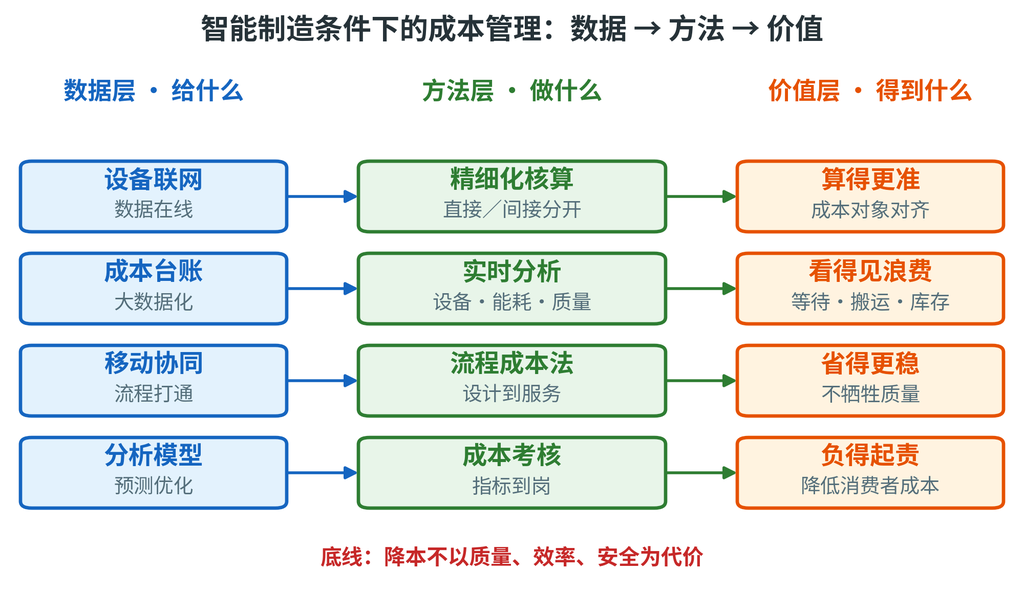

- 算例：售价 100 元，固定成本 200→320 万元、单位变动成本 60→45 元 → $Q_0=200\div(100-60)=5$、$320\div(100-45)=5.82$ 万件；交叉 $200+60Q=320+45Q$ → $Q=8$ 万件
- 判据：先答“哪个成本项因此可测、可降”，先有订单再上自动化，否则固定成本放大经营杠杆

## 案例：某机械产品成本结构分析

> 上一页讲智能制造怎么改写成本结构；这一页用一个机械产品的示意数据练“读结构”。

教学案例（示意数据）：某机械产品售价 800 元/件，产量与费用处于正常区间；下表金额均为不含税口径。

| 成本项目 | 金额（元/件） | 占比 | 判读 |
| --- | --- | --- | --- |
| 直接材料 | 380 | 55.9% | 设计与采购决定 |
| 直接人工 | 90 | 13.2% | 自动化空间有限 |
| 制造费用 | 150 | 22.1% | 设备与调度 |
| 期间费用 | 60 | 8.8% | 销售与管理 |
| 合计 | 680 | 100% | — |

- 口径说明：表中“合计 680 元/件”为完全成本（含期间费用），产品成本只含料工费，为 620 元/件
- 产品成本 $380+90+150=620$ 元，毛利 $800-620=180$ 元（$180/800=22.5\%$），净利 $800-680=120$ 元（$120/800=15.0\%$）
- 材料毛利率 $=(800-380)/800=52.5\%$，材料是降本主战场
- 判据：先降占比最大的；材料降 5% 即 $380\times5\%=19$ 元/件，降 $19/680=2.8\%$

**结论：降本先看结构再看单项——材料的一分钱比人工的一分钱更好赚。**

## 成本管理的五个常见误区

> 上一页用案例练读结构；这一页把常见的五种误判摆出来对照。

| 误区 | 表现 | 纠正 |
| --- | --- | --- |
| 唯采购价 | 只比价、换便宜材料 | 算总成本与质量损失 |
| 成本归财务 | 设计不问成本、现场不算账 | 成本是设计出来的 |
| 规模万能 | 超产能仍按原固定成本摊 | 只在相关范围内成立 |
| 固定不可控 | 不做产能与投资决策 | 折旧由投资决策锁定 |
| ABC 更准 | 动因十几个、维护不起 | 动因数量与收益匹配 |

- 共同根源：把成本当成会计核算的结果，而不是设计与管理的结果

**结论：五个误区一个病根——把成本交给会计，而不是交给设计者和现场。**

## 本部分小结：从记账到战略

> 上一页讲五个误区；这一页把整个第一部分收成六步。
1. 财务三问与会计恒等式，给出成本管理的坐标系
2. 成本是对象化的费用；经济用途、性态、归属三种分类交叉使用
3. 成本性态决定降本杠杆：固定成本靠利用率，变动成本靠单耗与单价
4. 核算方法服务生产类型；ABC 让间接费用与不增值作业可见
5. 控制靠标准、预算、责任会计；差异要分解到价差与量差
6. 成本企划与价值工程把成本锁在设计阶段，战略决定成本目标

**结论：成本不是算出来的，是设计和管理出来的——这就是第一部分的落点。**

## 第一部分复习与练习

> 上一页小结第一部分；这一页用三道练习验收差异分析、量本利与价值工程。
- 覆盖：差异分析、量本利、价值工程、综合判断
- 要求：写出公式、代入数字、说明判据，先独立完成再对照讲稿

**练习一（差异分析）**：标准工时 1.5 小时/件、标准工资率 22 元/小时；实际产量 800 件、实际工时 1250 小时、实际工资率 23 元/小时。求总差异并分解为工资率差异与效率差异。

**练习二（量本利）**：$F=240$ 万元（年固定成本）、$p=120$ 元/件（单价）、$v=72$ 元/件（单位变动成本）。求盈亏平衡量与目标利润 120 万元时的销量。

**练习三（价值工程）**：某部件功能得分 3（总分 15）、成本 50 万元（总成本 200 万元）。求价值系数 $V=F/C$（本题 $F$ 为功能系数 3/15、$C$ 为成本系数 50/200）并判断。

**思考题**：为什么压低采购价可能推高总成本？请用本部分的三个概念回答。

**结论：公式会写、数会代、判据会说出来，三题才算过关。**

## 推导留给 AI：成本管理概述（汇总）

> 上一页练完三题；这一页把问题推到本部分之外，留四个更开放的追问。
- 制造费用按工时分摊与按机器工时分摊，什么情况下会得出相反的降本结论？
- 资产负债率 0.5～0.8 是经验值，不同行业的合理区间为什么差异很大？
- 材料毛利率高但净利率低，问题可能出在哪些成本项上？如何逐项定位？
- “全员成本管理”与“考核造假”之间，指标设计上如何取得平衡？

**结论：能把一个问题拆成可查的数与可比的口径，才说明这一部分真的学会了。**

# 第二部分 · 成本指标与分析工具

- 标准成本法与差异分析：把“超支”拆成价格与用量
- ABC 成本法（作业成本法）：按作业分，而不是按工时分
- 量本利分析（盈亏平衡、目标利润、安全边际）；周转率与目标成本、价值工程
- 本部分落点：会用三个工具做经营判断
- **承上**：上一部分回答了成本怎么分类、怎么流转；本部分要回答用什么指标度量成本、用什么工具把成本管下去。

## 成本指标：绝对额、单位成本与成本比率

> 上一部分把成本分清了类，这一部分先立度量成本的三把尺子，看它们各回答什么问题。
- 绝对额：总成本、某成本项目金额，回答“一共花了多少”
- 单位成本：总成本除以产量，回答“每件花了多少”，用于报价与比价
- 成本比率：成本与收入、利润之比，回答“效率与结构如何”
- 三个层次不能互相替代：绝对额看规模，单位成本看效率，比率看质量
- 例：甲厂总成本 1 亿元、乙厂 5000 万元，不能判定谁更差，要看单位成本与比率
- 选指标先问用途：对外披露、内部考核，还是投资决策

| 层次 | 典型指标 | 回答的问题 | 主要局限 |
| --- | --- | --- | --- |
| 绝对额 | 总成本、材料费、制造费用 | 花了多少、超没超预算 | 受规模影响，不可横向比 |
| 单位成本 | 元/件、元/吨 | 每件成本高低 | 受产量与品种结构影响 |
| 成本比率 | 成本费用利润率、毛利率 | 投入产出效率 | 受会计口径与价格水平影响 |

**结论：三个层次不可互相替代——绝对额看规模，单位成本看效率，比率看质量，选指标先问用途。**

## 单位产品成本与成本降低率

> 上一页把三把尺子分开；这一页把单位成本算出来，并回答“单位成本降了是不是真降本”。

$$c=\frac{TC}{Q},\qquad \Delta c=\frac{c_0-c_1}{c_0}\times100\%$$

- $c$ 单位产品成本（元/件）、$TC$ 总成本（万元）、$Q$ 产量（件）；$\Delta c$ 为成本降低率，用基期 $c_0$ 与报告期 $c_1$ 对比
- 算例：产量 2 万件、总成本 124 万元 → 基期单位成本 62 元
- 次年产量 2.5 万件、总成本 147.25 万元 → 报告期单位成本 58.9 元
- 成本降低率 $=(62-58.9)/62=5.0\%$，但总成本 $(147.25-124)/124=18.75\%$
- 单位成本下降有一部分来自产量摊薄：设固定成本 60 万元、产量由 2 万件增到 2.5 万件，单位固定成本从 $60/2=30$ 元降到 $60/2.5=24$ 元
- 可比性三前提：产量在相关范围内、品种结构不变、价格水平可比
- 判读：把“降本”拆成真降本与摊薄降本，考核才不会误导

**结论：降本要拆成真降本与摊薄降本；只用单位成本考核，会诱导多生产、把成本压进库存。**

## 成本费用利润率

> 上一页的单位成本只看生产环节；这一页改用比率，把期间费用一起算进来。
- 定义：利润总额 ÷ 成本费用总额 × 100%，反映每 1 元成本费用创造多少利润
- 成本费用总额 = 营业成本 + 税金及附加 + 销售费用 + 管理费用 + 财务费用
- 算例：$300/2000\times100\%=15\%$，即每投入 100 元创造 15 元利润
- 含义：每投入 100 元成本费用创造 15 元利润，剔除了企业规模影响
- 与毛利率的区别：毛利率只扣营业成本，这个指标把期间费用也算进来
- 与销售净利率的区别：分母是成本费用而不是收入，看的是投入产出
- 用途：横向比同行、纵向比年度，判断成本花得值不值
- 警惕：利润为负时指标失真；靠压研发、压安全投入刷出的高指标不可取

**结论：成本费用利润率比毛利率全面；但利润为负时会失真，靠压缩研发与安全投入刷高不可取。**

## 库存周转率与资金周转率

> 上一页看成本费用利润率；这一页看资金占用的周转效率。

公式

- 库存周转率 $=\frac{销售物料成本}{平均库存}=\frac{2\times 销售物料成本}{期初库存+期末库存}$
- 资金周转率 $=\frac{本期主营业务收入}{平均占用资金}$

**算例**：某公司一季度销售物料成本 200 万元，期初库存 30 万元、期末库存 50 万元。

- 平均库存 $=(30+50)/2=40$ 万元
- 季度库存周转率 $=200/40=5$ 次
- 年化库存周转率 $=200\times4/40=20$ 次（一年周转 20 次：年销售物料成本 ≈ 平均库存 × 20）
- 判读：周转次数越高，资金占用越少；但过高可能是库存过薄导致停线
- 与精益的关系：降低库存 = 减少八大浪费中的“库存”，同时提高周转率

**结论：周转率看资金占用效率，但不是越高越好；库存要降，也要留缓冲防断料。**

## 成本性态与混合成本分解

> 上一页看资金周转；这一页把成本按性态拆开，分出固定成本与单位变动成本。

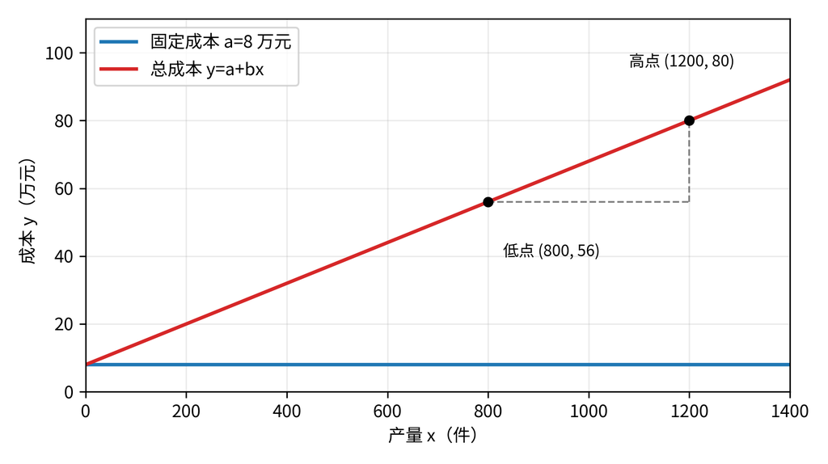

高低点法：用最高与最低两期成本求固定成本与单位变动成本

- 成本性态：成本总额随业务量变化的规律，分固定、变动、混合三类
- 混合成本（水电、维修、检验）既有固定基数，又随业务量上升
- 高低点法：取业务量最高与最低两期，用差额求单位变动成本
- $b=\dfrac{y_{\max}-y_{\min}}{x_{\max}-x_{\min}}$，$a=y_{\max}-bx_{\max}$；$b$ 单位变动成本（万元/件）、$a$ 固定成本（万元）、$x$ 业务量（件）、$y$ 成本总额（万元），成本模型为 $y=a+bx$
- 算例：产量 1200 件时成本 80 万元，800 件时 56 万元
- $b=(80-56)/(1200-800)=0.06$ 万元/件（600 元/件）；$a=56-800\times0.06=8$ 万元
- 回归法：用全部数据做最小二乘，以决定系数 $R^2$ 判断拟合；6 个月数据显示大修被当成变动成本，斜率约高估 11%
- 判读：高低点法只用两点，易受异常期影响；波动大时改用回归分析，并先剔除异常期

**结论：成本性态是量本利的前提；混合成本先用高低点法拆开，波动大时改用回归并剔除异常期。**

## 边际贡献与边际贡献率

> 上一页把成本拆成固定与变动；这一页用售价减单位变动成本定义边际贡献。

$$m=p-v,\qquad r=\frac{m}{p}=1-\frac{v}{p},\qquad M=F+\Pi$$

| 项目 | 单位（元） | 总额（万元） |
| --- | --- | --- |
| 销售收入 | 100 | 750 |
| 变动成本 | 60 | 450 |
| 边际贡献 | 40 | 300 |
| 固定成本 | — | 200 |
| 利润 | — | 100 |

- 算例：单价 $p=100$ 元/件、单位变动成本 $v=60$ 元/件、销量 7.5 万件，得单位边际贡献 $m=40$ 元/件、边际贡献率 $r=40\%$
- 边际贡献总额 $M$ 先补偿固定成本 $F$，余额才是利润 $\Pi$，即 $M=F+\Pi$
- 判读：$m>0$ 才值得生产；$r$ 用于比较产品与品种结构
- 误区：把毛利当边际贡献——毛利扣的是全部生产成本，含固定制造费用

**结论：边际贡献先补固定成本、余额才是利润；m 大于零就值得生产，r 用于比较产品与品种结构。**

## 变动成本法与完全成本法

> 上一页把边际贡献作为补偿固定成本的来源；这一页看固定制造费用记在哪，利润会差多少。

| 项目 | 完全成本法 | 变动成本法 | 差额 |
| --- | --- | --- | --- |
| 单位成本 | 160 元 | 60 元 | 100 元 |
| 期末存货 | 32 万元 | 12 万元 | 20 万元 |
| 当期利润 | 4 万元 | −16 万元 | 20 万元 |

- 分歧点：完全成本法把固定制造费用摊进产品成本，变动成本法把它作为期间费用一次扣除
- 算例：产量 8000 件、销量 6000 件、售价 200 元、单位变动生产成本 60 元
- 固定制造费用 80 万元、固定期间费用 20 万元
- 完全成本法：单位成本 $60+80\times10^4/8000=160$ 元，存货带走 20 万元固定费用
- 变动成本法：边际贡献 $6000\times(200-60)=84$ 万元、固定成本 $80+20=100$ 万元 → 亏损 16 万元
- 差额 $2000\times100=20$ 万元 = 期末存货 × 单位固定制造费用
- 判读：增产不增销时完全成本法会“造”出利润，考核产量要防这一手

**结论：两法利润差额等于期末存货里的固定制造费用；按完全成本法考核产量，会诱导增产不增销。**

## 代码复算（二）：变动成本法与完全成本法

> 上一页是成本归集；这一页用代码算同一批存货在两种口径下的利润差。

```python
q_prod, q_sold, price, varc = 8000, 6000, 200, 60
fix_mfg, fix_sell = 800_000, 200_000

unit_fix  = fix_mfg / q_prod          # 单位固定制造费用
full_cost = varc + unit_fix           # 完全成本法单位成本
rev  = q_sold * price
cm   = q_sold * (price - varc)        # 边际贡献
profit_var  = cm - (fix_mfg + fix_sell)
profit_full = rev - q_sold*full_cost - fix_sell

print("单位固定", unit_fix, "完全单位成本", full_cost)
print("边际贡献", cm, "变动法利润", profit_var, "完全法利润", profit_full)
print("期末存货", (q_prod-q_sold)*full_cost, "差额", profit_full-profit_var)
```

```
单位固定 100.0 完全单位成本 160.0
边际贡献 840000 变动法利润 -160000 完全法利润 40000.0
期末存货 320000.0 差额 200000.0
```

- 输出：单位固定 100 元、完全单位成本 160 元；边际贡献 84 万元、变动法利润 $-16$ 万元、完全法利润 4 万元
- 期末存货 2000 件 × 160 = 32 万元，比变动法多带走 20 万元固定费用——这就是两法差额的来源
- 代码把“存货带走固定费用”这件事算成了数：$2000\times100=20$ 万元

**结论：两法差的不是算法，是固定制造费用记在哪；代码一跑，差额恰好等于期末存货里的固定费用。**

## 量本利分析：三线图与盈亏平衡点

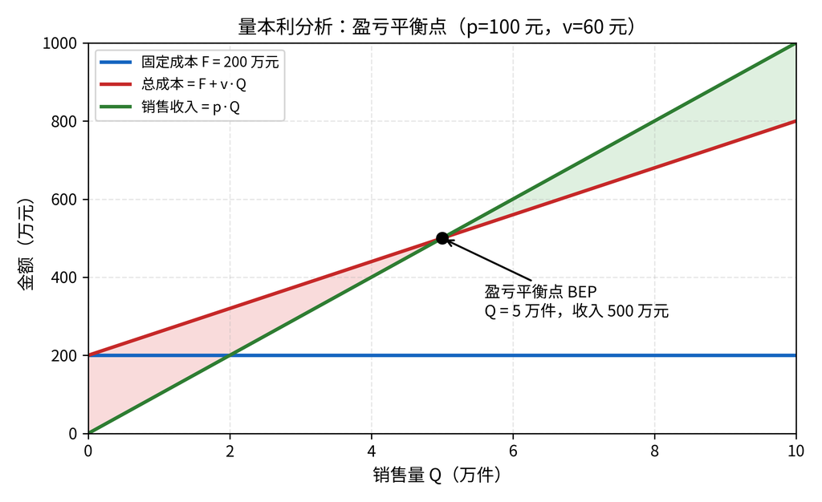

- 横轴销量、纵轴金额；三条线：固定成本、总成本 $F+vQ$、收入 $pQ$
- 交点即盈亏平衡点：$Q_0=200\div(100-60)=5$ 万件、销售额 $5\times100=500$ 万元
- 交点左侧两线之间是亏损区，右侧是盈利区
- 两线斜率之差 $p-v=40$ 元，就是每多卖一件的利润增量
- 销量 10 万件：收入 $100\times10=1000$、总成本 $200+60\times10=800$、利润 200 万元
- 三个参数在相关范围内不变，超出范围要重画

## 盈亏平衡点：实物量与金额两种算法

> 上一页在图上读保本点；这一页给出实物量与金额两套算法。

$$Q_0=\frac{F}{p-v},\qquad S_0=\frac{F}{1-v/p}=\frac{F}{r}$$

- $Q_0$ 保本销量（件）、$S_0$ 保本销售额（元）；实物量法适合单一品种，金额法适合多品种和整体测算
- 算例：$F=200$ 万元、$p=100$ 元、$v=60$ 元 → $Q_0=5$ 万件、$S_0=500$ 万元
- 单位变动成本降 5 元：$Q_0=200/45=4.44$ 万件，降 $(5-4.44)/5=11.1\%$
- 固定成本降 50 万元：$Q_0=150/40=3.75$ 万件，降 $(5-3.75)/5=25\%$
- 售价降 10 元：$Q_0=200/30=6.67$ 万件，升 $(6.67-5)/5=33.3\%$
- 口径：$F$ 只含与销量无关的固定成本，$v$ 只含随销量变动的部分
- 常见错误：把固定制造费用又摊进 $v$，或把半变动费用整体当固定成本

**结论：保本量 Q0＝F/(p−v)、保本额 S0＝F/r，两法互为验算；固定成本与单位变动成本必须按性态分清。**

## 安全边际与保本作业率

> 上一页求出保本点；这一页回答销量还能掉多少才亏损。

| 销量 | 边际贡献 | 利润 | 安全边际率 |
| --- | --- | --- | --- |
| 5.5 万件 | 220 万元 | 20 万元 | 9.1% |
| 7.5 万件 | 300 万元 | 100 万元 | 33.3% |
| 9.0 万件 | 360 万元 | 160 万元 | 44.4% |

- 安全边际量 = 实际销量减保本销量 = 7.5 − 5 = 2.5 万件
- 安全边际额 = 2.5 × 100 = 250 万元；安全边际率 = 2.5/7.5 = 33.3%
- 保本作业率 = 保本销量/实际销量 = 66.7%，与安全边际率互补
- 关系式：利润 = 安全边际额 × 边际贡献率 = 250 × 40% = 100 万元
- 经验判据：安全边际率 30% 以上较安全，10% 以下风险偏高
- 用途：回答“销量还能掉多少才亏损”，比单看保本点更直观

**结论：安全边际率是离亏损的缓冲带，与保本作业率互补；利润等于安全边际额乘边际贡献率。**

## 目标利润与目标销售量

> 上一页用安全边际衡量风险；这一页把利润目标反解成销量与销售额。

$$Q_t=\frac{F+\Pi_t}{p-v},\qquad S_t=\frac{F+\Pi_t}{r}$$

- $Q_t$ 目标销售量、$S_t$ 目标销售额、$\Pi_t$ 目标利润
- 算例：目标利润 100 万元 → $Q_t=300/40=7.5$ 万件、$S_t=750$ 万元
- 税后目标利润 75 万元、所得税率 25% → 税前 100 万元，仍是 7.5 万件
- 若市场只接受 95 元：$Q_t=300/35=8.57$ 万件，需增产 14.3%
- 目标利润为 0 时公式退化为保本点，两者是同一套模型
- 灵敏度：目标利润每加 40 万元，就得多卖 1 万件
- 目标利润售价 $p=(F+\Pi_t)/Q+v$：销量 6 万件、目标利润 100 万元 → 售价 110 元
- 提价 5 元与降单位变动成本 5 元效果相同：单位边际贡献都加 5 元
- 用途：年度经营计划、销售目标分解、产能与采购计划

**结论：目标销售量公式是保本点公式的推广；提价与降单位变动成本对目标销量的作用对称。**

## 多品种盈亏平衡：加权平均法

> 上一页的目标销量针对单一品种；这一页解决多品种企业的保本点。

| 产品 | 销售收入 | 边际贡献率 | 边际贡献 |
| --- | --- | --- | --- |
| A | 500 万元 | 40% | 200 万元 |
| B | 500 万元 | 30% | 150 万元 |
| 合计 | 1000 万元 | 35% | 350 万元 |

- 加权平均边际贡献率 $=0.5\times40\%+0.5\times30\%=35\%$（收入各占一半）
- 综合保本销售额 $=210/0.35=600$ 万元（固定成本 210 万元）
- 实际销售额 1000 万元：安全边际额 $1000-600=400$ 万元，利润 $400\times35\%=140$ 万元
- 结构变化：B 占 60% → $0.4\times40\%+0.6\times30\%=34\%$，保本额 $210\div0.34=617.6$ 万元
- 结论：多品种企业既要管总量也要管结构，低边际贡献率产品占比上升会推高保本点
- 前提：各产品边际贡献率与销售结构在预测期内基本稳定

**结论：多品种企业要用加权平均边际贡献率算保本额；卖得多不等于赚得多，结构变化会推高保本点。**

## 经营杠杆系数 DOL

> 上一页算保本与安全边际；这一页量化利润对销量的放大倍数。

$$DOL=\frac{m\cdot Q}{m\cdot Q-F}=\frac{M}{EBIT}$$

| 销量 | 边际贡献 | EBIT | DOL |
| --- | --- | --- | --- |
| 5.5 万件 | 220 万元 | 20 万元 | 11.0 |
| 6.0 万件 | 240 万元 | 40 万元 | 6.0 |
| 7.5 万件 | 300 万元 | 100 万元 | 3.0 |
| 10.0 万件 | 400 万元 | 200 万元 | 2.0 |

- 定义：息税前利润变动率与销量变动率的比值，$EBIT$ 为息税前利润
- 算例：销量 7.5 万件时 $DOL=300/100=3$，销量增 10% 利润增约 30%
- 越靠近保本点 DOL 越大：5.5 万件时达 11 倍，利润只剩 20 万元
- 用途：预测利润、评估扩产与降价促销的风险
- 提醒：DOL 随销量变化，不能拿一个数当常量用

**结论：DOL 等于边际贡献除以息税前利润，越靠近保本点越大；它随销量变化，不是常量。**

## 经营杠杆与经营风险

> 上一页把 DOL 定义成倍数；这一页用它比较人工线与自动化线的风险。

| 方案 | 固定成本 | 单位变动成本 | 保本量 | DOL |
| --- | --- | --- | --- | --- |
| 人工线 | 120 万元 | 70 元 | 4.0 万件 | 2.0 |
| 自动化线 | 320 万元 | 48 元 | 6.2 万件 | 4.3 |

- 固定成本越高，保本点越高、DOL 越大，经营风险越大（DOL 按销量 8 万件计）
- 保本与杠杆：$120\div30=4.0$、$320\div52=6.15$ 万件；$DOL$ 人 $=240\div120=2.0$、自 $=416\div96=4.33$
- 销量 8 万件：人工线 $30\times8-120=120$、自动化线 $52\times8-320=96$ 万元
- 销量 10 万件：$30\times10-120=180$、$52\times10-320=200$ 万元
- 交叉点：$30Q-120=52Q-320$ 解得 $Q=9.09$ 万件（$Q$ 销量，万件），超过它自动化更优
- 智能制造投资本质是“用固定成本换单位变动成本”，先算交叉销量与产能利用率
- 风险对策：柔性产能、设备租赁、订单预售、多品种分摊固定成本

**结论：智能制造投资是用固定成本换单位变动成本；产能利用率不够时，自动化是风险而不是优势。**

## 敏感性分析：单因素与多因素

> 上一页比较两条线的风险；这一页把利润对各因素的敏感程度排序。

| 因素 | 变动 | 利润 | 利润变动率 | 敏感系数 |
| --- | --- | --- | --- | --- |
| 售价 | +10% | 175 万元 | +75% | 7.5 |
| 单位变动成本 | +10% | 55 万元 | −45% | −4.5 |
| 销量 | +10% | 130 万元 | +30% | 3.0 |
| 固定成本 | +10% | 80 万元 | −20% | −2.0 |

- 基准：$Q=7.5$ 万件、$p=100$ 元、$v=60$ 元、$F=200$ 万元，利润 100 万元
- 敏感系数 = 利润变动率除以因素变动率，绝对值越大越敏感
- 排序：售价 7.5、单位变动成本 4.5、销量 3.0、固定成本 2.0
- 多因素：售价降 5% 同时销量增 5%，利润降到 75.6 万元（−24.4%）
- 用途：先管最敏感因素，定价与采购谈判的优先级高于现场节约
- 局限：单因素法假设其他因素不变，实际因素之间相关

**结论：售价最敏感、单位变动成本次之；定价与采购谈判优先于现场节约，但单因素法假设其他因素不变。**

## 代码复算（三）：量本利、DOL 与敏感性

> 前面几张都是单个公式；这一页用一个脚本把保本、利润、杠杆、敏感性一次算全。

```python
F, p, v = 200, 100, 60            # 固定成本（万元）、单价、单位变动成本（元）
Q0 = F / (p - v)
print("保本量", Q0, "万件；保本额", Q0*p, "万元")

Q = 7.5
profit = (p - v)*Q - F
dol = (p - v)*Q / profit
print("销量", Q, "利润", profit, "DOL", dol, "安全边际率", round((Q-Q0)/Q, 3))

for name, dp, dv, dQ, dF in [("售价+10%", 0.1, 0, 0, 0), ("变动成本+10%", 0, 0.1, 0, 0),
                             ("销量+10%", 0, 0, 0.1, 0), ("固定成本+10%", 0, 0, 0, 0.1)]:
    new = (p*(1+dp) - v*(1+dv)) * (Q*(1+dQ)) - F*(1+dF)
    print(name, round(new, 1), "变动率", round((new-profit)/profit, 3),
          "敏感系数", round((new-profit)/profit/0.1, 2))
```

```
保本量 5.0 万件；保本额 500.0 万元
销量 7.5 利润 100.0 DOL 3.0 安全边际率 0.333
售价+10% 175.0 变动率 0.75 敏感系数 7.5
变动成本+10% 55.0 变动率 -0.45 敏感系数 -4.5
销量+10% 130.0 变动率 0.3 敏感系数 3.0
固定成本+10% 80.0 变动率 -0.2 敏感系数 -2.0
```

- 输出：保本量 5 万件、保本额 500 万元；销量 7.5 万件时利润 100 万元、DOL 3、安全边际率 33.3%
- 四个情景的利润与敏感系数：售价 7.5、变动成本 $-4.5$、销量 3.0、固定成本 $-2.0$，与表一致
- 代码把“敏感系数＝利润变动率÷因素变动率”写成了除法，学生不用再凭印象记排序

**结论：量本利的四张表其实是一个脚本——改一个参数，保本点、杠杆、敏感系数一起变。**

## 标准成本法与差异分析

- **标准成本法**：标准成本（标准量 × 标准价）与实际成本比较，差异 = 实际 − 标准（正为超支）
- 材料差异分解：价格差异 $=(实际价格-标准价格)\times 实际用量$；用量差异 $=(实际用量-标准用量)\times 标准价格$

**算例**：标准用量 2 kg／件、标准价 10 元／kg；实际产量 1000 件、实际用量 2100 kg、实际价 9.5 元／kg。

- 标准材料成本 $=2\times10=20$ 元／件；按实际产量 1000 件计，标准总成本 $=1000\times20=20000$ 元
- 价格差异 $=(9.5-10)\times2100=-1050$ 元（**节约**）
- 用量差异 $=(2100-2000)\times10=+1000$ 元（**超支**）
- 总差异 $=-50$ 元（净节约 50 元）
- 判读：采购压价的功劳被现场浪费吃掉了

## 成本差异分析：料、工、费三条线

> 上一页只算材料差异；这一页把人工与制造费用的差异也纳入同一框架。

| 成本项目 | 价格类差异 | 数量类差异 | 责任中心 |
| --- | --- | --- | --- |
| 直接材料 | 价格差异 | 用量差异 | 采购与车间 |
| 直接人工 | 工资率差异 | 效率差异 | 人事与车间 |
| 制造费用 | 耗费差异、预算差异 | 效率差异、产量差异 | 车间与厂部 |

- 差异 = 实际成本 − 实际产量下的标准成本，正为超支、负为节约
- 价格差异 $=(AP-SP)\times AQ$，数量差异 $=(AQ-SQ)\times SP$
- $AP$ 实际价格、$SP$ 标准价格、$AQ$ 实际用量、$SQ$ 标准用量
- 制造费用分两块：变动部分用耗费与效率差异，固定部分用预算与产量差异
- 差异要可归责才有管理价值，不可控差异只作解释、不作考核
- 警惕转嫁：采购压价省了价格差异，可能换来用量差异与质量损失

**结论：料、工、费各自拆成价格类与数量类差异，差异落到责任中心才有管理价值。**

## 因素分析法：连环替代

> 上一页把差异按成本项目拆开；这一页用连环替代把差异拆到产量、单耗与单价上。

$$C=Q\times q\times p$$

- $C$ 材料成本、$Q$ 产量、$q$ 单耗、$p$ 单价
- 基数：1000 件 × 2 kg × 10 元 = 20000 元
- 实际：1100 件 × 1.95 kg × 10.5 元 = 22522.5 元，总差异 +2522.5 元
- ① 替代产量：1100 × 2 × 10 = 22000 元，影响 +2000 元
- ② 替代单耗：1100 × 1.95 × 10 = 21450 元，影响 −550 元
- ③ 替代单价：1100 × 1.95 × 10.5 = 22522.5 元，影响 +1072.5 元
- 合计 +2522.5 元，与总差异一致
- 规则：先数量后质量、先实物后价值；顺序变则分摊额变，总额不变
- 成本报表三张：商品产品成本表、主要产品单位成本表、制造费用明细表；常用分析法是比较、比率与因素分析

**结论：连环替代按先数量后质量、先实物后价值的顺序逐个替换；顺序变则分摊额变，总额不变。**

## 差异分析案例：一次超支的归因

> 上一页给出连环替代的算法；这一页用一张完整的差异表把一次超支归因。
- 标准：产量 1000 件；材料 2 kg/件 × 10 元/kg；人工 0.5 h/件 × 20 元/h
- 标准：变动制造费用 0.5 h/件 × 8 元/h；固定制造费用预算 8 万元
- 实际：材料 2100 kg × 9.5 元；人工 520 h × 19 元；变动制造费用 520 h × 8.5 元
- 实际：固定制造费用 8.6 万元；实际产量仍是 1000 件

| 项目 | 价格（预算）类差异 | 数量（效率）类差异 | 合计 |
| --- | --- | --- | --- |
| 材料 | −1050 元 | +1000 元 | −50 元 |
| 人工 | −520 元 | +400 元 | −120 元 |
| 变动费用 | +260 元 | +160 元 | +420 元 |
| 固定费用 | +6000 元 | 0 元 | +6000 元 |

- 代入：材料 $(9.5-10)\times2100=-1050$；人工 $(520-500)\times20=+400$ 元
- 合计 $-50-120+420+6000=6250$ 元，其中固定制造费用预算差异 6000 元
- 材料与人工的节约来自低价，效率其实都在超支；真问题是制造费用

**结论：这次超支 6250 元里 6000 元是固定制造费用预算差异；材料与人工的节约靠低价，效率都在超支。**

## 代码复算（四）：ABC 分配与差异分析

> 一边是“按作业分”，一边是“按标准拆”；这一页用一个脚本把两种归因都算出来。

```python
tot, adj, qc, oth = 100, 40, 20, 40      # 制造费用 100 万元 = 调整 40 + 质检 20 + 其他 40
a_adj, a_qc, a_h = 4, 20, 6000        # A 产品：调整 4 次、质检 20 次、机时 6000 h
b_adj, b_qc, b_h = 16, 80, 2000
rate_trad = tot*1e4 / (a_h + b_h)
r_adj, r_qc, r_h = adj/(a_adj+b_adj), qc/(a_qc+b_qc), oth*1e4/(a_h+b_h)
print("传统法", rate_trad, "元/h → A", rate_trad*a_h/1e4, "B", rate_trad*b_h/1e4)
print("ABC  → A", a_adj*r_adj + a_qc*r_qc + a_h*r_h/1e4,
      "B", b_adj*r_adj + b_qc*r_qc + b_h*r_h/1e4)

# 差异分析：价格差 =（实际价-标准价）×实际量；用量差 =（实际量-标准量）×标准价
mat_p, mat_q = (9.5-10)*2100, (2100-2000)*10
lab_p, lab_q = (19-20)*520,   (520-500)*20
var_p, var_q = (8.5-8)*520,   (520-500)*8
fixed = (8.6-8)*1e4
print("材料", mat_p, mat_q, "人工", lab_p, lab_q, "变动费", var_p, var_q)
print("固定费用差异", fixed, "合计", mat_p+mat_q+lab_p+lab_q+var_p+var_q+fixed)
```

```
传统法 125.0 元/h → A 75.0 B 25.0
ABC  → A 42.0 B 58.0
材料 -1050.0 1000 人工 -520 400 变动费 260.0 160
固定费用差异 5999.999999999996 合计 6249.999999999996
```

- ABC：传统法给 A 75/B 25 万元，ABC 给 A 42/B 58 万元，**B 被低估 33 万元**
- 差异：材料 $-1050/+1000$、人工 $-520/+400$、变动费 $+260/+160$、固定费 $+6000$，合计 $+6250$ 元
- 两段代码的共同点：先把“归因规则”写成公式，再让机器算——这比背结论可靠

**结论：ABC 与差异分析都是“换一个归因规则”，代码把规则和结果一起摆出来，谁对谁错一目了然。**

## ABC 成本法：按作业分成本

- **是什么**：不是另做一套账，而是把同一笔制造费用换一个分摊基准

[figure not shown]

## 成本动因分析：从动因到改善

> 上一页 ABC 把费用分到作业；这一页回答是哪些动因把成本推上去、能改什么。

| 动因 | 度量 | 主要影响的成本 | 改善手段 |
| --- | --- | --- | --- |
| 零件种类 | 种数 | 采购、库存、切换 | 平台化、标准化 |
| 设备调整 | 次数 | 调整人工、试废品 | 快速换模 |
| 检验 | 批次、次数 | 质检人工、设备 | 防错、免检 |
| 订单 | 单数 | 计划、销售、物流 | 合并订单、标准化配置 |

- 成本动因是引起成本发生的因素，分结构性（设计决定）与执行性（现场决定）；**产品复杂度是最大的隐性成本动因**——零件种类、工序数、定制选项越多，间接费用越高
- 分三步：列动因清单、量化动因量、按成本影响排序
- 例：$40\div20=2$ 万元/次；次数减半到 10 次 → $10\times2=20$ 万元，省 $40-20=20$ 万元
- 结构性动因决定成本上限，执行性动因决定能逼近上限多少
- 降本先改动因量（少品种、少调整、少检验），再改动因率（降低单次作业成本）

**结论：降本先改动因量、再改动因率；结构性动因决定成本上限，改设计最难但空间最大。**

## 成本分析的四种工具

> 前面分别讲了差异与动因分析；这一页把四种分析方法放在一条链条上看。

| 方法 | 回答的问题 | 典型输出 | 适用场景 |
| --- | --- | --- | --- |
| 对比分析 | 与谁比、差多少 | 差异额、差异率 | 同环比、同行对标 |
| 趋势分析 | 往哪个方向走 | 多期序列、增长率 | 月度经营分析 |
| 因素分析 | 差异由谁造成 | 各因素影响额 | 成本超支归因 |
| 比率分析 | 效率高不高 | 周转率、利润率 | 跨期、跨企业评价 |

- 四类工具构成链条：发现异常，定位原因，量化责任，横向评价
- 对比要有可比基础：口径、产量、价格、会计政策一致
- 趋势看拐点、不看单月波动，至少 12 期数据
- 因素分析解决归因，比率分析解决评价，不能互相替代
- 先有问题再选工具，为算而算的分析没人看

**结论：对比发现异常、趋势看方向、因素找原因、比率做评价；四类工具不能互相替代。**

## 成本分析工具的选择

> 上一页把分析方法归成四类；这一页把五个具体工具放到适用场景里选。

| 工具 | 回答的问题 | 适用场景 | 主要局限 |
| --- | --- | --- | --- |
| 标准成本 | 现场超支在哪 | 大批量、稳定工艺 | 标准易过时 |
| ABC 成本 | 间接费用该给谁 | 多品种、小批量 | 动因识别成本高 |
| 量本利 | 卖多少才不亏 | 定价、扩产决策 | 假设售价与成本线性 |
| 目标成本 | 设计该做到多便宜 | 新产品开发 | 需要跨部门协同 |
| 价值工程 | 哪个部件该改 | 产品改进 | 功能评分主观 |

- 组合用法：**目标成本定上限 → 价值工程找重点 → ABC 算准间接费 → 标准成本控现场 → 量本利做决策**
- 一句提醒：工具的价值不在“算得精”，而在“让该负责的人看见自己的数”

**结论：工具的价值不在算得精，而在让该负责的人看见自己的数。**

## 制造费用的预算与责任中心控制

> 上一页讲工具怎么选；这一页回到制造费用，讲间接成本日常怎么控。
- 制造费用是间接成本，控制难点在“责任不清”
- 三种控制手段：

| 手段 | 做法 | 关键 |
| --- | --- | --- |
| 预算控制 | 按部门编制造费用预算，月度对比 | 预算要按动因编，不能拍脑袋 |
| 责任中心 | 把费用指标落到车间／班组 | 可控费用才考核 |
| 标准与定额 | 设备维修定额、能耗定额、辅料定额 | 定额要定期修订 |

- **可控性原则**：只考核责任中心能控制的费用（如车间不能控制折旧政策）
- **例外管理**：只对超出阈值的差异深入分析，节省管理精力
- 现场降费三例：空压系统泄漏治理、设备预防性维护、辅料以旧换新

**结论：间接成本控制靠预算、责任中心与定额，核心是只考核可控费用、只深挖例外差异。**

## 目标成本法与成本驱动设计

> 上一页管的是量产后的费用；这一页转向设计端，先定成本再设计。
- **目标成本法**：先定售价与目标利润，倒推允许成本，再分解到零部件与工序
- 与“成本加成法”的方向相反：**市场定价 → 目标成本 → 设计降本**

公式

$$允许成本=预计售价\times(1-目标利润率)$$

**算例**：某新产品预计售价 500 元／件，公司要求利润率 15%。

- 允许成本 $=500\times(1-15\%)=425$ 元／件
- 当前估算 460 元/件 → 需降 $460-425=35$ 元/件，降幅 $35\div460=7.6\%$
- 降本路径：材料替代、结构简化、工序合并、供应商协同
- 成本驱动设计的六原则：成本意识培养、成本估算前置、价值工程、材料与成本效益、生产加工效率、循环设计
- 铁律：**设计阶段锁定 70% 以上的成本，量产后只能“挤毛巾”**

**结论：设计阶段锁定 70% 以上的成本；目标成本法先定允许成本再分解，量产后只能挤毛巾。**

## 价值工程：功能与成本的比值

> 上一页给出允许成本；这一页用价值系数找出该改哪个部件。

公式

$$价值系数\ V=\frac{功能系数\ F}{成本系数\ C}$$

- $V>1$：功能相对成本偏高，性价比好；$V<1$：成本相对功能偏高，应改进
- 分析步骤：确定功能 → 功能评分 → 计算功能系数与成本系数 → 求 $V$ → 定改进对象

**算例**

| 部件 | 功能系数 $F$ | 成本系数 $C$ | $V=F/C$ | 判断 |
| --- | --- | --- | --- | --- |
| 甲 | 0.80 | 0.50 | 1.60 | 性价比好，可保持 |
| 乙 | 0.30 | 0.50 | 0.60 | **成本偏高，重点改进** |

- 改进乙的三个方向：取消过剩功能、用低成本材料替代、简化结构
- 注意：$V$ 只是“相对值”，不能据此直接砍功能——还要看该功能对顾客是否必要

**结论：V 等于功能系数除以成本系数，V 小于 1 是重点改进对象；但 V 只是相对值，不能直接砍功能。**

## 成本领先与成本结构优化

> 上一页看单个部件的功能成本比；这一页看整条成本结构，决定降本空间从哪来。

| 成本项 | 占制造成本 | 情景降幅 | 对总成本影响 |
| --- | --- | --- | --- |
| 直接材料 | 60% | 3% | 1.8% |
| 直接人工 | 15% | 10% | 1.5% |
| 制造费用 | 25% | 12% | 3.0% |

- 成本领先不是样样最便宜，而是同等质量下总成本最低
- 影响＝占比×降幅：$60\%\times3\%=1.8\%$、$15\%\times10\%=1.5\%$、$25\%\times12\%=3.0\%$，合计 6.3%（表内降幅为情景假设）
- 制造费用占比高是智能制造的典型特征，折旧、能耗、维修是主战场
- 降本顺序：改设计（改结构），改工艺与采购（改单价），现场节约（改用量）
- 陷阱：只压采购价，会把成本转嫁成质量损失与停线成本
- 判据：看总拥有成本，不看单项报价

**结论：降本先看结构再排顺序——改设计、改工艺与采购、最后现场节约；判据是总拥有成本。**

## 成本与价格决策：加成与倒推

> 上一页讲成本结构；这一页把成本与价格连起来，讲加成与倒推两种定价。

$$P=C\times(1+r),\qquad C_t=P_t\times(1-m)$$

- 成本加成：$P$ 售价、$C$ 单位完全成本、$r$ 加成率
- 加成：$P=80\times(1+25\%)=100$ 元
- 倒推：$C_t$ 目标成本、$P_t$ 目标售价、$m$ 目标毛利率；$C_t=100\times(1-20\%)=80$ 元
- 互换：$r=20\%\div(1-20\%)=25\%$，反过来 $m=25\%\div(1+25\%)=20\%$
- 成本加成的缺陷：把成本高合理化，客户未必接受；适合定制、军工、内部转移
- 目标定价的前提：先做市场可接受价调研，再把成本压力分解到设计
- 智能制造：报价用成本模型加产能占用，避免只按材料加成

**结论：成本加成从成本推价格、目标定价从价格倒推成本，两者可互换；成本加成会把低效合法化。**

## 案例：亏损产品是否停产

> 上一页讲定价；这一页用边际贡献判断亏损产品该不该停。

| 产品 | 收入 | 变动成本 | 边际贡献 | 利润 |
| --- | --- | --- | --- | --- |
| A | 500 万元 | 350 万元 | 150 万元 | −30 万元 |
| B | 400 万元 | 280 万元 | 120 万元 | 20 万元 |
| C | 300 万元 | 250 万元 | 50 万元 | −10 万元 |
| 合计 | 1200 万元 | 880 万元 | 320 万元 | −20 万元 |

- A 亏 30 万元，但边际贡献 $500-350=150$ 万元为正；固定成本 $180+100+60=340$ 万元不变
- 停产 A：边际贡献 $320-150=170$ 万元，利润 $170-340=-170$，亏损从 20 扩到 170；判据：$m>0$ 且固定成本不可避免应继续生产

**结论：账面亏损不等于该停产；只要边际贡献为正且固定成本不可避免，停产会让亏损更大。**

## 案例：自制还是外购

> 上一页用边际贡献做停产判断；这一页用相关成本做自制外购取舍。

| 方案 | 相关成本（万元） | 说明 |
| --- | --- | --- |
| 外购 | 90 | 45 元/件 × 2 万件 |
| 自制 | 84 | 36 元/件 × 2 万件 + 专属固定 12 万元 |

- 相关成本原则：只比较随方案变化的成本，分摊的固定费用不相关
- 自制单位变动成本 = 18 + 12 + 6 = 36 元
- 不含机会成本：外购 $45\times2=90$、自制 $36\times2+12=84$ 万元，自制省 6 万元
- 机会成本 10 万元：自制 $84+10=94$ 万元高于外购 90 万元，应外购
- 非量化因素：质量风险、交期、技术外泄、供应商锁定
- 判据：自制相关成本 = 变动成本 + 可避免固定成本 + 机会成本

**结论：自制外购只比相关成本——变动成本、可避免固定成本与机会成本；分摊固定费用不参与比较。**

## 特殊订单的定价决策

> 上一页比较自制与外购；这一页看闲置产能下的特殊订单接不接。

| 订单 | 单价 | 增量利润 | 结论 |
| --- | --- | --- | --- |
| 1.5 万件 | 72 元 | +18 万元 | 接受 |
| 3 万件 | 72 元 | −4 万元 | 拒绝 |

- 前提：有闲置产能、不冲击正常市场、订单一次性
- 正常：售价 100 元、单位变动成本 60 元、固定成本 200 万元、销量 7.5 万件
- 单价 72 元高于单位变动成本 60 元，单位边际贡献 $72-60=12$ 元；1.5 万件增量 $12\times1.5=18$ 万元
- 3 万件超过闲置产能 2 万件，挤占正常销量 $3-2=1$ 万件
- 机会成本 $1\times40=40$ 万元；增量边际贡献 $12\times3=36$ 万元，$36-40=-4$ 万元
- 风险：低价单流入正常渠道、客户比价、反倾销认定
- 判据：增量收入大于增量成本加机会成本才接

**结论：特殊订单按增量分析判——增量收入大于增量成本加机会成本才接；超过闲置产能要先扣机会成本。**

## 代码复算（五）：停产、自制外购与特殊订单

> 三张“要不要做”的决策页；这一页用代码把边际贡献与相关成本算成同一张判决书。

```python
# 亏损产品：收入、变动成本
rev = {"A": 500, "B": 400, "C": 300}
var = {"A": 350, "B": 280, "C": 250}
cm  = {k: rev[k]-var[k] for k in rev}
print("边际贡献", cm, "合计", sum(cm.values()), "利润", sum(cm.values())-340)
print("停产 A 后利润", sum(cm.values())-cm["A"]-340)

# 自制外购：外购 45 元/件 ×2 万件；自制单位变动 36 元 + 专属固定 12 万元
print("外购", 45*2, "自制", 36*2+12, "含机会成本", 36*2+12+10)

# 特殊订单：单位边际贡献 12 元；订单 3 万件挤出 1 万件正常销量（每件 40 元边际贡献）
print("1.5 万件增量", 12*1.5, "3 万件增量", 12*3, "机会成本", 1*40, "净增", 12*3-1*40)
```

```
边际贡献 {'A': 150, 'B': 120, 'C': 50} 合计 320 利润 -20
停产 A 后利润 -170
外购 90 自制 84 含机会成本 94
1.5 万件增量 18.0 3 万件增量 36 机会成本 40 净增 -4
```

- 停产 A：边际贡献从 320 降到 170 万元，固定成本 340 万元不变，亏损从 20 扩大到 170 万元
- 自制外购：外购 90、自制 84、含机会成本 94 万元——**不含机会成本时自制省 6 万元，含了就反转**
- 特殊订单：1.5 万件赚 18 万元；3 万件增量 36 万元、机会成本 40 万元，净 $-4$ 万元，应拒绝

**结论：三个决策其实是同一句话——只看随方案变化的增量，固定成本与分摊费用不参与比较。**

## 本部分小结：三个判断

> 以上工具各自解决一类问题；这一页把六类决策与工具、判据对应起来。

| 决策场景 | 工具 | 关键判据 |
| --- | --- | --- |
| 保本销量 | 量本利分析 | 边际贡献等于固定成本 |
| 利润敏感 | 经营杠杆 | DOL 与安全边际率 |
| 成本超支 | 差异与因素分析 | 价格、用量、结构三项归因 |
| 亏损产品 | 边际贡献分析 | 固定成本是否可避免 |
| 自制外购 | 相关成本分析 | 变动成本加可避免固定成本加机会成本 |
| 特殊订单 | 增量分析 | 增量收入大于增量成本加机会成本 |

- 一句话：指标看层次，分析看动因，决策看相关成本
- 所有工具的前提都是成本性态可分解，先把固定与变动分开
- 工具的输出不是数字，而是该动哪个因素、动多少

**结论：指标看层次、分析看动因、决策看相关成本；所有工具的前提都是先把固定成本与变动成本分开。**

## 本部分复习与练习

> 这一部分的方法用五道题串一遍，覆盖保本、杠杆、差异、取舍与敏感性。
- ① $F=150$ 万元、$p=80$ 元、$v=50$ 元，求保本量与保本额（5 万件、400 万元）
- ② 上题销量 6 万件时，求利润、DOL、安全边际率（30 万元、6、16.7%）
- ③ 材料标准 3 kg/件 × 8 元/kg，实际 800 件耗用 2500 kg、单价 8.2 元，求价格与用量差异（+500 元、+800 元）
- ④ 外购 45 元/件；自制变动成本 36 元/件、专属固定 12 万元/年，年需 2 万件，机会成本 10 万元，如何决策（外购）
- ⑤ 在 $p=100$ 元、$v=60$ 元、$F=200$ 万元的基准上，售价降 5% 仍要保住 100 万元利润，销量需达多少（8.57 万件，增 14.3%）
- 书写要求：公式、代入、判读三步齐全，判读必须说出管理含义
- 提示：先判断问题属于保本、敏感、归因、取舍哪一类，再选工具

**结论：五题都按“公式—代入—判读”三步作答；先判断问题属于哪一类，再选工具。**

## 推导留给 AI：成本指标与分析工具（汇总）

> 这一部分的工具都建立在几条隐含假设上；页末四个问题把假设与边界挑明。
- 标准成本的价格差异乘实际用量、用量差异乘标准价格，这样分解为什么能相加等于总差异？
- ABC 法需要识别作业动因，动因数量选多少合适？选多了会怎样？
- 量本利假设售价与单位变动成本不变，现实中哪些情况会让这个假设失效？
- 目标成本法在“客户需求快速变化”的产品上是否适用？如何调整？

**结论：四个问题分别指向差异分解的代数恒等性、ABC 的实施成本、量本利的线性假设与目标成本的适用边界。**

# 第三部分 · 技术经济评价

- 资金有时间价值：今天的 1 元 ≠ 明天的 1 元；现金流量表（CI、CO、净现金流量）
- 静态／动态投资回收期、**NPV**、**IRR**
- 质量成本与全生命周期成本
- 本部分落点：会用一套判据判断“该不该投”
- **承上**：上一部分给出成本核算、成本预测与保本分析；本部分把这些数字放进项目的时间轴，回答一笔投资该不该做。

## 资金的时间价值：三个原因与一把尺子

> 上一页给出本部分的内容地图；这一页先立一条前提——同一笔钱在不同时点的价值不同。
- 同样 100 万元，今天到手与一年后到手，能买到的东西不一样——**资金的价值随时点变化**
- 三个原因：物价上涨使购买力下降；钱本可以投资生息；未来收益没有保证
- 折现率 $i$（年利率，%）就是对这三件事的打包定价：物价 + 资金成本 + 风险补偿
- 用图说话：横轴是时点，向上箭头是流入、向下箭头是流出，箭头长度是金额
- 两个方向：往后滚叫终值 $F$（元），往前折叫现值 $P$（元）；换算只靠利率与期数
- 判据：折现率要与现金流口径一致（税前／税后、名义／实际），否则等值关系不成立

| 原因 | 机制 | 对折现率的作用 |
| --- | --- | --- |
| 通货膨胀 | 同样金额购买力下降 | 至少要跑赢物价 |
| 投资机会 | 资金可投他处生息 | 机会成本即最低要求回报 |
| 风险 | 未来现金流不确定 | 越不确定，折现率越高 |

**结论：资金的时间价值来自物价、机会成本与风险，折现率就是把这三件事定成一个利率。**

## 单利与复利：同一笔钱的两种走法

> 上一页立起不同时点不可直接相加的前提；这一页看同一笔钱在两种计息规则下怎样长大。
- 单利：只对本金计息，利息不再生息，$F=P(1+ni)$
- 复利：利息并入本金，利滚利，$F=P(1+i)^n$
- 工程经济评价**一律用复利**：赚到的钱本可以再投出去
- 记号：$P$ 为本金（万元），$F$ 为本利和（万元），$i$ 为年利率（%），$n$ 为计息期数（年）
- 算例：本金 100 万元、年利率 10%、期限 5 年

| 年份 | 单利本利和（万元） | 复利本利和（万元） | 差额（万元） |
| --- | --- | --- | --- |
| 1 | 110.00 | 110.00 | 0.00 |
| 2 | 120.00 | 121.00 | 1.00 |
| 3 | 130.00 | 133.10 | 3.10 |
| 4 | 140.00 | 146.41 | 6.41 |
| 5 | 150.00 | 161.05 | 11.05 |

- 第 5 年当年就多出 4.64 万元，前四年累计只多 6.41 万元
- 期限越长、利率越高，差距越大；短期可近似，长期必须用复利

**结论：工程经济评价一律用复利，单利只用于短期票据与民间习惯口径。**

## 复利终值与现值：两个最基本的系数

> 上一页比较了两种计息规则；这一页把复利公式整理成两个可查的系数。
- 终值：现在一笔钱滚到未来，$F=P(1+i)^n$，系数记 $(F/P,i,n)$，括号内依次是未知量、已知量、利率与期数
- 现值：未来一笔钱折回今天，$P=F(1+i)^{-n}$，系数记 $(P/F,i,n)$
- 折现不是打折，是按**要求的回报率**把未来的钱换算成今天的等值金额
- 算例：$i=8\%$，5 年后的 100 万元，现值 $100\times0.6806=68.06$ 万元
- 72 法则：翻倍年数约等于 72 除以利率百分数，8% 约 9 年，心算够用
- 现值系数随利率、期数增大而变小：越远的钱、越高的利率，越不值钱

| 年利率 | 72 法则年数 | 精确年数 |
| --- | --- | --- |
| 6% | 12.0 | 11.90 |
| 8% | 9.0 | 9.01 |
| 10% | 7.2 | 7.27 |
| 12% | 6.0 | 6.12 |

**结论：终值与现值是一对互逆运算，现值系数回答的是未来的钱今天值多少。**

## 名义利率与实际利率：计息期的把戏

> 上一页的折算都按年计息；这一页处理计息期短于一年的常见情形。
- 名义利率 $r$（%）按年标价，但不一定按年计息；实际利率 $i$（%）是一年真正到手
- 换算：$i=(1+r/m)^m-1$，$m$ 为一年内的计息次数
- 算例：名义利率 12%，计息越密，实际利率越高

| 计息方式 | 一年计息次数 | 实际年利率 |
| --- | --- | --- |
| 按年 | 1 | $12.000\%$ |
| 按半年 | 2 | $(1+12\%/2)^2-1=12.360\%$ |
| 按季 | 4 | $(1+12\%/4)^4-1=12.551\%$ |
| 按月 | 12 | $(1+12\%/12)^{12}-1=12.683\%$ |
| 连续复利 | 无限 | $e^{0.12}-1=12.750\%$ |

- 规则：按年编现金流量就用实际利率；只给名义利率须先换算，否则 $NPV$ 偏大
- 消费贷“日息 0.045%”：单利 $0.045\%\times365=16.43\%$，日复利 $(1.00045)^{365}-1=17.85\%$

**结论：按年编制现金流量表就必须用实际利率折现，否则 $NPV$ 偏大。**

## 年金四种形态：普通、预付、递延、永续

> 上一页把名义利率换成实际利率；这一页处理工程上更常见的等额系列现金流。
- 年金：间隔相等、金额相等的一串现金流（记每期金额为 $A$，单位元），房租、维护费、分期还款、租赁费都是
- 判断只需两问：第一笔在期末还是期初？中间有没有空档、有没有终点？

| 类型 | 首笔时点 | 现值公式 | 制造场景 |
| --- | --- | --- | --- |
| 普通年金 | 每期期末 | $A(P/A,i,n)$ | 设备年维护费 |
| 预付年金 | 每期期初 | $A(P/A,i,n)(1+i)$ | 年初预付租金、保险费 |
| 递延年金 | 递延 $m$ 期后 | $A(P/A,i,n)(P/F,i,m)$ | 建设 2 年、第 3 年投产 |
| 永续年金 | 期末、无限期 | $A/i$ | 永续特许权收益 |

- 预付比普通多乘 $(1+i)$：每一笔都早收一期，自然更值钱
- 递延要折两次：先折到递延期末，再折到第 0 年
- 永续年金没有终值，只有现值；它是 $n\to\infty$ 时 $(P/A,i,n)$ 的极限

**结论：年金先判类型再选系数，判断只问首笔在期末还是期初、有没有终点。**

## 年金现值与终值：把一串钱折成一笔

- **是什么**：每年等额 $A$ 折到今天叫现值，滚到期末叫终值——只差折到哪个时点
- **为什么**：等额维护费、租金、净收益折成一笔，才能与投资额直接比较
- **怎么判断**：先判类型（首笔在期末还是期初、有无终点），再选系数

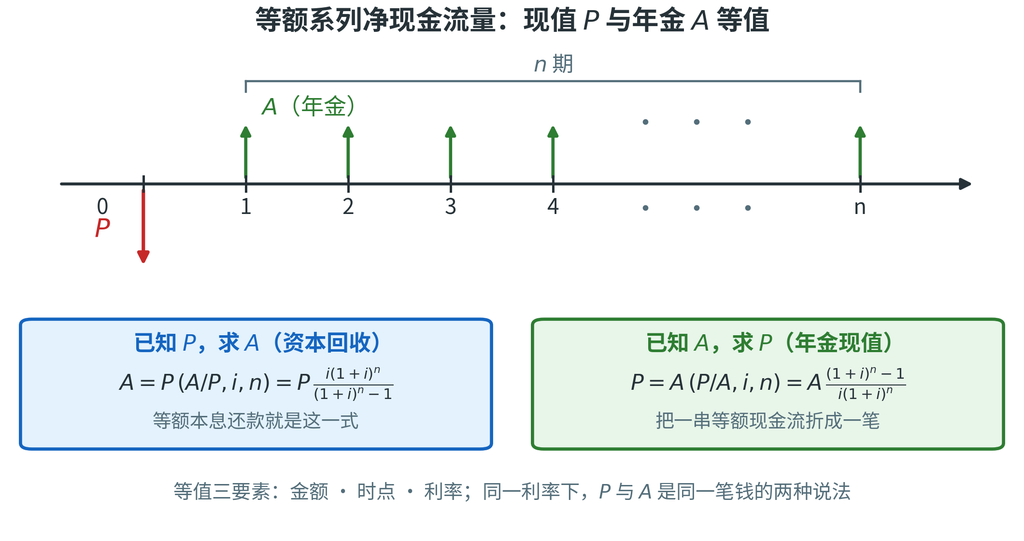

- 公式：$P=A(P/A,i,n)$、$F=A(F/A,i,n)$；两个系数成对互逆，$P$ 与 $A$ 是同一笔钱
- 算例：贷款 100 万元、10 年、年利率 6% → 每年还 $100\times0.13587=13.59$ 万元

## 等值计算：六个系数与一张总表

> 上一页给出年金两个系数；这一页把六个系数一次列全，作为全讲的计算工具箱。
- 等值：不同时点、不同金额，在给定利率下价值相等——100 万元今天等于 10% 利率下 5 年后的 161.05 万元
- 等值三要素缺一不可：金额、时点、利率；六个系数覆盖 $P\leftrightarrow F$、$A\leftrightarrow F$、$P\leftrightarrow A$

| 名称 | 符号 | 公式 | 已知→求 |
| --- | --- | --- | --- |
| 复利终值 | $(F/P,i,n)$ | $(1+i)^n$ | $P\to F$ |
| 复利现值 | $(P/F,i,n)$ | $(1+i)^{-n}$ | $F\to P$ |
| 年金终值 | $(F/A,i,n)$ | $\dfrac{(1+i)^n-1}{i}$ | $A\to F$ |
| 偿债基金 | $(A/F,i,n)$ | $\dfrac{i}{(1+i)^n-1}$ | $F\to A$ |
| 年金现值 | $(P/A,i,n)$ | $\dfrac{(1+i)^n-1}{i(1+i)^n}$ | $A\to P$ |
| 资本回收 | $(A/P,i,n)$ | $\dfrac{i(1+i)^n}{(1+i)^n-1}$ | $P\to A$ |

- 符号读法：括号里先写要求的量、再写已知的量，$i$ 为年利率（%）、$n$ 为期数（年）；表只列整数利率与整年，非整数用线性插值或按公式算

**结论：六个系数本质是三对互逆运算，记谁折谁比记公式更重要。**

## 现金流量表：投资决策的通用语言

> 上一页备齐了折算工具；这一页回答折的是什么——先把项目现金流排成表。
- 项目现金流量只记**实际发生的现金收支**（单位：万元），不记账面利润与折旧（折旧抵税另算）

| 要素 | 符号 | 内容 |
| --- | --- | --- |
| 现金流入 | CI | 销售收入、回收固定资产余值、回收流动资金 |
| 现金流出 | CO | 建设投资、流动资金、经营成本、税金 |
| 净现金流量 | $CI-CO$ | 逐年净额，是评价的输入 |

**算例（单位：万元）**

| 计算期 | 0 | 1 | 2 | 3 | 4 | 5 | 6 |
| --- | --- | --- | --- | --- | --- | --- | --- |
| 现金流入 CI | — | — | — | 800 | 1200 | 1200 | 1200 |
| 现金流出 CO | — | 600 | 900 | 500 | 700 | 700 | 700 |
| 净现金流量 | — | −600 | −900 | 300 | 500 | 500 | 500 |
| 累计净现金流量 | — | −600 | −1500 | −1200 | −700 | −200 | 300 |

- 判读：第 5 年末仍为 −200 万元，第 6 年转正为 +300 万元，说明**静态回收期约 5.4 年**

**结论：折旧不是现金流、折旧抵税才是，评价的一切数字都从这张表出发。**

## 折旧：三种方法与非现金成本

- **是什么**：把原值在使用期内摊入成本；折旧**不是现金流出**，但折旧抵税是
- 三要素：原值（含运杂费与安装费）、净残值、折旧年限
- 直线法 $D=(P-L)/n$；工作量法按实际工时或产量分摊
- 双倍余额递减 $D_t=(2/n)BV_{t-1}$（末两年改直线）；年数总和法 $D_t=2(P-L)(n-t+1)/[n(n+1)]$
- 算例：原值 100、残值 5、5 年 → 直线 $(100-5)/5=19.00$、双倍 $100\times2/5=40.00$、总和 $95\times5/15=31.67$ 万元

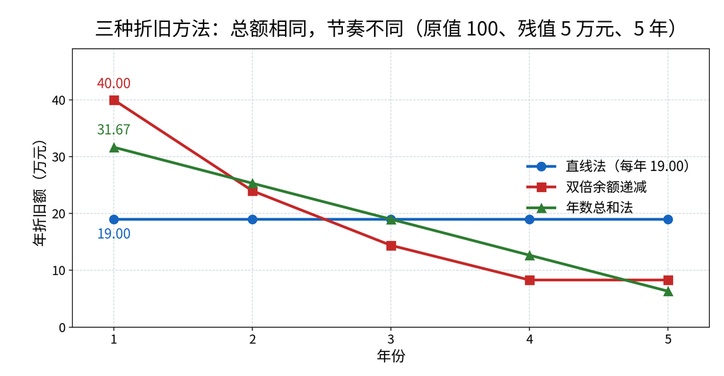

- 判据：总额同为 95 万元、节奏不同——加速折旧把抵税提前，$NPV$ 变大

## 所得税：折旧抵税怎样改变现金流

> 上一页讲折旧的三种算法；这一页把它接进现金流，算出折旧抵税究竟值多少。
- 经营净现金流量（记 $NCF$，单位万元）= 净利润 + 折旧
- 展开：$NCF=(S-C-D)(1-T)+D=(S-C)(1-T)+D\cdot T$
- 折旧 $D$ 不进现金，但 $D\cdot T$ 是抵税额（$T$ 为所得税税率，%）：政府替你承担了 $T$ 比例的折旧
- 算例（万元）：销售收入 $S=750$、经营成本 $C=400$、折旧 $D=150$、税率 $T=25\%$
- 利润总额 $=750-400-150=200$；所得税 $=50$；净利润 $=150$
- 经营净现金流 $=150+150=300$，与 $750-400-50=300$ 一致
- 其中折旧抵税 $=150\times25\%=37.5$ 万元/年，是实实在在的现金
- 推论：加速折旧把抵税提前，$NPV$ 变大——折旧政策本身就是投资激励

**结论：折旧本身不出现金，抵税额 $D\cdot T$ 才是折旧对现金流的全部贡献。**

## 静态投资回收期：公式、判据与基准

> 上一页把现金流与折旧抵税算成净额；从这一页起进入判据，先看最直观的回收期。
- 定义：用项目净收益回收全部投资所需的年数（记 $P_t$，单位年），从建设开始年算起
- 等额净收益特例：$P_t=I/A$，其中 $I$ 为投资额（万元）、$A$ 为年净收益（万元/年）；各年不等时用累计净现金流量插值（下页）
- 判据：$P_t\le P_c$ 可行，$P_c$ 为行业或企业基准回收期（年）
- **优点**是直观、同时反映风险与资金周转；**缺点**是不看时间价值、也不看回本之后的收益。

| 行业 | 基准回收期（年） | 判读 |
| --- | --- | --- |
| 大型钢铁 | 14.3 | 重资产、技术稳定，回本慢 |
| 中型钢铁 | 12.3 | 次之，仍属长周期 |
| 汽车 | 9.0 | 由产线换代周期决定 |
| 家用电器 | 6.8 | 竞争激烈、产品换代快 |
| 日用机械 | 5.1 | 周转快，回收要求急 |

- 基准值随投资结构、成本结构与技术进步速度变化，行业间差三倍不奇怪
- 回收期只适合**初筛**：它回答“多久不亏”，不回答“能赚多少”

**结论：回收期只回答多久不亏，只能用于初筛，不能单独决定取舍。**

## 静态回收期算例：累计值转正那一年

> 上一页给出回收期的公式与基准；这一页用一组数据把它算到底。
- 资料：建设期 2 年，第 3 年投产；净现金流量见表（单位：万元）
- 先把净现金流量逐年累加，再看累计值哪一年由负转正。

| 年份 | 净现金流量 | 累计净现金流量 | 说明 |
| --- | --- | --- | --- |
| 1 | −600 | −600 | 建设期 |
| 2 | −900 | −1500 | 建设期 |
| 3 | 300 | −1200 | 投产 |
| 4 | 500 | −700 | — |
| 5 | 500 | −200 | — |
| 6 | 500 | 300 | 首次转正 |

- 第 6 年累计首次为正，$T=6$（$T$ 为累计净现金流首次为正的年份）；上年累计绝对值 200，当年净现金流 500
- 插值：$P_t=6-1+\dfrac{200}{500}=5.4$ 年
- 若 $P_c=6$ 年则可行，若 $P_c=5$ 年则不可行——基准值决定结论
- 常见错：分子写成 300，或把 $T$ 当成 5，结果整整差一年

**结论：插值的分子是上年累计缺口、分母是当年净现金流，$T$ 取首次转正的年号。**

## 动态投资回收期：折现之后再数年头

- 先把各年净现金流按基准收益率折现，再用累计现值找转正年；公式与静态同构，每项多乘折现系数

$$P_t'=T'-1+\frac{\left|\sum_{t=0}^{T'-1}(CI-CO)_t(1+i_c)^{-t}\right|}{(CI-CO)_{T'}(1+i_c)^{-T'}}$$

- 算例：投资 1000 万元，6 年每年净收益 250 万元，$i_c=10\%$

| 年份 | 净现金流（万元） | 折现系数 | 累计折现值（万元） |
| --- | --- | --- | --- |
| 1 | 250 | 0.9091 | 227.27 |
| 2 | 250 | 0.8264 | 433.88 |
| 3 | 250 | 0.7513 | 621.71 |
| 4 | 250 | 0.6830 | 792.47 |
| 5 | 250 | 0.6209 | 947.70 |

- 第 6 年转正：$P_t'=5+\dfrac{1000-947.70}{141.12}=5.37$ 年；静态 4.00 年

## 净现值 NPV：超额收益的现值

> 上一页的动态回收期只看回本时点；这一页把回本之后的收益也折进来。
- 定义：各年净现金流量按基准收益率折现到第 0 年的代数和（记 $NPV$，单位万元；$i_c$ 为基准收益率，%，$n$ 为计算期年数）

公式

$$NPV=\sum_{t=0}^{n}(CI-CO)_t(1+i_c)^{-t}$$

- 判据：$NPV>0$ 可行；$NPV=0$ 恰好达到基准收益；$NPV<0$ 不可行
- 经济含义：把“按 $i_c$ 本该赚到的钱”扣掉之后，还剩多少现值
- 三条性质：可加（$NPV_{A+B}=NPV_A+NPV_B$）、对折现率敏感、绝对额不便比规模
- 净现值率 $NPVR=NPV/I_p$（$I_p$ 为投资现值，万元）：每元投资创造的超额现值，用于规模不同的比较
- 两个坑要避开：$i_c$ 事后调整可以翻转结论；寿命不同的 $NPV$ 不可直接比。

**结论：$NPV$ 大于 0 意味着扣掉基准收益之后还有剩余，这是最可靠的可行性判据。**

## NPV 算例：一张表算到底

> 上一页给出净现值的定义与判据；这一页用同一组数据把两条算法核对一遍。
- 算例：投资 1000 万元，寿命 6 年，每年净现金流 250 万元，$i_c=10\%$
- 逐年折现累加，或用年金现值系数一次算完，两条路必须对得上

| 年份 | 净现金流（万元） | 折现系数 | 现值（万元） |
| --- | --- | --- | --- |
| 1 | 250 | 0.9091 | 227.27 |
| 2 | 250 | 0.8264 | 206.61 |
| 3 | 250 | 0.7513 | 187.83 |
| 4 | 250 | 0.6830 | 170.75 |
| 5 | 250 | 0.6209 | 155.23 |
| 6 | 250 | 0.5645 | 141.12 |

- 合计现值 1088.82 万元；$NPV=-1000+1088.82=88.82$ 万元
- 快捷算法：$(P/A,10\%,6)=4.3553$，$250\times4.3553=1088.82$，与逐项相加一致
- 结论：除收回投资与 10% 基准收益外，还多赚 88.82 万元现值
- 净现值率 $88.82/1000=8.9\%$：每投入 1 元，多赚 0.089 元

**结论：逐项折现与年金系数必须对上，$NPV$ 为 88.82 万元说明项目值得投。**

## 内部收益率 IRR：让 NPV 归零的利率

- 定义：使 $NPV=0$ 的折现率，经济含义是项目自身能达到的收益率

$$\sum_{t=0}^{n}(CI-CO)_t(1+IRR)^{-t}=0$$

- 判据：$IRR\ge i_c$ 可行；$IRR<i_c$ 不可行
- 求解：先试算两点，再线性插值 $IRR\approx i_1+\dfrac{NPV_1}{NPV_1+|NPV_2|}(i_2-i_1)$
- 算例：$-1000+250(P/A,IRR,6)=0$，即 $(P/A,IRR,6)=4$
- 试算：$i=12\%$ 时 $NPV=+27.85$；$i=13\%$ 时 $NPV=-0.61$
- 插值：$IRR=12\%+\dfrac{27.85}{27.85+0.61}\times1\%=12.98\%$
- 失效情形：现金流多次变号时可能多解或无解，此时改用 $NPV$

## IRR 与 NPV：什么时候会打架

> 上一页把内部收益率算到 12.98%；这一页说明它和净现值在互斥方案上为什么给出相反排序。
- 常规现金流（先负后正、只变号一次）：$NPV$ 随 $i$ 单调下降，$IRR$ 唯一
- 此时两判据一致：同一个 $i_c$ 下，$NPV>0$ 与 $IRR>i_c$ 等价
- 冲突只出现在互斥方案：投资规模不同，或收益的时间分布不同
- 算例（单位：万元，$i_c=10\%$，寿命均 5 年）

| 指标 | 甲方案 | 乙方案 | 乙−甲（差额） |
| --- | --- | --- | --- |
| 初始投资 | 500 | 1500 | 1000 |
| $NPV$ | 258.16 | 319.58 | 61.42 |
| $IRR$／增量 $IRR$ | 28.65% | 18.03% | 12.38%（增量） |

- 反算：$200\times3.7908-500=258.16$；增量 $280\times3.7908-1000=61.42$
- $IRR$ 选甲、$NPV$ 选乙：小项目收益率高，大项目赚的绝对额多
- 差额 $IRR=12.38\%>10\%$，说明追加的 1000 万元本身合算，应选乙

**结论：互斥方案看 $NPV$ 或差额 $IRR$，$IRR$ 只说明这笔投资本身的收益水平。**

## 三指标的关系与选用

> 上一页看到两个指标会打架；这一页把四个指标放进一张表分工。

| 指标 | 考虑时间价值 | 考虑全周期收益 | 可直接比较规模 | 主要缺陷 |
| --- | --- | --- | --- | --- |
| 静态回收期 | 否 | 否 | 否 | 忽视回收期后收益 |
| 动态回收期 | 是 | 否 | 否 | 同上 |
| NPV | 是 | 是 | 否（绝对值） | 折现率选择敏感 |
| IRR | 是 | 是 | 否 | 多解、再投资假设 |
| NPVR | 是 | 是 | 是（相对值） | 需与 NPV 同看 |

- 决策顺序：**先用 NPV 判断可行 → 用 IRR 表达收益水平 → 用回收期评估风险 → 用 NPVR 比较不同规模方案**
- 互斥方案比选：**NPV 最大**优先；规模差异大时用**差额内部收益率**或 NPVR
- 陷阱：IRR 高的项目不一定 NPV 大（小项目高收益率）；回收期短的项目不一定赚钱

**结论：$NPV$ 管取舍、$IRR$ 管表达、回收期管风险、$NPVR$ 管规模。**

## 净年值 NAV：把项目摊成每年一笔

> 上一页的结论是寿命相同可直接比净现值；寿命不同就要先摊平，这一页用净年值。
- 净年值：把 $NPV$ 平摊到寿命期各年，$NAV=NPV(A/P,i_c,n)$，单位万元/年
- 判据：$NAV\ge0$ 可行；与 $NPV$ 同号同结论，只是换了时间单位
- 用途一：寿命不同的方案可直接比，年化之后是同一把尺子
- 用途二：只比费用不比收益时用费用年值 $AC$（设备选型、工艺方案）
- $AC=(P-L(P/F,i,n))(A/P,i,n)+L\cdot i+\bar{C}$，其中 $P$ 为设备原值（万元）、$L$ 为残值（万元）、$\bar{C}$ 为年均运行费（万元/年）
- 算例：设备 60 万元、8 年、残值 6 万元、年运行费 8 万元，$i=10\%$
- $AC=(60-6\times0.4665)\times0.18744+0.6+8=19.32$ 万元/年
- 多方案比 $AC$，小者优；这就是全生命周期成本的年值口径

**结论：$NAV$ 与 $NPV$ 永远同号同结论，跨寿命比较时换成每年一笔再比。**

## 投资利润率与投资利税率：会计口径的粗筛

> 上一页把动态指标摊成年值；这一页补两个会计口径的粗筛指标。
- 投资利润率 $R_p=\dfrac{P_r}{I}\times100\%$，投资利税率 $R_t=\dfrac{P_r+T_s}{I}\times100\%$
- 记号：$P_r$ 为年利润总额（万元），$T_s$ 为年销售税金及附加（万元），$I$ 为总投资（万元）
- 总投资 = 建设投资 + 建设期利息 + 流动资金；分子取**正常年份**的年值
- 判据：不低于行业平均（或基准）值则可行
- 算例：$I=1000$、$P_r=200$、$T_s=45$ 万元 → $R_p=200\div1000=20\%$、$R_t=(200+45)\div1000=24.5\%$
- 它适用于项目初筛与上报统计；不适用于收益前低后高的项目，也不适用于寿命不同的方案比选。
- 缺陷：拿一年代表全过程，不折现、不含时间分布，容易把慢热项目判死

**结论：投资利润率只适合初筛与上报，做决策仍要回到 $NPV$。**

## 设备更新：经济寿命怎么定

- 经济寿命：使**等值年成本**最小的使用年限，不是“能用到坏”的年数
- 年成本两块：资本回收成本越用越小，年均运行成本越用越大
- $AC_n=[P-L_n(P/F,i,n)](A/P,i,n)+L_n i+\bar{C}_n$，$\bar{C}_n$ 为年均运行成本
- 算例：$P=30000$ 元、$i=10\%$，各年成本见下表（元；四舍五入，行和可能差 1 元）

| 使用年限 | 资本回收成本 | 年均运行成本 | 年均总成本 |
| --- | --- | --- | --- |
| 1 | 14100 | 3000 | 17100 |
| 2 | 11643 | 4191 | 15833 |
| 3 | 10042 | 5492 | 15535 |
| 4 | 8771 | 6895 | 15666 |
| 5 | 7723 | 8386 | 16109 |

- 第 3 年总成本最低，经济寿命 3 年；用到第 5 年每年多花 574 元
- 更新判据：旧设备年成本 14813 元高于新设备 10674 元，应更新
- 注意：旧设备的当前残值是**机会成本**，不是账面净值

## 代码复算（八）：设备更新的经济寿命

> 上一页比两个方案；这一页让代码把“用几年最合算”逐年算出来。

```python
P, i = 30000, 0.10
L   = [21000, 15000, 10000, 6000, 3000]      # 第 1—5 年末残值（元）
run = [3000, 4191, 5492, 6895, 8386]         # 年均运行成本（元）
for n in range(1, 6):
    ap = i/(1-(1+i)**-n)                      # 资本回收系数
    acr = (P - L[n-1]*(1+i)**-n)*ap + L[n-1]*i
    print(n, round(acr), run[n-1], round(acr + run[n-1]))
```

```
1 14100 3000 17100
2 11643 4191 15834
3 10042 5492 15534
4 8771 6895 15666
5 7723 8386 16109
```

**结论：经济寿命不是猜出来的，是把“资本回收＋运行”两条曲线相加，找最低点。**

## 多方案比选：寿命相同与寿命不同

> 上一页定了单台设备的经济寿命；这一页把它扩展到多个方案的选择。
- 三类关系：独立方案（$NPV\ge0$ 就上）、互斥方案（多选一）、混合方案
- 寿命相同互斥：$NPV$ 最大者优；规模差距大时再用差额 $IRR$ 复核
- 寿命不同：$NPV$ 不可直接比，改用 $NAV$（净年值，万元/年），或按最小公倍数统一计算期
- 算例（万元，$i_c=10\%$）：A 线投资 1000、年净收益 300、寿命 6 年；B 线 2000、350、12 年

| 指标 | A 线 | B 线 | 判读 |
| --- | --- | --- | --- |
| $NPV$（各自寿命） | 306.58 | 384.79 | B 大 |
| $NAV$ | 70.39 | 56.47 | A 大 |
| 12 年口径 $NPV$ | 479.63 | 384.79 | A 大 |

- $NPV$ 大不等于优：B 的 12 年总现值多，摊到每年只有 56 万元
- 统一到 12 年后 A 优，与 $NAV$ 结论一致——两种法子互为验证
- 规则：先统一时间尺度，再比金额；寿命不同时绝不直接比 $NPV$

**结论：先统一时间尺度再比金额，寿命不同时绝不直接比 $NPV$。**

## 案例：一条智能装配线的投资决策

> 前面把各个判据分别讲完；这一页用一条智能装配线把整套流程串起来。
- 投资：设备及安装 900 万元 + 流动资金 100 万元，均在第 0 年投入，合计 1000 万元
- 寿命 6 年、直线折旧、残值 0；年销售收入 750 万元、年经营成本 400 万元、所得税 25%
- 年折旧 150 万元；利润总额 200 万元；净利润 150 万元；经营净现金流 300 万元；第 6 年回收流动资金 100 万元（$i_c=10\%$）

| 年份 | 净现金流量 | 折现系数 | 现值 |
| --- | --- | --- | --- |
| 1 | 300 | 0.9091 | 272.73 |
| 2 | 300 | 0.8264 | 247.93 |
| 3 | 300 | 0.7513 | 225.39 |
| 4 | 300 | 0.6830 | 204.90 |
| 5 | 300 | 0.6209 | 186.28 |
| 6 | 400 | 0.5645 | 225.79 |

- 合计现值 1363.03；$NPV=363.03$ 万元，$IRR=21.21\%$；$P_t=3.33$ 年、$P_t'=4.26$ 年

**结论：现金流表是根，五个指标只是同一张表的不同读法。**

## 企业真题演算（一）：80 万元检测线逐项折现

> 上一页用智能装配线把五个指标串完；这一页回到第〇部分的真题，按同一张现金流量表把 80 万元算到底。
- 口径：第 0 年投 80 万元；第 1—10 年每年净节约 32 万元（税后经营净现金流）；寿命 10 年、残值 0；$i_c=8\%$；折旧 8 万元/年是账面成本、不进现金流量表

| 年 | 系数 $1.08^{-t}$ | 现值（万元） | 累计（万元） | 年 | 系数 $1.08^{-t}$ | 现值（万元） | 累计（万元） |
| --- | --- | --- | --- | --- | --- | --- | --- |
| 1 | 0.9259 | 29.63 | 29.63 | 6 | 0.6302 | 20.17 | 147.93 |
| 2 | 0.8573 | 27.43 | 57.06 | 7 | 0.5835 | 18.67 | 166.60 |
| 3 | 0.7938 | 25.40 | 82.46 | 8 | 0.5403 | 17.29 | 183.89 |
| 4 | 0.7350 | 23.52 | 105.98 | 9 | 0.5002 | 16.01 | 199.90 |
| 5 | 0.6806 | 21.78 | 127.76 | 10 | 0.4632 | 14.82 | 214.72 |

- 复核与回收期：$\sum 1.08^{-t}=6.7101$、$32\times6.7101=214.72$ 与累加一致；$NPV=134.72$、$NPVR=1.68$；静态 $80\div32=2.50$ 年、动态 $2+(80-57.06)\div25.40=2.90$ 年

**结论：十年收益现值 214.72 万元，扣投资仍多 134.72 万元——每投 1 元多赚 1.68 元，2.5 年回本、2.9 年连本带息。**

## 企业真题演算（二）：IRR 试算与插值

> 上一页算平了现值；这一页找让 $NPV=0$ 的那个折现率。
- 令 $NPV=0$：$-80+32(P/A,IRR,10)=0$，即 $(P/A,IRR,10)=80\div32=2.5$
- 系数用 $(P/A,i,10)=(1-(1+i)^{-10})\div i$：$1.38^{-10}=0.0399$、$1.39^{-10}=0.0371$

| 步骤 | 算式 | 结果 |
| --- | --- | --- |
| 代入 | $-80+32(P/A,IRR,10)=0$ | $(P/A,IRR,10)=2.5$ |
| 试算 38% | $(1-1.38^{-10})\div0.38$ | $2.5265$；$NPV=+0.85$ |
| 试算 39% | $(1-1.39^{-10})\div0.39$ | $2.4689$；$NPV=-1.00$ |
| 插值 | $38\%+0.85\div(0.85+1.00)\times1\%$ | $IRR=38.46\%$ |
| 校验 | 精确解 $38.45\%$（二分法） | 误差 0.01 个百分点 |

- 两点异号才能插值：38% 时 $NPV>0$、39% 时 $NPV<0$，目标值 2.5 被夹在 2.5265 与 2.4689 之间
- 判据：$IRR=38.46\%\gg i_c=8\%$，折现率要升到 38.45% 才使 $NPV=0$

**结论：$IRR$ 约 38.5%，是基准收益率 8% 的 4.8 倍，方案在收益端留了很厚的余量。**

## 企业真题演算（三）：±20% 敏感性与保本线

> 上一页把收益率算出来；这一页把两个关键变量各动 ±20%，看结论会不会翻。
- 单因素法：每次只动一个变量、其余不变；基准情景 $NPV=134.72$ 万元

| 变量 | 变动 | $NPV$（万元） | 判读 |
| --- | --- | --- | --- |
| 年节约 | −20%（25.6 万元） | 91.78 | 仍可行 |
| 年节约 | +20%（38.4 万元） | 177.67 | 更可行 |
| 折现率 | 8% 升到 12% | 100.81 | 仍可行 |
| 折现率 | 8% 升到 20% | 54.16 | 仍可行 |

- 算式：$25.6\times6.7101-80=91.78$；$32\times5.6502-80=100.81$；$32\times4.1925-80=54.16$
- 保本线：年节约 $80\div6.7101=11.92$ 万元（可降 62.7%）；折现率上限 38.45%
- 判读：四个情景 $NPV$ 全为正，结论不翻转；最敏感的不是数值而是 32 万元的口径

**结论：±20% 两头都不翻盘，风险不在收益端；要盯的是 32 万元里有没有算进 4% 漏检率的质量损失。**

## 质量成本：四类构成

> 上一页把投资决策的算法走通；这一页转向质量——质量本身也是一笔可算的成本。
- **质量成本**：为确保和保证满意的质量而发生的费用，以及没有达到满意质量所造成的损失

| 类别 | 定义 | 例子 |
| --- | --- | --- |
| 预防成本 | 防止不合格发生 | 质量策划、培训、FMEA、供应商辅导 |
| 鉴定成本 | 评定产品是否符合要求 | 进货检验、过程检验、试验、检测设备 |
| 内部损失 | 交付前发现的不合格 | 废品、返工、停机、复检 |
| 外部损失 | 交付后发现的不合格 | 索赔、退货、召回、诉讼、信誉损失 |

- 经验法则（1-10-100）：预防 1 元 ≈ 事后纠正 10 元 ≈ 外部失败 100 元；质量成本率＝质量成本÷销售收入
- 最优质量水平：现代观主张逼近高合格率，在线检测把外部损失前移
- 算例（万元）：$20+30+50+80=180$，外部损失占比 $80\div180=44.4\%$
- 改善：预防加 10、内部减 10、外部减 30 → $180+10-10-30=150$，降幅 $(180-150)\div180=16.7\%$

**结论：预防 1 元能省下 10 元纠正、100 元外部损失，质量与成本不是对立面。**

## 全生命周期成本 LCC

> 上一页把质量成本分成四类；这一页把视野拉长到设备的整个寿命。
- **全生命周期成本（LCC）**：产品／设备从购置、使用、维护到处置的**全部成本现值**；含购置、运行、维护、停机损失与处置／残值
- 核心：**买得贵可能用得便宜**——多花的购置费要靠运行维护省回来

公式

$$LCC=C_{购置}+\sum_{t=1}^{n}\frac{C_{运行,t}+C_{维护,t}}{(1+i)^t}-\frac{残值}{(1+i)^n}$$

**算例**：$i=8\%$，寿命 6 年，运行维护费按年计（单位：万元）

| 方案 | 购置 | 年运行 | 年维护 | 残值 | LCC |
| --- | --- | --- | --- | --- | --- |
| 设备 A | 100 | 30 | 10 | 10 | **278.6** |
| 设备 B | 150 | 20 | 8 | 20 | **266.8** |

- $LCC_A=100+40\times4.6229-10\times0.6302=278.6$；$LCC_B=150+28\times4.6229-20\times0.6302=266.8$，**B 省 11.8 万元**
- 最易漏计的是停机损失、能耗耗材、备件与培训；寿命不等的方案用等年值 $EUAC$ 比较。

**结论：全生命周期成本比较的是全部成本现值，购置价最低不等于总成本最低。**

## 代码复算（七）：LCC 与质量成本

> 成本不只在采购那一刻；这一页用代码把全生命周期与质量成本算成现值和占比。

```python
i, n = 0.08, 6
pa = (1-(1+i)**-n)/i          # 年金现值系数
pf = (1+i)**-n                # 复利现值系数
lcc_a = 100 + (30+10)*pa - 10*pf
lcc_b = 150 + (20+8)*pa  - 20*pf
print("P/A", round(pa,4), "P/F", round(pf,4))
print("LCC_A", round(lcc_a,2), "LCC_B", round(lcc_b,2), "差", round(lcc_a-lcc_b,2))

qc = {"预防": 20, "鉴定": 30, "内部损失": 50, "外部损失": 80}
total = sum(qc.values())
print("质量成本合计", total, "外损占比", round(qc["外部损失"]/total, 3))
print("改善后", total+10-10-30, "降幅", round((total-(total-30))/total, 3))
```

```
P/A 4.6229 P/F 0.6302
LCC_A 278.61 LCC_B 266.84 差 11.78
质量成本合计 180 外损占比 0.444
改善后 150 降幅 0.167
```

- LCC：A 278.61、B 266.84 万元，B 贵 50 万元购置费却省 11.78 万元——买得贵可能用得便宜
- 质量成本：合计 180 万元、外部损失占 44.4%；改善后 150 万元、降幅 16.7%
- 两个模型共用一个思想：把“以后的钱”折成“今天的钱”，再相加比较

**结论：LCC 把使用期折进来，质量成本把损失折成占比——两者都是“别只看采购价”的算法表达。**

## 本部分小结：判据、顺序与纪律

> 本部分从资金时间价值一路走到全生命周期成本；这一页把判据、顺序与纪律收成一张表。
- 一条主线：所有指标都从**现金流量表**出发，先画对现金流，再谈选哪个判据
- 静态类（$P_t$、投资利润率、投资利税率）：快而粗，用于初筛与上报
- 动态类（$NPV$、$IRR$、$NAV$、$P_t'$）：计入时间价值，用于决策与比选

| 指标 | 判据 | 最适合的场合 | 主要陷阱 |
| --- | --- | --- | --- |
| $P_t$ | $P_t\le P_c$ | 风险筛查 | 忽视回本后的收益 |
| $NPV$ | $NPV\ge0$ | 单方案取舍、互斥比选 | 折现率主观可调 |
| $IRR$ | $IRR\ge i_c$ | 表达收益水平 | 多解、再投资假设 |
| $NAV$ | $NAV\ge0$ | 寿命不同比选 | 前提是折现率相同 |

- 一条顺序：先判可行（$NPV\ge0$），再比优劣（$NAV$ 或差额 $IRR$），最后看风险（$P_t$）
- 一条纪律：折现率、折旧方法、税率三项假设必须写进评价报告，否则数字无法复核
- 一句话收束：评价不是算命，是把假设摆到桌面上，让决策者知道自己赌的是什么。

**结论：先把假设写清、再把现金流画对，指标才有意义。**

## 推导留给 AI：技术经济评价（汇总）

> 本部分收在四个待答的问题上，它们都指向假设与边界。
- 折现率取 8% 还是 12%，为什么能把同一个项目从“可行”变成“不可行”？折现率由谁决定？
- NPV 与 IRR 在互斥方案比选中结论冲突时，应该信哪个？为什么？
- 质量成本的“最优区间”在理论上存在，为什么企业实际很难找到？
- LCC 要不要把安全与环境的外部成本计入？计入了，谁受益、谁付费？

**结论：四个问题的答案都不在公式里，而在折现率、规模与外部性这些前提的选择上。**

# 第四部分 · 成本驱动的设计与人力资源

- 成本与质量、安全的平衡：不能为降本牺牲底线；成本驱动设计六原则与目标成本分解
- 智能制造人才需求、岗位能力模型（冰山模型）
- 人机协作对岗位的影响；绩效考核与激励理论
- 本部分落点：成本与安全的取舍、人的价值能否折算、分配公平
- **承上**：第三部分把方案折成现金流、判断该不该投；本部分把成本推回设计阶段，再把账落到人身上。

## 成本与质量、安全的平衡

> 第四部分把成本从账推到设计与人的安排；这一页先回答降本有没有不能碰的底线。
- 降本有三条红线：**质量红线、安全红线、环境红线**
- 三对典型冲突：

| 冲突 | 短期“降本”做法 | 长期代价 |
| --- | --- | --- |
| 降本 vs 质量 | 换便宜材料、减检验 | 外部损失、召回、信誉崩塌 |
| 降本 vs 安全 | 省防护装置、压缩培训 | 事故赔偿、刑责、停产 |
| 降本 vs 效率 | 减维护、超负荷运行 | 停机增加、设备寿命缩短 |

- 判据：**降本必须看“总成本”与“风险成本”，不能只看采购价**
- 方法论：把安全与环境成本纳入全生命周期成本（LCC）与质量成本，用同一张账比较

**结论：降本要看总成本与风险成本，不能只看采购价——省在明处的钱，常常赔在暗处。**

## 成本驱动的设计：把成本关在设计阶段

> 上一页立了三条红线；这一页回答成本怎么在设计阶段就被关住。
- **是什么**：在设计阶段就把成本作为约束，以最小化全生命周期成本为目标——不是量产后砍价
- **为什么**：设计锁定 70% 以上的成本；量产后只能做边际改善，越改越贵
- **怎么判断**：评审双问——功能达标吗、成本达标吗；两问都过才放行
- 三个转变：目标前置（先定允许成本）、并行设计（设计、工艺、采购、成本同台）、方案比选（成本模型＋仿真快速迭代）
- 四项输出：成本估算书、目标成本分解表、降本清单、供应商协同清单
- 与目标成本法的关系：目标成本给“上限”，面向成本的设计（DFC）回答“怎么达到上限”
- 红线：不以可靠性、安全性、可维修性换降本

**结论：成本是设计出来的，不是量产后砍出来的；设计阶段锁定上限，量产后只能做边际改善。**

## 成本驱动设计的六条原则

> 上一页讲成本在设计阶段被锁定；这一页把它拆成六条可操作的原则。

| 原则 | 做法 | 检查问题 |
| --- | --- | --- |
| 成本意识培养 | 让设计团队理解每个决策的成本影响 | 这个结构能不能少一道工序？ |
| 成本估算前置 | 设计早期就估算成本 | 方案 A/B 的成本差多少？ |
| 价值工程 | 去掉过剩功能与过度设计 | 这个功能顾客愿意付钱吗？ |
| 材料与成本效益 | 选全生命周期成本最优的材料 | 便宜材料会不会增加维护？ |
| 生产与加工效率 | 选合适的工艺与加工方法 | 能不能用标准件、少装夹？ |
| 循环设计 | 考虑生产、使用、维护、废弃 | 报废后能不能回收？ |

- 设计阶段的降本杠杆排序：**减少零件数 > 通用化/平台化 > 工艺简化 > 材料替代**
- 与第 3 讲 ECRS（取消、合并、重排、简化）的关系：取消（零件）、合并（工序）、重排（装配顺序）、简化（结构）

**结论：六条原则的落点是减少零件数与通用化——越早介入，降本杠杆越大。**

## 成本驱动设计实例：目标成本分解

> 上一页给出六条原则；这一页用算例把目标成本从“总包干”拆到模块。
- 目标成本不是“总包干”，要**逐层分解到部件与工序**，并锁定责任

**算例**：新产品允许成本 425 元／件，按功能模块分解：

| 模块 | 当前估算（元） | 目标（元） | 降幅 | 主要手段 |
| --- | --- | --- | --- | --- |
| 结构件 | 120 | 105 | 12.5% | 减少零件数、冲压替代机加工 |
| 传动件 | 150 | 140 | 6.7% | 标准件替代非标件 |
| 电控 | 110 | 100 | 9.1% | 集成化、减少线束 |
| 装配 | 80 | 80 | 0% | 工艺已较优 |
| **合计** | **460** | **425** | **7.6%** | — |

- 降幅＝（当前−目标）÷当前：$15\div120=12.5\%$、$10\div150=6.7\%$、$10\div110=9.1\%$、$0\div80=0\%$；合计 $35\div460=7.6\%$，即降 35 元/件
- 分解后每个模块都有“目标—手段—责任人”，才能进入设计评审
- 评审判据：目标成本是否达成、达成手段是否损害功能与可靠性

**结论：目标成本要分解到可设计、可采购、可考核的粒度，每个模块都带目标、手段与责任人。**

## 价值工程：把功能与成本放在一张表上

- **是什么**：以最低的全生命周期成本可靠实现必要功能——功能是分子、成本是分母
- **为什么**：功能与成本脱节时，贵的部件未必有用，便宜的部件可能致命
- **怎么判断**：$V=F/C$，$V<1$ 优先改进；$V$ 是相对值，还要问顾客愿不愿付钱

| 序 | 途径与做法 | 例子 |
| --- | --- | --- |
| ① | 功能↑、成本↓：原理创新 | 一体化压铸替代多件焊接 |
| ② | 功能↑、成本不变：补必要功能 | 加装防错，减少返工 |
| ③ | 功能不变、成本↓：去过剩设计 | 去掉客户不买单的装饰 |
| ④ | 功能↓、成本↓↓：分级降配 | 经济型配置 |
| ⑤ | 功能↑↑、成本↑：价值更高 | 高端机型 |

- 工作程序：信息 → 功能定义 → 功能评价 → 方案创造 → 方案评价 → 实施
- 顺序不能反：先问“顾客愿意为这个功能付钱吗”，再问“能否更便宜实现”
- 误区：把 VE 做成“砍功能”；把成本系数当唯一依据，忽略功能必要性

## 成本与创新：哪些钱不能省

> 上一页讲怎样去掉过剩功能；这一页反过来回答哪些钱不能省。
- 三类成本待遇不同：结构性成本该降、投入性成本有最优区间、损失性成本该消灭
- 质量成本曲线就是证据：预防与鉴定投入不足，损失成本会成倍补回来

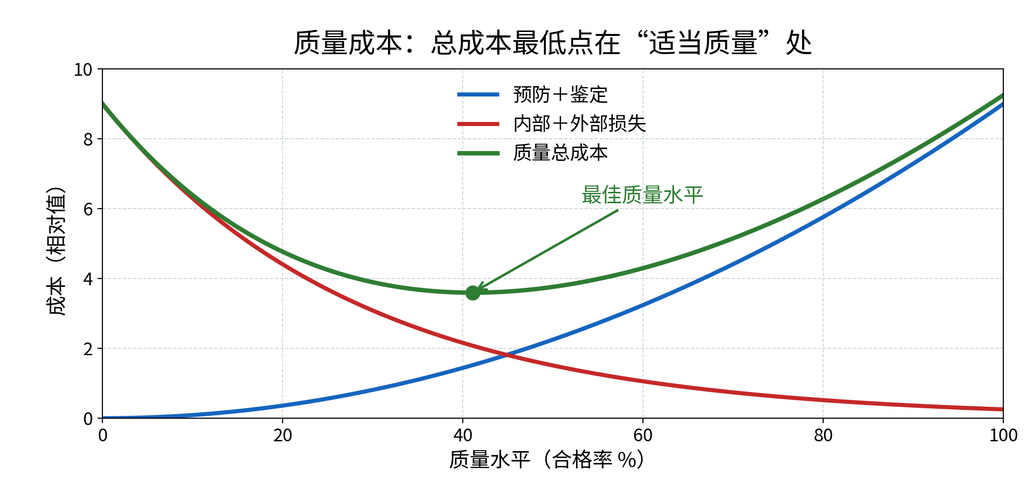

- 战略层：成本领先、差异化、集中化是三条路（波特）；平台化／模块化摊薄研发与采购
- 红线：降本不削减验证、认证、试验与安全余量；同时盯研发费用率与新品收入占比

**结论：投入性成本有最优区间，验证、认证、试验与安全余量不能挤；省在当年的钱常常输在三年后。**

## 智能制造降成本：四条路径与一个前提

> 上一页划出不能省的钱；这一页讲智能制造靠四条路径把该省的钱省下来。
- 减少浪费：用价值流图（VSM）找等待、搬运、库存、不良，先消浪费再自动化
- 提高效率：设备综合效率（OEE）分解为时间开动率、性能开动率、合格品率，先修瓶颈
- 增加柔性：快速换模（SMED）缩短换型、混线生产，用范围经济替代批量经济
- 保住质量：一次合格率提高，返工、检验、售后成本同向下降
- 数据显性化：能耗、工时、在制库存实时可见，隐性成本变显性
- 前提：数字化本身有成本（软件、传感器、运维、培训），先算投入产出
- 反例：流程不改只上系统，等于把手工浪费自动化，成本反而更高

**结论：降本先削浪费，数字化只是让隐性成本显性化；流程不改只上系统，等于把浪费自动化。**

## 人力资源：从“管人”到“经营人”

> 成本侧讲完；这一页转到人，先立人力资源的整体框架。
- 定义：通过**获取、开发、保持、使用**四类活动，实现人岗匹配与组织目标
- 三个必答题：要多少人、要什么人、怎么让人愿意干
- 六大模块是一条链，上一环的输出是下一环的输入：

| 模块 | 回答的问题 | 主要输出 |
| --- | --- | --- |
| 规划 | 要多少人、什么结构 | 定员与人才计划 |
| 招聘配置 | 人从哪来、怎么选 | 岗位说明书、录用 |
| 培训开发 | 能力怎么补 | 培训体系、技能矩阵 |
| 绩效管理 | 干得怎么样 | 指标、评价与改进 |
| 薪酬福利 | 怎么付、付多少 | 薪酬结构与激励 |
| 劳动关系 | 边界在哪、怎么处理 | 合同、制度、争议 |

- 三支柱：人力资源业务伙伴（HRBP）贴近业务、专家中心（COE）出方案、共享服务中心（SSC）做共享服务
- 三支柱与六模块不是替代关系：模块是职能，三支柱是分工方式
- 与工业工程的接口：标准工时 → 定员 → 人工成本 → 报价

**结论：六个模块是一条链，人力资源的第一性问题是“人效”，不是“人数”。**

## 智能制造人才需求：结构在变

> 上一页立起六大模块的框架；这一页看智能制造把人才需求的结构改成什么样。
- 智能制造不是“少用人”，而是**改变人的结构**：
  - 直接操作岗位减少，设备监控、调试维护、数据分析岗位增加
  - 单一技能岗位减少，**复合型岗位**（机械 + 电气 + 软件 + 管理）增加
  - 经验型岗位向**知识型、学习型**岗位转变
- 三类紧缺能力：

| 能力 | 内容 | 典型岗位 |
| --- | --- | --- |
| 数字素养 | 数据读取、建模、算法应用 | 数据分析、智能运维 |
| 系统思维 | 懂工艺、懂设备、懂信息流 | 系统集成、产线规划 |
| 协作与沟通 | 跨部门、跨专业、与人机协作 | 项目管理、现场改善 |

- 对学生的要求：**机械为本、智能为翼**——会画图、会工艺，也会用数据说话
- 提醒：岗位结构变化伴随**转岗与再培训**，这是企业与社会都要承担的成本

**结论：智能制造不是少用人，而是换人——结构向复合型、知识型上移，转岗与再培训是要计入的成本。**

## 工作分析：岗位信息的系统采集

> 上一页讲人才结构在变；这一页回到岗位，先把岗位信息采清楚。
- 工作分析回答五问：做什么、怎么做、在哪做、谁来做、需要什么条件
- 五种方法按岗位选，没有一种通吃：

| 方法 | 适用与优点 | 局限 |
| --- | --- | --- |
| 观察法 | 重复性操作岗；真实可计时 | 看不到思考过程 |
| 访谈法 | 管理技术岗；可追问细节 | 耗时、易被引导 |
| 问卷法 | 岗位多、地域散；覆盖广 | 回收质量难控 |
| 日志法 | 工作不规律；还原时间分布 | 记录负担重 |
| 关键事件法 | 绩效差异大；指向行为标准 | 样本少、偏极端 |

- 三份输出：岗位说明书、任职资格、岗位评价要素
- 方法组合用：先访谈定框架，再用观察与日志校核时间
- 分析结果要更新：工艺变了、组织变了，岗位说明书就要跟着改
- 与工业工程（IE）的连接：职责来自流程与作业标准，标准工时决定岗位负荷

**结论：工作分析的验收标准是让陌生人看完就知道“这活儿怎么干才算干好”；职责来自流程，岗位负荷来自标准工时。**

## 岗位说明书与任职资格：写到可验证

- 岗位说明书七块：岗位标识、职责、权限、工作关系、绩效标准、环境、任职资格
- 职责写法：动词开头、一项一句、按重要性排序，5～8 项为宜
- 任职资格四要素：学历专业、经验年限、知识技能、素质
- 可验证：把“责任心强”换成“能独立处理 3 类设备报警并记录”
- 常见错误：抄模板、职责口号化、漏跨部门接口、只写做什么不写做到什么程度

[figure not shown]

- 一份文件四处用：招聘筛选、培训需求、绩效考核、岗位评价

## 岗位能力模型：冰山模型

- **胜任力模型**：用一组可观察、可测量的能力来描述“胜任某岗位需要什么”
- 冰山模型分两层：水面以上可见可测，水面以下难改变、决定长期绩效

| 层次 | 内容 | 特点 | 管理含义 |
| --- | --- | --- | --- |
| 水面以上 | 知识、技能 | 可见、可测、可培训 | 招聘与培训的重点 |
| 水面以下 | 社会角色、自我概念、特质 | 不可见、难改变 | 选人比培训更有效 |

- 招聘启示：知识技能可培训，**动机与特质很难培训**——关键岗位要“选对人”

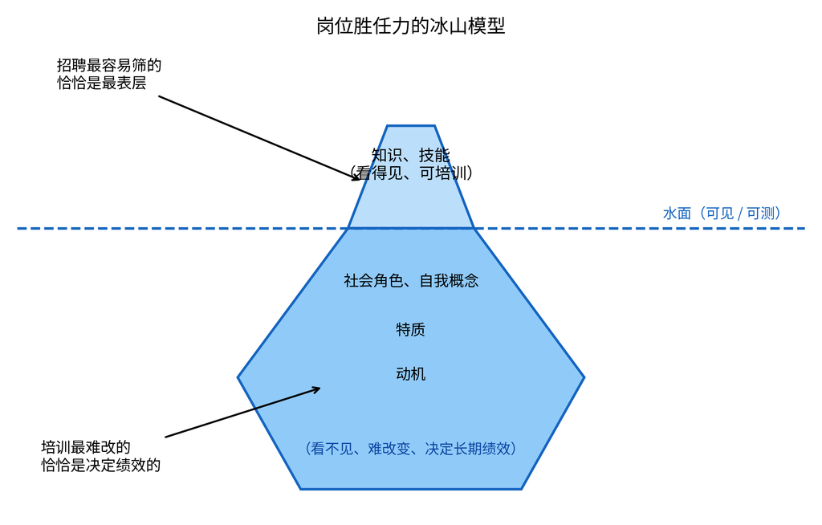

## 岗位能力模型：三类能力与岗位对照

> 上一页把能力分成水上与水下；这一页换一个维度，把能力分成可分级的三类。
- 能力模型通常分三层：**专业能力 + 方法能力 + 社会能力**

| 能力层 | 内容 | 智能制造岗位例子 |
| --- | --- | --- |
| 专业能力 | 本专业的知识与技能 | 机械设计、PLC（可编程逻辑控制器）编程、工艺编制 |
| 方法能力 | 分析问题、学习、创新 | 用 8D（八步问题解决法）解决问题、用数据建模 |
| 社会能力 | 沟通、协作、责任、伦理 | 跨部门协作、安全责任、客户沟通 |

- 岗位能力模型的构建步骤：
1. 明确岗位职责与绩效标准
2. 访谈绩优者与一般者，找**行为差异**
3. 提炼能力项并分级（如 1～5 级）
4. 用行为锚定描述每一级
5. 用于招聘、培训、绩效与晋升
- 常见误区：把“学历、工龄、证书”当能力；能力项太多（超过 10 项）无法落地

**结论：能力模型抓的是绩优者与一般者的行为差异，不是词库；能力项控制在 10 项以内并用行为锚定分级。**

## 人机协作对岗位的影响

> 上一页讲岗位需要什么能力；这一页看机器进入岗位后任务怎么重新分配。
- 人机协作不是“人 vs 机器”，而是**任务重新分配**：

| 效应 | 机制 | 例子 |
| --- | --- | --- |
| 替代效应 | 机器完成可标准化的任务 | 焊接、搬运、重复装配 |
| 互补效应 | 机器增强人的能力 | 外骨骼、增强现实（AR）装配指导、协作机器人 |
| 创造效应 | 新任务与新岗位出现 | 机器人运维、数据标注、算法监控 |

- 岗位变化的三个层次：**任务变 → 岗位变 → 组织变**
- 关键判断：被替代的是**任务**，不一定是**岗位**；人的价值转向判断、异常处理、关系与责任
- 对管理的要求：重新设计工作内容（工作扩大化、丰富化），提供转岗培训
- 对个人的要求：**可迁移能力**（学习能力、系统思维、沟通）比单一技能更保值

**结论：被替代的是任务而不是整个岗位，人的价值转向判断、异常处理与关系责任；可迁移能力比单一技能更保值。**

## 人力资源规划：先算需求，再谈招聘

> 上一页讲人机协作改变岗位；这一页回答最实际的问题：要多少人、什么时候要。
- 三步：需求预测 → 供给预测 → 缺口平衡；把“缺人”变成“缺几个、什么时候缺”
- 需求预测四法：工作负荷法、趋势外推、技能清单、德尔菲法

公式

$$N=\frac{Q\cdot t}{H\cdot a\cdot e}$$

- $N$ 定员（人）、$Q$ 年任务量（件／年）、$t$ 单件工时（h／件）、$H$ 年制度工时（h／人·年）、$a$ 出勤率（%）、$e$ 定额完成率（%）
- 算例：年任务 12 万件、单件 0.5 h、年制度工时 2000 h、出勤率 95%、定额完成率 110%
- 代入 $N=60000/(2000\times0.95\times1.1)=28.7$，向上取整为 29 人
- 供给：内部晋升轮岗与继任 ＋ 外部招聘、外包、劳务派遣（有合规边界）
- 缺口对策排序：提效 → 加班（受 36 h 上限约束）→ 培训转岗 → 招聘 → 外包

**结论：规划的产出是“缺几个、什么时候缺”，不是“要人清单”；先提效再加人。**

## 招聘与甄选：渠道选对，流程走严

> 上一页把要几个人算清楚；这一页讲人从哪里来、怎么选。
- 流程八步：需求审批 → 岗位说明书 → 渠道发布 → 简历初筛 → 笔试与技能测试 → 结构化面试 → 背调体检 → 录用入职
- 渠道没有好坏，只有匹配：

| 渠道 | 优势 | 局限与适用 |
| --- | --- | --- |
| 校园招聘 | 可塑性强、成本低 | 上手慢，适合储备岗 |
| 社会招聘 | 上手快、经验对口 | 成本高，适合成熟业务 |
| 内部竞聘 | 激励强、磨合成本低 | 来源有限，适合管理岗 |
| 员工内推 | 匹配度高、到岗快 | 易成小圈子，适合骨干 |
| 猎头 | 触达高端与稀缺人才 | 费用高，适合高管 |

- 效度经验排序：工作样本 ＞ 结构化面试 ＞ 认知能力测试 ＞ 非结构化面试 ＞ 只看简历
- 结构化面试三要素：同一套问题、统一评分锚点、多名面试官独立打分
- 合法边界：不得询问婚育、不得设歧视性条件（妇女权益保障法、就业促进法）

**结论：渠道没有好坏只有匹配，甄选用效度高的方法——工作样本与结构化面试比只看简历可靠。**

## 培训与开发：三级体系与四级评估

> 上一页把人招进来；这一页讲怎么把人的能力补到岗位要求。
- 三级培训：厂级（制度、安全、质量方针）→ 车间级（工艺、设备、区域风险）→ 班组级（岗位操作、师徒带教）
- 与第 4 讲衔接：新员工三级安全教育是法定动作，一般行业不少于 24 学时
- 培训四步：需求分析（岗位与能力差距）→ 计划 → 实施 → 效果评估
- 柯氏四级评估：多数企业只做到第一层，所以“培训效果好、绩效没变化”

| 层级 | 评什么 | 怎么测 |
| --- | --- | --- |
| 反应 | 学员满不满意 | 课后问卷 |
| 学习 | 知识技能会不会 | 考试、实操考核 |
| 行为 | 回到岗位做不做 | 现场观察、抽查 |
| 结果 | 绩效有没有改善 | 不良率、停机、事故 |

- 技能矩阵：一岗多能、顶岗率、关键岗位至少 2 人会
- 常被忽略：培训要与任职资格、晋升、薪酬挂钩，否则学不学一个样

**结论：培训要落到行为与结果两层，并与任职资格、晋升、薪酬挂钩；只发问卷就会“效果好、绩效没变化”。**

## 绩效管理：一个循环，三处取数

- 绩效管理是循环：目标设定 → 过程辅导 → 评价 → 反馈面谈 → 改进；考核只是第三环
- 指标三来源：战略解码（BSC 四维）、岗位职责（KPI）、流程与项目（OKR）
- 三个工具的定位不同，不是互相替代：

| 工具 | 定位 | 适用 |
| --- | --- | --- |
| MBO | 上下级共同定目标、按结果评价 | 通用、职能岗 |
| KPI | 守住必须守住的底线 | 稳定业务、职能岗 |
| OKR | 攻下需要跳一跳的高点 | 研发、创新、项目 |
| BSC | 把战略翻译成四个维度 | 组织与部门整体 |

- 目标值设三档：保底、目标、挑战；权重之和为 100%
- 计分示例：结果指标 70% ＋ 过程指标 30%，安全与质量设否决项
- 数据来源：MES、ERP、QMS 自动取数，减少人工填报与扯皮
- 一句：绩效管理的目的不是“分钱”，是让目标对齐、让问题暴露

## 绩效考核的六个误区与四种改进

> 上一页给出考核的正确结构；这一页讲设计错了会出什么病、怎么改。
- 误区几乎都来自设计，不是来自员工品德：

| 误区 | 表现与后果 | 改进 |
| --- | --- | --- |
| 指标不可控 | 考不可控项，逼出认命与造假 | 只考可控项 |
| 唯结果论 | 抢产、瞒报、牺牲质量 | 结果＋过程 |
| 近期效应 | 期末冲量、寅吃卯粮 | 滚动 3 个月 |
| 趋中与轮流 | 人人 85 分，激励失效 | 考核者校准会 |
| 晕轮效应 | 一好百好，打分看印象 | 分维度打分 |
| 数据造假 | 改数补记录，决策失真 | 系统取数＋审计 |

- 四种改进：指标可控可测、考核者校准会、申诉与复核通道、结果与改进挂钩
- 强制分布适合大组织，小团队硬套会逼出内耗；安全与质量宜设否决而非加分
- 指标数量：个人 3～5 项、团队 5～8 项，多了必然失焦
- 改进的落点：让被考核者看得懂规则、申得了诉、改得动事

**结论：考核什么就得到什么，包括造假——与第 4 讲的安全瞒报是同一机制；病在设计，不在人品。**

## 薪酬体系：3P 付酬与结构设计

- 3P 付酬：为**岗位**付（Position）、为**能力**付（Person）、为**绩效**付（Performance）
- 结构：固定（岗位工资＋能力工资）＋浮动（绩效奖金、提成、长期激励）＋福利（法定＋补充）
- 岗位评价四法，精度与成本此消彼长：

| 方法 | 做法 | 精度与成本 |
| --- | --- | --- |
| 排序法 | 整体排序，最粗 | 精度低、成本低 |
| 分类法 | 先定等级再归级 | 精度中、成本低 |
| 点数法 | 要素打分求和定薪级 | 精度高、成本中 |
| 因素比较法 | 按要素分别排序定价 | 精度高、成本高 |

- 点数的要素来源：责任、技能、努力强度、工作环境——与 IE 的岗位评价同源
- 水平策略：领先、跟随、滞后、混合（关键岗位领先＋通用岗位跟随）
- 浮动比例按岗位定：销售高浮动、研发中浮动、职能低浮动
- 宽带薪酬：减层级、加带宽，用能力与贡献替代“熬年头”

## 薪酬公平：内部、外部、个人三把尺

> 上一页讲薪酬怎么构成与定级；这一页讲结构一样，员工为什么还觉得不公平。
- 三把尺子要一起用，只看一把都会失衡：

| 类型 | 依据 | 失衡后果 |
| --- | --- | --- |
| 内部公平 | 岗位评价（点数法） | 同岗不同酬、内耗 |
| 外部公平 | 薪酬调查分位值 | 招不到、留不住 |
| 个人公平 | 能力等级与绩效 | 干多干少一个样 |

- 薪酬比率 $CR=W/M$：$W$ 实际工资（元／月）、$M$ 岗位中点值（元／月）；示例 $5000/5800\approx0.86$ 偏低
- 倒挂：新人高于同岗老人，用调薪、宽带、一次性补贴消化，不能靠保密掩盖
- 保密与透明：保密降低解释成本却放大猜疑，透明要求规则经得起推敲
- 程序公平三件事：规则事先公布、过程可申诉、结果有解释
- 预算有限时：先补内部公平的缺口，再谈外部竞争力

**结论：公平不是“都一样”，而是差别有依据、依据可检验——三把尺子要一起用。**

## 激励机制：三种力量与一个公式

> 上一页讲薪酬公平；这一页讲钱之外，什么让人愿意干。
- 期望理论：激励力 $M=V\times E$；$V$ 是效价（值不值），$E$ 是期望（能不能达到）
- 算例：$V=0.8$、$E=0.6$ 得 $M=0.48$；把 $E$ 提到 0.9 得 $M=0.72$，激励力提高 50%
- 三种力量：外在（薪酬、晋升）、内在（自主、胜任、归属）、社会（认可、公平、身份）；对应马斯洛由低到高的需求层次
- 双因素：工资与环境只能防不满；成就、认可、成长才产生满意
- 公平理论：人比投入产出比；程序公平与互动公平能缓冲结果不满
- 目标设置：具体、有难度、有反馈；模糊目标等于没有目标
- 场景：算法派单削弱自主性，要留“接单、调序、申诉”的空间
- 要点：奖励要兑现、要及时、要与贡献可见地挂钩

**结论：激励力等于效价乘期望；把目标定到天上、把奖金做成鸡肋，都会让激励失效。**

## 劳动关系：合同、解除与争议处理

> 上一页讲激励；这一页讲激励与管理的法律边界：合同、解除与争议。
- 合同三类：固定期限、无固定期限、以完成一定工作任务为期限
- 必备条款：单位信息、期限、工作内容与地点、工时休假、报酬、社保、劳动保护
- 试用期三条线（同一单位只能约定一次，且包含在合同期内）：

| 序 | 合同期限与试用期上限 | 工资下限 |
| --- | --- | --- |
| ① | 3 个月～1 年：不超过 1 个月 | 不低于同岗最低档或约定工资 80% |
| ② | 1～3 年：不超过 2 个月 | 同上，且不低于当地最低工资 |
| ③ | 3 年以上或无固定：不超过 6 个月 | 同上 |

- 解除四类：协商一致、过失性辞退（无补偿）、非过失性（N 或 N＋1，N 为按工作年限计的补偿月数，满半年不满一年按一年、不满半年按半个月）、违法解除（2N）
- 算例：工作 7 年 8 个月、月薪 8000 元，$N=8$，补偿 $8\times8000=6.4$ 万元
- 规章制度须经民主程序并公示，否则不能作为处理依据
- 争议路径：协商 → 调解 → 仲裁（时效 1 年）→ 诉讼

**结论：劳动关系的关键是程序——合同要签、制度要公示、解除要有依据，否则再有理也可能输在仲裁。**

## 工时、加班与最低工资：三条硬底线

> 上一页讲合同与解除；这一页讲工时、加班费与最低工资三条硬底线。
- 标准工时：每日不超过 8 小时、每周不超过 40 小时，每周至少休息 1 日
- 加班上限：一般每日不超过 1 小时，特殊原因每日不超过 3 小时、每月不超过 36 小时
- 特殊工时（综合计算、不定时）须经审批，企业不能自行宣布
- 加班费：工作日 150%、休息日 200%、法定节假日 300%，基数不低于最低工资
- 月计薪 21.75 天；月薪 6960 → 日 $6960\div21.75=320$ 元、时 $320\div8=40$ 元
- 加班：$40\times1.5=60$、$40\times2=80$ 元/时，节假日 $40\times3\times8=960$ 元/日
- 最低工资不含加班费、特殊环境津贴（高温、夜班）与法定福利
- 算例：$2100+600+200=2900$ 元，当地最低 2400；剔除两项后 $2900-600-200=2100<2400$，违法
- 年休假 5／10／15 天；未休按日工资 300% 支付（含正常工资）

**结论：三个必记的数——每日 8 小时、每月加班 36 小时、月计薪 21.75 天；加班费基数不得低于最低工资。**

## 员工关系：沟通、参与与争议预防

> 上一页讲法律底线；这一页讲底线之上的沟通、参与与争议预防。
- 三件事：沟通（班前会、厂务公开、意见箱）、参与（职代会、提案改善）、关怀（员工帮助计划 EAP、困难帮扶）
- 工会与集体协商：集体合同、工资集体协商、劳动保护监督
- 民主程序：涉及切身利益的规章制度须经职代会或全体职工讨论
- 申诉机制：渠道明确、时限明确、答复留痕——比“领导信箱”有效
- 度量：离职率（离职人数／平均在职人数）、缺勤率、满意度、争议件数
- 新议题：算法排班与算法绩效要可解释、可申诉、可人工复核

**结论：员工关系的目标是“把矛盾解决在仲裁之前”——靠制度化的沟通与申诉渠道，不靠搞活动。**

## 职业发展：管理／技术双通道

> 上一页讲制度化的员工关系；这一页讲人往哪里长。
- 双通道（H 型）：管理线主管 → 经理 → 总监，技术线工程师 → 资深 → 专家 → 首席
- 关键设计：等级对应、薪酬带宽对标——技术专家不低于同级经理
- 晋升三依据：任职资格等级、连续绩效、贡献（项目、标准、专利、带徒）
- 晋升不是奖励过去，是确认能承担下一级职责
- 轮岗与继任：关键岗位至少 1～2 名继任者，继任计划每年复盘
- 常见病：技术通道有名字没待遇，最后人人挤管理线，失去好工程师
- 与培训、任职资格、薪酬三模块联动，通道才不是画在墙上的图

**结论：双通道要真——等级对应、待遇对标、标准可验证；否则技术通道有名字没待遇，好工程师全被挤去当管理者。**

## 领导力与团队：从职位权力到影响力

> 上一页讲个人发展通道；这一页讲带团队靠什么，即从职位权力到影响力。
- 领导力＝影响力：职位权力让人“必须做”，影响力让人“愿意做”
- 情境领导四风格：指示、教练、支持、授权，按下属对具体任务的成熟度切换
- 团队五阶段：形成 → 震荡 → 规范 → 执行 → 解散；震荡期的冲突是正常的
- 角色互补：出主意的、推进的、协调的、把关的，缺一角就卡住
- 跨部门项目组：共同目标、接口清晰、例会＋看板、单一负责人
- 班组建设：班前会、标准作业、提案改善、多能工——与第 3 讲现场改善同源
- 与安全文化：领导可见的重视，比制度文本更能改变行为（第 4 讲）

**结论：领导力是影响力不是职位——按任务成熟度换风格，震荡期不压冲突，领导可见的重视比制度文本更能改变行为。**

## 伦理落点：成本与安全的取舍、人的价值

> 成本与人力两条线都已讲完；这一页把两条线合到伦理上，先算一笔安全投入的账。
- 情境：某车间拟投 80 万元加装机器人安全围栏与光栅，预计消除该类机械伤害；近三年轻伤 6 起，单起损失约 3 万元
- 纯财务账：年化避免损失约 6 万元，静态回收期 $80/6\approx13.3$ 年 → “不划算”
- 但必须计入：

| 项目 | 内容 |
| --- | --- |
| 小概率大后果 | 重伤／死亡一旦发生，赔偿、停产、刑责远超 80 万 |
| 法定成本 | 一次性工亡补助金为上一年度全国城镇居民人均可支配收入的 **20 倍**，另有丧葬补助、供养亲属抚恤 |
| 隐性成本 | 罚款、停产整顿、订单流失、招聘困难、员工士气 |
| 伦理成本 | 工程师明知风险存在而不作为，是**预见责任**的失守 |

- 关键问题：**人的生命与健康能不能折成钱？**
- 三种口径：人力资本法（未来收入损失）、支付意愿法（统计生命价值 VSL）、法定赔偿标准——口径不同，结论差数倍

**结论：生命可以“计价”用于方案比较，但不能“折价”到低于法律与伦理底线——预见责任的失守不是财务问题。**

## 人力资源的伦理落点：公平、尊严、隐私

> 上一页算安全投入的账；这一页算自动化红利怎么分，并讲清尊严与隐私。
- 公平：招聘不设歧视条件、同工同酬、绩效规则事先公布、算法评分可申诉
- 尊严：不把人物化为工时单位；监控、强制加班、羞辱式管理都越界
- 隐私：个人信息保护法要求最小必要、告知同意、目的限定、限期保存
- 三类高风险数据：健康与基因、定位与行踪、生物识别（指纹、人脸）
- 工程师的动作：隐私影响评估、数据最小化、匿名化、算法可解释、人工复核
- 三种公平：分配（结果）、程序（过程）、互动（尊重与解释）；收益的分配对象是资本、企业、员工、社会，转岗培训费最常被漏算
- 转岗培训的费用与时间写进自动化项目评估表——把伦理做进设计
- 三个问题：效率红利归谁、被替代的人谁负责、监控的边界在哪

**结论：伦理落点都能落到制度——公平落到招聘条件与绩效规则，尊严落到监控与加班管理，隐私落到数据采集清单。**

## 案例：某厂绩效改革为什么先变差

> 前面讲原理；这一页用案例看原理落地时会遇到什么。

**教学案例（虚构，仅用于课堂讨论）**：某汽车零部件厂 800 人，冲压与装配两车间，原实行计件工资制。

- 症状：产量上去、一次合格率下滑、月底冲量、返修区堆积、不良瞒报
- 诊断：单一产量指标＋计件工资，把质量、交付、安全挤出了决策
- 改革：四维指标（安全／质量／交付／成本）＋质量一票否决＋班组绩效＋月度校准会

| 指标 | 改革前 | 改革后 | 变化 |
| --- | --- | --- | --- |
| 一次合格率 | 92.0% | 96.5% | ＋4.5 个百分点 |
| 返工率 | 6.5% | 3.2% | −3.3 个百分点 |
| 交付及时率 | 94.0% | 98.5% | ＋4.5 个百分点 |
| 投诉件数 | 14 | 5 | −64.3% |

- 变化：$96.5-92.0=+4.5$、$3.2-6.5=-3.3$（百分点）；投诉 $(5-14)\div14=-64.3\%$；首月产量 $(11.6-12.0)\div12.0=-3.3\%$
- 讨论：计件为什么伤质量？一票否决会不会导致瞒报？谁来校准考核者？

**结论：指标改革都会经历质量与产量的短期权衡——扛住第一个月的数字，才换来质量、交付与投诉的同步改善。**

## 本部分小结：成本是设计出来的，人效是管出来的

> 第四部分的原理与案例都讲完；这一页把它收成一张清单。
- 成本侧三件工具：DFC 把成本关进设计、LCC 换成总拥有成本、VE 用功能成本比找改进点
- 一个平衡：结构性成本该降、投入性成本有最优区间、损失性成本该消灭
- 四条降本路径：减浪费、提效率、增柔性、保质量；数字化投入本身要算投资回报率（ROI）
- 人力侧一条链：规划 → 招聘 → 培训 → 绩效 → 薪酬 → 劳动关系
- 三件工具：工作分析、定员公式、3P 与三把公平尺
- 三条底线：工时加班最低工资、合同解除、公平尊严隐私

**结论：成本是设计出来的，人效是管理出来的，底线是法律与伦理划的——这是本部分的一条主线。**

## 推导留给 AI：成本驱动设计与人力资源（汇总）

> 本部分的工具与内容已收敛；这一页把问题推到边界，留四个开放追问。
- 目标成本分解到模块后，若某模块“怎么都降不下来”，应该调整目标还是调整设计？
- 冰山模型说“水下”难培训，那企业为什么还大量投入培训？两者矛盾吗？
- KPI 与 OKR 能否在同一组织内并用？边界怎么划？
- “人的价值可以计价但不能折价”，这条底线在跨国、跨文化的项目中如何统一？

**结论：四问分别指向目标成本的可行性边界、选人与培训的分工、绩效工具的组合、伦理底线的文化差异。**

# 第五部分 · 例题、讨论与 AI 提问

- 两道真题：静态投资回收期完整解析、回收期与 NPV 联合判断，按考场步骤走一遍
- 五个例题：回收期与 NPV、LCC 与质量成本、盈亏平衡与安全边际、经营杠杆与敏感性、成本差异分析
- 三个讨论：质量成本改善的阻力、降本与质量安全的冲突、人工成本的高低与结构
- 一个开放题加一套答题模板：人的价值与分配公平、量本利与技术经济评价的答题骨架
- **承上**：上一部分把成本设计与人的安排收在伦理落点上；本部分把前四部分的知识收进例题、讨论与自测，回答“这些知识怎么算、怎么判、怎么辩”。

## 真题：静态投资回收期完整解析

> 第五部分从两道真题起手；这一页按“补净流量—累加—插值—比基准”四步，把一道 10 分题算到底。

**题干（2021／2022 四卷同表，第六题 10 分，单位：万元）** 计算该项目的静态投资回收期

| 计算期 | 0 | 1 | 2 | 3 | 4 | 5 | 6 | 7 | 8 |
| --- | --- | --- | --- | --- | --- | --- | --- | --- | --- |
| 现金流入 | — | 0 | 0 | 800 | 1200 | 1200 | 1300 | 1300 | 1200 |
| 现金流出 | — | 600 | 900 | 500 | 700 | 700 | 700 | 700 | 700 |
| 净现金流量 | — | −600 | −900 | 300 | 500 | 500 | 600 | 600 | 500 |
| 累计净现金流量 | — | −600 | −1500 | −1200 | −700 | −200 | 400 | 1000 | 1500 |

- 第一步 列表：净现金流量＝现金流入−现金流出；第 0 年记“—”，这一行是全部指标的数据源
- 第二步 累加：第 5 年末仍为 −200 万元，第 6 年转为 +400 万元，回收期落在第 5～6 年
- 第三步 插值：$P_t=5+\dfrac{200}{600}\approx5.33$ 年，分子取上年缺口、分母取转正当年净流量
- 判据：汽车行业基准回收期 $P_c=9.0$ 年（行业允许的最长回收年数），$P_t<P_c$，方案可行

**结论：静态回收期只回答“多久回本”；插值分母取当年净流量 600 而不是上年累计 200，第 6 年流入是 1300 不是 1200。**

## 真题：回收期与 NPV 联合判断

> 上一页只算静态回收期；这一页给同一组现金流加上折现，把回收期、NPV、IRR 放在一起判断。
- 沿用上页净现金流量（万元），取 $i_c=10\%$；折现因子 $(1+i_c)^{-t}$：0.909、0.826、0.751、0.683、0.621、0.565、0.513、0.467
- 累计折现：第 6 年末 −73.21、第 7 年末 +234.68、第 8 年末 +467.94 万元，即 $NPV=467.94$ 万元
- 动态回收期：第 7 年转正，$P_t'=7-1+\dfrac{73.21}{307.89}\approx6.24$ 年，分子取上年缺口

| 指标 | 计算结果 | 判据 |
| --- | --- | --- |
| 静态回收期 $P_t$ | 5.33 年 | 短于 9.0 年，可行 |
| 动态回收期 $P_t'$ | 6.24 年 | 短于 9.0 年，可行 |
| 净现值 $NPV$ | 467.94 万元 | 大于 0，可行 |
| 内部收益率 $IRR$ | 约 19.3% | 高于 10%，可行 |

- $IRR$：$19\%$ 时 $+10.31$、$19.5\%$ 时 $-7.48$，插值 $19\%+0.5\%\times\frac{10.31}{17.79}=19.29\%$
- 敏感性：$i_c$ 由 10% 升到 15%，$NPV$ 降到 177.86 万元、降幅 $(467.94-177.86)\div467.94=62\%$，仍可行但余量变薄

**结论：静态 5.33 年、动态 6.24 年、$NPV$ 467.94 万元、$IRR$ 约 19.3%——四项同向才叫稳。**

## 代码复算（六）：真题现金流的三指标

> 真题那道 10 分题，前面手算过；这一页用代码把回收期、NPV、IRR 一起验出来。

```python
import numpy as np
from scipy.optimize import brentq

cf = np.array([-600, -900, 300, 500, 500, 600, 600, 500])   # 第 1—8 年
cum = np.cumsum(cf)
print("累计净现金流", cum.tolist(), "静态回收期", round(5 + 200/600, 2))

def npv(rate):
    return sum(c/(1+rate)**(t+1) for t, c in enumerate(cf))

print("NPV@10%", round(npv(0.10), 2), "NPV@15%", round(npv(0.15), 2))
irr = brentq(npv, 0.01, 0.99)
print("IRR", round(irr*100, 2), "%")
```

```
累计净现金流 [-600, -1500, -1200, -700, -200, 400, 1000, 1500] 静态回收期 5.33
NPV@10% 467.94 NPV@15% 177.86
IRR 19.29 %
```

- 累计净现金流第 6 年转正为 400 万元，$P_t=5+200/600=5.33$ 年——分母取当年净流量 600，不是累计 400
- $NPV@10\%=467.94$ 万元、$NPV@15\%=177.86$ 万元；$IRR=19.29\%$，与手工试算插值一致
- `brentq` 就是在 $NPV(i)=0$ 上求根，等价于手算的两点试算＋插值，只是不用挑点

**结论：回收期看累计、NPV 看折现、IRR 看求根——三个指标是同一组现金流的三种读法。**

## 例题：回收期与 NPV —— 题干与思路

> 两道真题之后进例题；这一页把“一次性投资、五年等额收益”的题干、公式与解题路线立起来。

练“三个指标交叉验算”的能力：题型与真题同源，数据换成等额年金，用复利系数一步算完。

**已知**：某智能产线改造第 0 年一次性投入 $I=1200$ 万元；投产后第 1～5 年每年净收益 $A=320$ 万元；基准收益率 $i_c=10\%$。

**求**：① 静态投资回收期 $P_t$（年）；② 动态投资回收期 $P_t'$（年）；③ 净现值 $NPV$（万元）；结果保留两位小数，并判断方案是否可行。

**公式**：$P_t=I/A$；年金现值系数 $(P/A,i,n)=\dfrac{(1+i)^n-1}{i(1+i)^n}$；$P_t'=T'-1+\dfrac{\left|C_{T'-1}\right|}{D_{T'}}$；$NPV=-I+A(P/A,i_c,n)$。$I$ 投资、$A$ 年净收益、$i$ 折现率、$n$ 年数、$T'$ 累计折现值首次转正的年份、$C$ 累计折现值、$D$ 当年折现净流量。

**路线**：① 用 $I/A$ 算静态回收期 → ② 查 $(P/A,10\%,5)$ 直接算 $NPV$ → ③ 逐年折现找 $T'$，插值算动态回收期 → ④ 三指标交叉验算。

**结论：这题考的是三个指标能不能对上同一个结论——先算哪个都行，最后要互相印证。**

## 例题：回收期与 NPV —— 分步解答

**第 1 步 静态回收期**：$P_t=I/A=1200/320=3.75$ 年——三年九个月回本，看着很快。

**第 2 步 净现值**：$(P/A,10\%,5)=\dfrac{1.1^5-1}{0.1\times1.1^5}=3.7908$；$NPV=-1200+320\times3.7908=-1200+1213.05=13.05$ 万元 $>0$，方案可行，但只比临界多 13.05 万元。

**第 3 步 动态回收期**：逐年折现净流量 290.91、264.46、240.42、218.56、198.69 万元，累计 290.91、555.37、795.79、1014.36、1213.05 万元；第 5 年首次越过投资，$P_t'=5-1+\dfrac{1200-1014.36}{198.69}=4+0.93=4.93$ 年。

**第 4 步 敏感性**：净收益降 5% 变成 304 万元／年，$NPV=-1200+304\times3.7908\approx-47.6$ 万元，由可行翻为不可行——13.05 万元的安全垫只占投资的约 1.1%。

**判读**：静态 3.75 年、动态 4.93 年、$NPV$ 13.05 万元，三个数字给三个视角：回收快不等于赚得多；净现值为正但贴着临界，说明这项目“能上、但经不起波动”。

**易错点／验算**：动态回收期插值分母用当年折现净流量 198.69，不是累计值 1014.36；验算 $320\times3.7908\approx1213.05$，与逐年折现值之和一致。

## 例题：LCC 与质量成本 —— 题干与思路

> 上一题只看收益；这一页换成两台设备比选，练全生命周期成本选型与质量成本率两个口径。

练“把购置、运行、维护、残值四笔钱折到第 0 年比较”的能力（$i=8\%$，$n=6$ 年）。

| 设备 | 购置 | 年运行 | 年维护 | 残值 |
| --- | --- | --- | --- | --- |
| A | 100 | 30 | 10 | 10 |
| B | 150 | 20 | 8 | 20 |

- 表内单位万元；企业年销售收入 4000 万元，质量成本四项为预防 20、鉴定 30、内部损失 50、外部损失 80 万元

**求**：① 用 $LCC$ 选 A 还是 B；② 质量成本率与外部损失占比；③ 方案（预防 +10、内部损失 −10、外部损失 −30 万元）后的总成本与降幅。

**公式**：$LCC=C_0+(C_r+C_m)(P/A,i,n)-L(P/F,i,n)$；质量成本率＝总质量成本÷销售收入；降幅＝（原−新）÷原。$C_0$ 购置、$C_r$ 年运行、$C_m$ 年维护、$L$ 残值。

**路线**：查 $(P/A,8\%,6)$、$(P/F,8\%,6)$ → 算 $LCC_A$、$LCC_B$ 比大小 → 算质量成本率 → 按方案调整算降幅。

**结论：设备比全生命周期现值，不看购置价；质量成本看结构。**

## 例题：LCC 与质量成本 —— 分步解答

**第 1 步 查系数**：$(P/A,8\%,6)=\dfrac{1.08^6-1}{0.08\times1.08^6}=4.6229$，$(P/F,8\%,6)=1.08^{-6}=0.6302$。

**第 2 步 算全生命周期成本**：$LCC_A=100+(30+10)\times4.6229-10\times0.6302=100+184.92-6.30=278.61$ 万元；$LCC_B=150+(20+8)\times4.6229-20\times0.6302=150+129.44-12.60=266.84$ 万元。

**第 3 步 选设备**：$LCC_A-LCC_B=278.61-266.84=11.77$ 万元，选 B；B 购置贵 50 万元，但每年少花 12 万元运行维护费，6 年折现后反而更省。

**第 4 步 质量成本**：总质量成本 $=20+30+50+80=180$ 万元；质量成本率 $=180/4000=4.5\%$；外部损失占比 $=80/180=44.4\%$。

**第 5 步 方案效果**：预防 20→30、内部损失 50→40、外部损失 80→50，总成本 $=30+30+40+50=150$ 万元，降幅 $=(180-150)/180=16.7\%$——多花 10 万元预防，换回 40 万元损失。

**判读**：选设备看全生命周期；降质量成本靠预防前移。

**易错点／验算**：残值要折现再减（$10\times0.6302$）；质量成本率分母是 4000 万元，不是总质量成本；验算 $150+28\times4.6229-12.60\approx266.8$ 万元。

## 计算例题：盈亏平衡点与安全边际 —— 题干与思路

> 前两题都围绕投资评价；这一页转到量本利，用固定成本、变动成本与售价的关系回答“卖多少才不亏”。

练“量本利三公式联用”的能力：平衡点回答卖多少不亏，安全边际回答离亏损还有多远。

**已知**：某智能装配线年固定成本 $F=600$ 万元，单价 $p=800$ 元／台，单位变动成本 $v=500$ 元／台，预计年销量 $Q=2.5$ 万台。

**求**：① 单位边际贡献 $m$、边际贡献率 $m'$、盈亏平衡量 $Q_0$ 与平衡销售额 $S_0$；② 实际利润 $\Pi$、安全边际量与安全边际率；③ 两个情景：情景一 $v$ 降到 480 元／台，情景二上自动化后 $F=720$ 万元、$v=450$ 元／台，平衡点与经营风险怎么变。

**公式**：$m=p-v$（元／台），$m'=m/p$；$Q_0=F/m$（台），$S_0=F/m'$（元）；$\Pi=mQ-F$；安全边际量 $=Q-Q_0$，安全边际率 $=(Q-Q_0)/Q$。$F$ 年固定成本、$p$ 单价、$v$ 单位变动成本、$Q$ 实际（预计）销量。

**路线**：① 算 $m$ 与 $m'$ → ② 算 $Q_0$、$S_0$、$\Pi$ 与安全边际率 → ③ 情景一改 $v$、情景二同时改 $F$ 与 $v$，分别重算 → ④ 用安全边际率与经营杠杆系数 $DOL$ 比较两个情景的风险。

**结论：平衡点定“卖多少不亏”，安全边际定“还能掉多少”，两者一起看才是完整的量本利判断。**

## 计算例题：盈亏平衡点与安全边际 —— 分步解答

**第 1 步 边际贡献**：$m=p-v=800-500=300$ 元／台，$m'=300/800=37.5\%$——每卖一台先贡献 300 元去摊固定成本。

**第 2 步 平衡点**：$Q_0=F/m=600\times10^4/300=2.0$ 万台；$S_0=Q_0p=2.0\times800=1600$ 万元（也可用 $600/37.5\%$ 复核）。

**第 3 步 利润与安全边际**：$\Pi=mQ-F=300\times2.5-600=150$ 万元；安全边际量 $=2.5-2.0=0.5$ 万台，安全边际率 $=0.5/2.5=20\%$。

**第 4 步 情景一（$v$ 降到 480 元）**：$m=320$ 元，$Q_0=600\times10^4/320=1.875$ 万台（比基准降 6.25%），$\Pi=320\times2.5-600=200$ 万元。

**第 5 步 情景二（上自动化）**：$F=720$ 万元、$v=450$ 元，$m=350$ 元，$Q_0=720\times10^4/350=2.06$ 万台，$\Pi=350\times2.5-720=155$ 万元；安全边际率 $=(2.5-2.06)/2.5=17.7\%$，$DOL=875/155=5.65$。

**判读**：降变动成本直接压平衡点、不抬风险；上自动化抬固定成本、降变动成本，平衡点反升到 2.06 万台，安全边际率掉到 17.7%，$DOL$ 由 5 升到 5.65——省人未必降风险。

**易错点／验算**：量纲先统一（600 万元＝$600\times10^4$ 元，销量按台）；安全边际率的分母是实际销量，不是平衡量；验算 $\Pi=300\times2.5-600=150$ 万元。

## 计算例题：经营杠杆与利润敏感性 —— 题干与思路

> 上一页情景二露出“固定成本越高、利润越敏感”；这一页把敏感程度量化。

练“用 $DOL$ 与敏感系数给利润波动排座次”的能力：同样 1% 的变动，放大倍数能差一个量级。

**已知**：沿用上页基准 $F=600$ 万元、$p=800$ 元／台、$v=500$ 元／台、$Q=2.5$ 万台；销量 +10%，售价、单位变动成本、固定成本各 +2%。

**求**：① 经营杠杆系数 $DOL$；② 销量增 10% 后的利润，验证 $DOL$；③ 四个因素各变一次，算利润与敏感系数并排序；④ 自动化情景（$F=720$ 万元、$v=450$ 元）的 $DOL$ 与利润变化。

**公式**：$DOL=\dfrac{(p-v)Q}{(p-v)Q-F}$（边际贡献÷息税前利润）；敏感系数 $=\dfrac{\Delta\Pi/\Pi}{\Delta x/x}$，$\Delta\Pi$ 为利润变化额、$x$ 为因素值。$DOL$ 无量纲。

**路线**：算边际贡献与息税前利润 → 除出 $DOL$ → 逐个因素改一个幅度重算利润与敏感系数 → 按系数排序。

**结论：$DOL$ 放大销量对利润的作用，敏感系数决定先管哪个因素。**

## 计算例题：经营杠杆与利润敏感性 —— 分步解答

**第 1 步 基点与验证**：边际贡献 $=750$ 万元、息税前利润 $=150$ 万元，$DOL=750/150=5$；销量增 10% 到 2.75 万台，利润 $=225$ 万元、增 50%，恰为 $5\times10\%$，即“销量变 1%、利润变 5%”。

**第 2 步 四个因素各变一次**：

| 因素 | 变动 | 代入式（万元） | 利润（万元） | 敏感系数 |
| --- | --- | --- | --- | --- |
| 销量 | +10% | $(800-500)\times2.75-600$ | 225.0 | 5.00 |
| 售价 | +2% | $(816-500)\times2.5-600$ | 190.0 | 13.33 |
| 变动成本 | +2% | $(800-510)\times2.5-600$ | 125.0 | −8.33 |
| 固定成本 | +2% | $750-612$ | 138.0 | −4.00 |

**第 3 步 排序**：按绝对值售价 13.33＞变动成本 8.33＞销量 5.00＞固定成本 4.00；前两项直接乘销量，固定成本只在分母。

**第 4 步 自动化情景**：$F=720$ 万元、$v=450$ 元，利润 $=350\times2.5-720=155$ 万元，$DOL=875/155=5.65$；利润只增 3.3%——景气多赚、下行更亏。

**判读**：先管价格、再管变动成本；$DOL$ 升高即经营风险上升，自动化要用“收益增量＋风险增量”两本账看。

**易错点／验算**：$DOL$ 分母是息税前利润 150 万元，不是净利润；敏感系数带符号；验算 $150\times(1+5\times10\%)=225$。

## 计算例题：成本差异分析 —— 题干与思路

> 前几页都在算总额；这一页把总额拆成价格与用量两块，练标准成本差异分析与责任归属。

练“价格差乘实际用量、用量差乘标准价格”的能力：差异分析考的是分解口径，不是算术。

**已知**：材料标准单耗 2.5 kg／件、20 元／kg，工时标准单耗 0.5 h／件、40 元／h；本月产 2000 件，实耗材料 5200 kg、19 元／kg，实耗工时 1080 h、42 元／h。

**求**：① 材料价格差异与用量差异；② 人工工资率差异与效率差异；③ 净差异与总差异；④ 责任归属与一条管理建议。

**公式**：价格类差异 $=(AP-SP)\times AQ$，数量类差异 $=(AQ-SQ)\times SP$；$AP$、$SP$ 为实际／标准价格（元／kg 或元／h），$AQ$、$SQ$ 为实际／标准用量（kg 或 h），$SQ=$ 标准单耗×实际产量。正超支、负节约。

**路线**：① 由标准单耗与实际产量折出 $SQ$ → ② 价格类差异乘实际用量 → ③ 数量类差异乘标准价格 → ④ 四项相加核对总差异，再落到责任中心。

**结论：差异分析的价值在归因——价格差异归采购、工资率差异归人资、用量与效率差异归车间与工艺。**

## 计算例题：成本差异分析 —— 分步解答

**第 1 步 标准用量**：$SQ_{料}=2.5\times2000=5000$ kg，$SQ_{工}=0.5\times2000=1000$ h；标准用量按本月实际产量 2000 件折算，不能直接拿单耗比。

**第 2 步 四项差异**（正号超支、负号节约）：

| 差异 | 算式 | 金额（元） | 归因 |
| --- | --- | --- | --- |
| 材料价格差异 | $(19-20)\times5200$ | −5200 | 采购压价 |
| 材料用量差异 | $(5200-5000)\times20$ | +4000 | 现场浪费 |
| 人工工资率差异 | $(42-40)\times1080$ | +2160 | 加班与技能结构 |
| 人工效率差异 | $(1080-1000)\times40$ | +3200 | 工艺与停机 |

**第 3 步 合计**：材料净差异 $=-5200+4000=-1200$ 元（净节约）；人工净差异 $=2160+3200=5360$ 元（净超支）；合计 $-1200+5360=4160$ 元，总超支。

**第 4 步 归因**：价格与工资率归采购、人资，用量与效率归车间与工艺；材料那 1200 元“节约”是采购压价与现场浪费对冲后的结果。

**判读**：只看材料净节约 1200 元会得出“成本控制不错”的错觉，人工超支 5360 元才是真问题——差异分析的价值在归因与联动考核，不在单项金额。

**易错点／验算**：价格类差异乘**实际**用量、数量类差异乘**标准**价格，两个乘数不能对调；验算总差异 $=5200\times19+1080\times42-(5000\times20+1000\times40)=4160$ 元，与四项之和一致。

## 讨论题：质量成本改善的阻力在哪

> 五个例题算完进入讨论；这一页讨论质量成本改善为什么“账算得通、推不动”。
- 情境：某厂质量成本率 4.5%、外部损失占 44%；质量部提“预防 +10、损失 −40 万元”，总成本 180→150 万元（降 16.7%），财务部同意、生产部以影响产量反对
- 冲突的本质：**部门考核指标不一致**——生产部考核产量、质量部考核损失、财务部考核总成本
- 四种可用的解决思路：

| 思路 | 做法 |
| --- | --- |
| 指标联动 | 把质量成本纳入生产部考核 |
| 试点验证 | 先选一条线试点 3 个月，用数据说话 |
| 高层拍板 | 由总经理把“总质量成本”设为一级指标 |
| 流程改造 | 把预防动作嵌入工艺，不额外占工时 |

- 思考：如果你是质量工程师，会先说服谁——生产部、财务部还是总经理？

**结论：质量成本改善的阻力不在算账，而在考核——谁的指标被动了，谁就反对；动指标比讲道理有效。**

## 课堂讨论：降本与质量、安全的冲突

> 上一页是部门之间的指标冲突；这一页把冲突推到“降本指标压下来、质量安全底线能不能让”的场景。
- 情境：某厂年度降本指标 300 万元，三个提案上会（见下表）

| 提案 | 账面收益 | 全成本口径要补的账 |
| --- | --- | --- |
| 取消光栅联锁 | 省 12 万元／年 | 机械伤害风险、赔偿与停产整顿 |
| 换低价密封件 | 采购降 8% | 泄漏返修、索赔、保修成本后移 |
| 终检改抽检 30% | 省 40 万元／年 | 外部损失可达内部损失数倍 |

- 冲突本质：**部门指标与全成本口径不一致**，账面省下的钱由别的部门承担
- 三步判断：先算全生命周期成本，再算不良质量成本，最后问是否触碰法定与伦理底线
- 底线：安全投入不能以回收期长为由否决；质量成本有最优区间，不是越低越好
- 思考：三个提案分别该由谁签字？若指标压到只能选一个，你怎么排序？

**结论：三个提案的共同点是把成本转嫁给别的部门或未来；全成本口径下，安全与质量的钱不能靠省。**

## 课堂讨论：人工成本越低越好吗

> 前两页的冲突在“钱花在质量安全上值不值”；这一页把镜头对准人——工资降下去，单位人工成本一定降吗？
- 人工成本不止工资：社保公积金、招聘培训、流失重置、低效与质量损失都要计入
- 分母是**合格产出**：单位合格品人工成本＝人工总成本÷合格品数；两名操作工（假设数据）：

| 员工 | 月薪（元） | 月合格品（件） | 单位人工成本（元／件） |
| --- | --- | --- | --- |
| A | 7000 | 1200 | 5.83 |
| B | 9000 | 1600 | 5.63 |

- B 反而便宜：$7000\div1200=5.83$、$9000\div1600=5.63$ 元/件；加流失账 $0.4\times1.5\times7000\div14400=0.29$ 元/件，升到 $5.83+0.29\approx6.13$ 元
- 低工资的三笔隐性账：离职率、爬坡期不良、疲劳与事故
- 判据：比单位合格品人工成本、12 个月留存率、质量与安全损失
- 思考：无人化能消掉这笔账吗？（固定成本升、$DOL$ 升、柔性降）

**结论：人工成本分母是合格产出，便宜的工资不等于便宜的人工。**

## 开放问题：人的价值与分配公平

> 讨论收在人工成本上；最后一页开放问题把“人”从成本项放回价值判断——机器换人之后，算账、补偿、分配三问怎么答。
- 情境：一台协作机器人替代 3 名操作工，年节省人工成本 45 万元，设备投资 120 万元，按 5 年折旧
1. **算账**：静态回收期 2.67 年、$i=10\%$ 时 $NPV$ 是多少？这笔投资值不值得？
2. **补偿**：被替代的 3 名工人，企业该不该出转岗培训费？该不该保留岗位？
3. **分配**：节省的 45 万元／年，多少应回馈员工（涨薪、培训、缩短工时）？
- 判据框架：利益相关方（股东、员工、社区、客户）→ 影响分析 → 伦理原则（后果论／义务论／公平）→ 决策与辩护
- 一条底线：**效率提升不能以“把人当成本项抹掉”为默认选项**

**结论：算账回答“值不值得投”，价值判断回答“省的钱归谁、被替代的人怎么办”。**

## 简答：量本利与技术经济评价答题模板

> 例题与开放题之后回到考场；这一页把简答与计算的给分骨架固定成模板，练“按点答题”。
- 简答 5 分题按点给分：每条一句定义、一句作用，凑满五点即可
- 计算 10 分题按过程给分：列表 3 分、指标 4 分、判据 2 分、结论 1 分

| 问法 | 答题骨架 | 得分点 |
| --- | --- | --- |
| 简述量本利分析 | 假设、边际贡献、平衡点、安全边际、用途 | 五点各 1 分，缺假设扣分 |
| 简述技术经济评价指标 | 静态、动态、$NPV$、$IRR$ 各给公式与判据 | 每个指标公式加判据 |
| 计算回收期 | 净流量、累计、插值、判据、结论 | 过程分重于结果分 |

- 写法要求：公式写符号、结果带单位、结论写明“可行”或“不可行”
- 常见扣分：只写结果不写过程；算出 $P_t$ 不与 $P_c$ 比较；$NPV$ 漏减初始投资

**结论：简答按“定义—要点—例子”凑分，计算按“列表—指标—判据—结论”给分；判据不写，结果再对也要扣分。**

## AI 提问：本讲五个延伸问题

> 考场模板之后，五个延伸问题都要求给数据、给约束、可复算。
1. 给 AI 一列净现金流量，让它同时算静态回收期、动态回收期、$NPV$、$IRR$，并说出最易错的一步
2. 让 AI 构造两个静态回收期都为 3 年的项目，比较现金流分布不同时的 $NPV$，说明回收期漏掉了什么
3. 让 AI 找一个 $NPV$ 与 $IRR$ 排序冲突的项目，问工程上该信哪个、为什么
4. 让 AI 把“取消光栅联锁”写成全成本决策表，列出赔偿、停产、商誉三项
5. 让 AI 用 $DOL$ 与冰山模型分析“机器换人”对经营风险和岗位能力的影响
- 提问三件套：给数据、给约束、要求可复算；复核：折现因子取 $(1+i)^{-t}$，$IRR$ 是令 $NPV=0$ 的贴现率
- 评分：第三人用同样数据能算出同样结果

**结论：AI 只当助教——框架可以让它给，数值必须自己复算，评分标准是第三方拿同样数据能算出同样结果。**

## 考前自测：十道判断题

> 自测页把本讲全部口径收成十道判断；先自己判，再对答案。

| # | 判断 | 答案与依据 |
| --- | --- | --- |
| 1 | 静态回收期不考虑时间价值 | √：折现后才叫动态 |
| 2 | 回收期越短 $NPV$ 越大 | ×：还看规模与期限 |
| 3 | 折现率越高动态回收期越短 | ×：折现率越高越长 |
| 4 | 平衡点销量下利润为零 | √：边际贡献抵掉固定成本 |
| 5 | 安全边际率等于 $Q_0/Q$ | ×：是 $(Q-Q_0)/Q$ |

| # | 判断 | 答案与依据 |
| --- | --- | --- |
| 6 | $DOL$ 越大经营风险越大 | √：杠杆放大利润波动 |
| 7 | 固定成本占比越高 $DOL$ 越小 | ×：占比越高越大 |
| 8 | 价格差异乘实际用量 | √：用量差异乘标准价 |
| 9 | 降工资必降单位人工成本 | ×：分母是合格产出 |
| 10 | 持股 34% 能否决特别决议 | √：超过三分之一 |

- 答案：1√ 2× 3× 4√ 5× 6√ 7× 8√ 9× 10√
- 重点：第 2 题（回收期不看规模与期限）、第 3 题（折现率越高回收期越长）、第 9 题（分母是合格产出）
- 自测口径：八题以上合格，错三题以上回对应页复读

**结论：十道判断题覆盖口径、方向与归属；八题合格，错三题以上回对应页复读。**

## 本讲错题回顾与订正

> 自测之后收口；这一页把本讲六类高频错题按“口径、方向、归属”归组，给出订正动作。
- 六类高频错题，错因不在算术，而在口径、方向与归属

| 错题 | 错因 | 订正 |
| --- | --- | --- |
| 回收期插值 | 分母用了上年累计 | 用转正当年的净流量 |
| 累计净现金流量 | 漏掉第 0 年投资 | 从 0 起逐年累加，含投资年 |
| 折现因子 | 写成 $(1+i)^t$ | 用 $(1+i)^{-t}$，投资年不折现 |
| 安全边际率 | 用 $Q_0/Q$ | 用 $(Q-Q_0)/Q$ |
| 经营杠杆 | 用净利润做分母 | 用息税前利润（边际贡献减固定成本） |
| 责任归属 | 34% 与 51% 混淆 | 34% 否决、51% 相对、67% 绝对 |

- 另一个高频错：单位人工成本拿“产量”做分母，必须用合格产出
- 订正方法：错一题 → 回对应页 → 重做一遍 → 把错因写成一句话
- 自测：合上讲义，30 秒说清静态、动态、$NPV$、$IRR$ 各回答什么问题

**结论：错题订正写错因、不抄答案；记住口径、方向、归属三条线。**

# 第六部分 · 本讲小结、作业与下讲预告

- 小结：成本可拆、可算、可评价，最终要落到设计与人的安排上。
- 作业 3 题共 100 分：概念 20 分、计算 50 分、分析 30 分。
- 下讲预告：ERP、MES、PLM——把成本与人放进系统。
- 课后：完成本讲作业，预习企业信息系统全景图。
- **承上**：第五部分用真题、例题与自测订正把算和判练完；本部分收口，把整讲收成三条主线与 20 个术语，布置 100 分作业并预告第 6 讲。

## 本讲小结：成本、评价、人

> 第五部分收在真题、例题与错题订正；这一页把整讲收成成本、评价、人三条主线。
1. **成本**：产品成本 $=$ 直接材料 $+$ 直接人工 $+$ 制造费用；按计入方式分直接与间接，按性态分固定与变动，制造费用按工时或机时分摊。
2. **评价**：先把方案变成现金流量，再按资金时间价值折现；**静态回收期看多久回本，净现值大于零判可行，内部收益率看收益水平**。
3. **人**：成本由设计与人的安排决定——目标成本分解回答“省多少”，岗位能力模型与激励回答“谁来省、愿不愿省”。

> 成本是设计出来的，不是算出来的；算账是为了把选择摆到桌面上。
- 主线回收：成本怎么算、投资怎么评、设计怎么省、人怎么配，四问串成一条主线。
- 两条判据：**算得清才管得住，折得现才比得公平**。
- 复习优先级：料工费与制造费用分配 → 回收期与净现值 → 质量成本与全生命周期成本；人力资源记框架，不背流派。
- 自测：合上讲义，90 秒复述三句话，各补一个本讲数字。
- **结论：成本算得清、投资评得准、人配得对，三条主线各有各的判据。**

## 关键概念清单：20 个术语

> 三条主线收完，这一页把全讲 20 个术语按四组摆开。

| 成本构成 | 成本分析 | 评价与绩效 | 设计与人力 |
| --- | --- | --- | --- |
| 料工费 | 固定成本 | 资金时间价值 | 目标成本 |
| 制造费用 | 变动成本 | 净现值 NPV | 质量成本 |
| 直接成本 | 边际贡献 | 内部收益率 IRR | 全生命周期成本 LCC |
| 间接成本 | 盈亏平衡点 | 投资回收期 | 冰山模型 |
| 标准成本 | ABC 成本法 | KPI | 人机协作 |

- 四组关系：结构答“花在哪”，分析答“随产量怎么变、差异在哪”，评价答“值不值、干得怎样”，设计与人力答“怎么省、谁来省”。
- 会算七个量：制造费用分配率、盈亏平衡点、静态回收期、动态回收期、净现值、内部收益率、质量成本率。
- 抽查：下次课随机抽 5 个术语，各配一句定义与一个现场例子。
- **结论：四组术语各答一问，能举例、能算出七个量，才算把本讲讲透。**

## 作业：概念、计算与分析（100 分）

> 术语清单收完，接着布置 100 分作业：概念、计算、分析各一题。

[output not shown]

- 合计 100 分；计算题按步骤给分，公式、代值、单位缺一扣分；下次课前交纸质版，第 3 题抽 2 人各讲 3 分钟。
- 选做（不计分）：找一家制造业企业公开资料，列出其质量成本四类或设备 LCC 构成，说明数据可得性与难点。
- **结论：概念看辨析、计算看过程、分析看判据。**

## 思考题：三个开放问题

> 作业布置完，这一页留三个开放问题，把本讲的主线再往外推一步。
- 如果一项降本措施能把成本降 10%，但会使工伤风险上升 1 倍，你会怎么决策？依据什么判据？
- 质量成本“最优区间”在理论上存在，为什么企业往往找不到、也不想找？
- 自动化收益的分配，应该由市场决定，还是由制度（税收、社保、集体谈判）决定？
- 三题分别指向：成本与安全的权衡、质量成本最优的实证困难、分配制度。
- 回答要求：先给立场，再给判据，最后用本讲一个公式或数字作证据。
- 下讲接口：这些账最后都要进系统——ERP 记成本、MES 出工时，第 6 讲接着看数据从哪来。
- **结论：开放题没有标准答案，有判据、有证据的立场才站得住。**

## 下讲预告：ERP、MES 与 PLM

> 三个思考题收完，第 6 讲把本讲的账搬进企业信息系统。

| 系统 | 管什么 | 与本讲的关系 |
| --- | --- | --- |
| ERP（企业资源计划） | 物流、资金流、信息流一体化：物料需求、采购、库存、财务与成本 | 料工费、制造费用在这里记账与核算 |
| MES（制造执行系统） | 车间执行：防错、改善、追溯；工单、工时、质量数据 | 工时、产量与不良数据回到成本差异 |
| PLM（产品生命周期管理） | 产品全生命周期数据：需求、设计、BOM（物料清单）、变更 | 目标成本与全生命周期成本在设计阶段锁定 |

- 一条主线：订单经设计（PLM）、计划与采购（ERP）、执行（MES），最后回到成本核算（ERP）。
- 四流：信息流、物料流、资金流、质量流；系统把这四流接到同一张表。
- 伦理落点：数据采集与员工隐私、追溯与监控的边界。
- 预习问题：成本数据从哪来、工时怎么进差异、BOM 变更如何改目标成本。
- **结论：ERP 记账、MES 取数、PLM 定 BOM，本讲的成本指标在系统里都有落点。**

## 代码怎么跑：本地单跑与整讲重跑

> 前面八页「代码复算」的输出是**渲染讲义时跑出来的**；这一页告诉你怎么自己再跑一遍、怎么改数。
- **单文件跑全部**：`python3 code/lec5_cost_codes.py`；只跑某一段加序号：`python3 code/lec5_cost_codes.py 3`；列清单用 `-l`
- 文件里就是讲义上那八段代码，逐字一致，每段一个函数；改一个数再跑，输出立刻变
- **粘到任何编辑器**：Jupyter、VS Code、PyCharm、Colab 都行；第 6 段要 `pip install numpy scipy`
- **整讲重跑**：在 `slides/` 下 `quarto render lec5.qmd`，会重新执行 8 个 `{python}` 块并把新输出写回 HTML
- 网页里直接点着改参数**不行**：HTML 是静态快照，代码已在生成时执行完
- 环境要求：跑脚本只要 Python 3.9+（第 6 段另需 numpy、scipy）；要整讲重跑还需 Quarto 与 Jupyter

**结论：讲义里的代码是“可复现的算式”，不是“可点击的程序”——改数重跑，比在页面上点按钮更接近工程做法。**

## 课后阅读与预习清单

> 下讲预告收完，这一页把课后读什么、带什么问题进课堂落到清单上。
- **教材**：3.4 成本管理（p185–193）——公司类型与责任、制造费用、库存周转率、投资回收期。
- **课件**：3.4 成本管理-崔振（成本分析工具）、3.4 财务基本知识-20231020（现金流量、净现值与净现值率）。
- **人力资源**：无对应章节，按管理学通用口径复习：工作分析、冰山模型、KPI／OKR／BSC／MBO。
- **预习**：第 6 讲 ERP、MES、PLM；对应课件 4.1 ERP、4.3 PLM、4.4 MES。
- **三个预习问题**：① 成本数据在 ERP 中如何形成？② MES 的工时数据怎样回到成本差异？③ PLM 的 BOM 变更如何影响目标成本？
- **提交**：1 页阅读笔记（3 问＋1 疑），下次课带来。
- 一句话：**带着问题读书，比读完再找问题有用得多。**